# R markdown final project testing

Ricky Nunez

2025-03-17

# Predicting Mouse Feedback Type Using Brain Activity

## Abstract

Understanding neural activity patterns and their role in behavioral decision-making is a fundamental question in neuroscience. In this study, we employ machine learning models to predict feedback_type in mice using principal components derived from large-scale neural recordings. The dataset is based on Distributed Coding of Choice, Action, and Engagement Across the Mouse Brain, which provides detailed spiking activity from multiple brain regions.

Our approach involves preprocessing neural spiking data into time-resolved firing rates, performing Principal Component Analysis (PCA) to reduce dimensionality, and using these principal components as features for classification models. We evaluate multiple machine learning methods, including Random Forest, Support Vector Machines (SVM), and LASSO regression, to determine the most effective predictive model.

Key challenges include class imbalance, where models tend to favor one class over another, leading to poor recall for the underrepresented category. To mitigate this, we utilize Receiver Operating Characteristic (ROC) analysis and Youden’s J statistic to optimize classification thresholds.

The results highlight the potential for machine learning to decode feedback-related neural signals across brain regions, providing insights into distributed neural representations of behavior. Further improvements can be made by incorporating advanced feature selection techniques and deep learning approaches to enhance classification performance.

## Introduction

**Questions of Interest**

Understanding decision-making in the brain requires studying how multiple brain areas interact, rather than focusing on a single region. The study *“Distributed Coding of Choice, Action, and Engagement Across the Mouse Brain”* explores how different neural regions collectively contribute to decision-making processes.

**How Do Brain Areas Work Together to Form a Decision?** - Decision-making is not localized to a single brain area; instead, it emerges from the **combined activity of multiple regions**. - The study investigates how **neuronal spike patterns** across different brain areas encode **choice, action, and feedback**. - By analyzing **distributed neural activity**, we aim to determine **which brain regions are involved in decision-making** and how they interact. - We use **machine learning** to predict **feedback type** based on **neural activity from multiple brain areas**.

Real world Motivation and Impact

Decoding brain activity to predict behavioral outcomes has significant implications for:

- **Neuroscience research** – Understanding how different brain regions contribute to decision-making.
- **Medical applications** – Improving brain-computer interfaces.
- **Artificial intelligence** – Enhancing machine learning models that interpret neural signals.

This analysis aims to predict the **feedback type of a mouse** based on neural activity recorded across all brain areas. The dataset is based from the paper *“Distributed Coding of Choice, Action, and Engagement Across the Mouse Brain”*.

Problem setup: - Take the 18 sessions and analyze the data using **Principal Component Analysis (PCA)** on neural spike data to reduce dimensionality. - We then combine the PCAs - Use **Random Forest and LASSO Regression** to build predictive models. - Evaluate model performance using **ROC AUC, confusion matrices, and optimal threshold selection**. - Explore how different **brain regions contribute to prediction accuracy** and determine the **best classification threshold** for optimal results.

Data Source

This project utilizes neural spike data collected from multiple brain areas of mice performing decision-making tasks. The objective is to determine whether we can accurately predict feedback type (reward vs. no reward) based on brain activity patterns.

The dataset originates from the Distributed Coding of Choice, Action, and Engagement Across the Mouse Brain study.

Key Variables: Neural Activity Features: Processed using Principal Component Analysis (PCA) to reduce dimensionality. Applying multiple prediction methods such as lasso regression, random forest, SVM. Prediction Matrix & ROC AUC – Evaluated model performance using Receiver Operating Characteristic (ROC) curves and Area Under the Curve (AUC) to measure classification accuracy. Threshold Optimization – Applied Youden’s J statistic to determine the best threshold for classification. Canonical Correlation Analysis (CCA) – Used to explore relationships between different sets of brain region activity patterns. Feedback Type: (dependent variable) The target variable representing reward conditions. Brain Areas: (independent variable) Different regions contributing to decision-making.

**Understanding Feedback Type in Mouse Decision-Making**

- Mice perform **decision-making tasks**, where they must make a choice based on **sensory stimuli**.
- After making a choice, they **receive feedback** indicating whether the choice was **correct or incorrect** (*rewarded or not rewarded*).
- This **feedback influences future decision-making and learning**, helping the mouse adjust its behavior.
- We use this information, along with **brain area neuron spike activity**, to determine whether we can accurately predict the **feedback type**.

Hypothesis

Neural activity patterns from multiple brain areas encode feedback information, allowing us to predict the feedback type (rewarded vs. non-rewarded) with machine learning models.

**Background**

This study builds upon existing neuroscience research exploring **how decision-making processes are distributed across multiple brain areas**. Our analysis is based on data from the study *“Distributed Coding of Choice, Action, and Engagement Across the Mouse Brain”*, which investigates how neural activity across different brain regions encodes behavioral choices, actions, and feedback.

**Source of Data** - The dataset consists of **neuronal spike recordings** from mice engaged in decision-making tasks. - Neural activity was recorded from **multiple brain regions**, capturing how different areas contribute to **choice and feedback processing**.

**Target Population** - The target population includes **mice performing a behavioral task**, where they must make **sensory-based decisions** and receive feedback (rewarded or not rewarded).

### **Sampling Mechanism**

- The study uses **neuropixels probes** to capture **spiking activity from neurons** across different brain regions.
- Neural activity is aligned with **behavioral events**, such as decision-making and feedback reception.
- The data is structured to allow analysis of **how different brain regions work together** to encode feedback information.

**Explanation of Variables** - **Predictor Variables** – Neural activity from multiple **brain areas**, reduced to principal components using **PCA**. - **Response Variable** – **Feedback Type (0 or 1)**, indicating whether the mouse received a reward.

**Existing Research & Literature** - **Prior studies** have focused on individual brain regions—such as the frontal, parietal, and motor cortices, basal ganglia, thalamus, cerebellum, and superior colliculus—recent research suggests that multiple brain areas contribute to decision-making (Cisek2010, Romo2013, Ding2013). - The original study proposes that **feedback encoding is not localized to a single brain area**, but rather results from **network-level interactions**. - Our analysis builds upon this research by applying **machine learning models** to test whether distributed neural signals can be used to **predict feedback type**.

@article{Cisek2010, author = {Cisek, P and Kalaska, JF}, title = {Neural Mechanisms for Interacting with a World Full of Action Choices}, journal = {Annu Rev Neurosci}, year = {2010}, volume = {33}, pages = {269–298}, doi = {10.1146/annurev.neuro.051508.135409} }

@article{Romo2013, author = {Romo, R and De Lafuente, V}, title = {Conversion of sensory signals into perceptual decisions}, journal = {Prog Neurobiol}, year = {2013}, volume = {103}, pages = {41–75}, doi = {10.1016/j.pneurobio.2012.03.007} }

@article{Ding2013, author = {Ding, L and Gold, JI}, title = {The basal ganglia’s contributions to perceptual decision making}, journal = {Neuron}, year = {2013}, volume = {79}, pages = {640–649}, doi = {10.1016/j.neuron.2013.07.042} }

```r
##################################################
data_path <- "C:/Users/ricky/Desktop/data 2 rds files/sessions (1)"

# Ensure session list is initialized
session <- list()

for (i in 1:18) {
  session_file <- file.path(data_path, paste0("session", i, ".rds"))

  # Check if file exists before reading
  if (file.exists(session_file)) {
    session[[i]] <- readRDS(session_file)
    print(paste("Successfully loaded:", session_file))
  } else {
    print(paste("Error: File not found -", session_file))
  }
}
```

```
## [1] "Successfully loaded: C:/Users/ricky/Desktop/data 2 rds files/sessions (1)/session1.rds"
## [1] "Successfully loaded: C:/Users/ricky/Desktop/data 2 rds files/sessions (1)/session2.rds"
## [1] "Successfully loaded: C:/Users/ricky/Desktop/data 2 rds files/sessions (1)/session3.rds"
## [1] "Successfully loaded: C:/Users/ricky/Desktop/data 2 rds files/sessions (1)/session4.rds"
## [1] "Successfully loaded: C:/Users/ricky/Desktop/data 2 rds files/sessions (1)/session5.rds"
## [1] "Successfully loaded: C:/Users/ricky/Desktop/data 2 rds files/sessions (1)/session6.rds"
## [1] "Successfully loaded: C:/Users/ricky/Desktop/data 2 rds files/sessions (1)/session7.rds"
## [1] "Successfully loaded: C:/Users/ricky/Desktop/data 2 rds files/sessions (1)/session8.rds"
## [1] "Successfully loaded: C:/Users/ricky/Desktop/data 2 rds files/sessions (1)/session9.rds"
## [1] "Successfully loaded: C:/Users/ricky/Desktop/data 2 rds files/sessions (1)/session10.rds"
## [1] "Successfully loaded: C:/Users/ricky/Desktop/data 2 rds files/sessions (1)/session11.rds"
## [1] "Successfully loaded: C:/Users/ricky/Desktop/data 2 rds files/sessions (1)/session12.rds"
## [1] "Successfully loaded: C:/Users/ricky/Desktop/data 2 rds files/sessions (1)/session13.rds"
## [1] "Successfully loaded: C:/Users/ricky/Desktop/data 2 rds files/sessions (1)/session14.rds"
## [1] "Successfully loaded: C:/Users/ricky/Desktop/data 2 rds files/sessions (1)/session15.rds"
## [1] "Successfully loaded: C:/Users/ricky/Desktop/data 2 rds files/sessions (1)/session16.rds"
## [1] "Successfully loaded: C:/Users/ricky/Desktop/data 2 rds files/sessions (1)/session17.rds"
## [1] "Successfully loaded: C:/Users/ricky/Desktop/data 2 rds files/sessions (1)/session18.rds"
```

```r
# Behavioural data

summary(session[[1]]$contrast_left)
```

```
##    Min. 1st Qu.  Median    Mean 3rd Qu.    Max.
##  0.0000  0.0000  0.2500  0.2961  0.5000  1.0000
```

```r
table(session[[1]]$contrast_left)
```

```
##
##    0 0.25  0.5    1
##   51   27   18   18
```

```r
length(session[[1]]$contrast_left)
```

```
## [1] 114
```

```r
table(session[[1]]$contrast_right)
```

```
##
##    0 0.25  0.5    1
##   43   14   23   34
```

```r
length(session[[1]]$contrast_right)
```

```
## [1] 114
```

```r
summary(session[[1]]$feedback_type)
```

```
##    Min. 1st Qu.  Median    Mean 3rd Qu.    Max.
## -1.0000 -1.0000  1.0000  0.2105  1.0000  1.0000
```

```r
table(session[[1]]$feedback_type)
```

```
##
## -1  1
## 45 69
```

```r
# Neural data

typeof(session[[1]]$spks)
```

```
## [1] "list"
```

```r
length(session[[1]]$spks)
```

```
## [1] 114
```

```r
dim(session[[1]]$spks[[10]]) # the number of neurons (734) by the number of time bins (40)
```

```
## [1] 734  40
```

```r
length(session[[1]]$spks[[10]][5,])
```

```
## [1] 40
```

```r
typeof(session[[1]]$time)
```

```
## [1] "list"
```

```r
session[[1]]$time[[10]]
```

```
##  [1] 129.7374 129.7474 129.7574 129.7674 129.7774 129.7874 129.7974 129.8074
##  [9] 129.8174 129.8274 129.8374 129.8474 129.8574 129.8674 129.8774 129.8874
## [17] 129.8974 129.9074 129.9174 129.9274 129.9374 129.9474 129.9574 129.9674
## [25] 129.9774 129.9874 129.9974 130.0074 130.0174 130.0274 130.0374 130.0474
## [33] 130.0574 130.0674 130.0774 130.0874 130.0974 130.1074 130.1174 130.1274
```

```r
session[[1]]$feedback_type[10]
```

```
## [1] 1
```

```r
session[[1]]$contrast_left[10]
```

```
## [1] 0.5
```

```r
session[[1]]$contrast_right[10]
```

```
## [1] 0.25
```

```r
session[[1]]$feedback_type[10]
```

```
## [1] 1
```

# **Exploratory Analysis part 1**

## **Introduction**

In part 1 we examine the structure and properties of the dataset of session 1 to build an effective **prediction model for mouse feedback type based on neural activity**.

We will focus on the following aspects:  
1. **Data structure across session 1**  
- Understanding the number of neurons, trials, stimuli conditions, and feedback types recorded across sessions.  
2. **Neural activity during each trial**  
- Examining how neurons fire in response to sensory stimuli and decision-making processes.  
3. **Changes across trials**  
- Investigating how neural activity evolves over multiple trials within a session.  
4. **Homogeneity and heterogeneity across sessions and mice**  
- Analyzing variations in brain activity and behavioral responses across different sessions and individual mice.

## **Data Structure Across Session 1**

- The dataset consists of **114 trials in session 1**.
- Each trial contains **spiking activity from 734 neurons over 40 time bins**.
- The **contrast stimuli** varied across trials:
  - **Contrast Left** ranged from **0 to 1**.
  - **Contrast Right** ranged from **0 to 1**.
- **Feedback Types**:
  - **69 trials resulted in a reward (`feedback_type = 1`)**.
  - **45 trials resulted in no reward (`feedback_type = -1`)**.

## **Neural Activity During Each Trial**

The neural activity is stored in `spks`, which is a **list of matrices**, where: - **Rows represent neurons**. - **Columns represent time bins**. - Values are either **0 (no spike) or 1 (spike)**. - Each trial contains **734 neurons**, each responding at **40 different time bins**. - Neural activity varies across trials, with **some neurons firing more frequently** than others. - Some trials show **consistent firing patterns**, while others exhibit **greater variability**.

## **Changes in Neural Activity Across Trials**

- There is **high variability in firing patterns across different trials**.
- Certain neurons **increase or decrease firing rates** depending on **feedback type**.
- Across multiple trials, **some neurons consistently respond to specific stimulus conditions**, while others show **trial-to-trial variability**.

## **Homogeneity and Heterogeneity Across Sessions and Mice**

- Some **sessions show more uniform responses**, while others have **greater variability in firing patterns**.
- Some **mice display consistent decision-making patterns**, while others have **more random behavior**.
- There is **heterogeneity across mice**, meaning **not all mice respond in the same way** to the same stimulus.

#FOR THE TA OR GRADER READING THIS SKIP ALL THE WAY DOWN TO “Exploratory Analysis 2” There’s 18 sessions worth of PCAs data here but you can skip that.

```r
knitr::opts_chunk$set(error = TRUE, warning = FALSE, message = FALSE)
# Load required libraries
library(ggplot2)

# Load the RDS file for session 1
data <- readRDS("C:/Users/ricky/Desktop/STA141AProject/data/session1.rds")

# Identify unique brain areas in session 1
unique_brain_areas <- unique(data$brain_area)
print(unique_brain_areas)
```

```
## [1] "ACA"  "MOs"  "LS"   "root" "VISp" "CA3"  "SUB"  "DG"
```

```r
# Function to process session 1 with only its brain areas
process_session <- function(data, window_width = 0.1) {

  # Check if session contains relevant brain areas
  valid_neurons <- which(data$brain_area %in% unique_brain_areas)
  if (length(valid_neurons) == 0) return(NULL)  # Skip if no relevant neurons

  # Extract relevant spike data for valid neurons
  filtered_spikes <- lapply(data$spks, function(trial) trial[valid_neurons, ])

  # Function to compute time-resolved firing rates for one trial
  compute_firing_rates_time_resolved <- function(spike_matrix, time_vector, window_width = 0.1) {
    start_time <- min(time_vector)
    end_time <- max(time_vector)
    bins <- seq(start_time, end_time, by = window_width)
    if (tail(bins, 1) < end_time) {
      bins <- c(bins, end_time)
    }
    firing_rates_windows <- sapply(1:(length(bins) - 1), function(i) {
      window_start <- bins[i]
      window_end <- bins[i+1]
      indices <- which(time_vector >= window_start & time_vector < window_end)
      if (length(indices) == 0) {
        return(rep(0, nrow(spike_matrix)))
      } else {
        return(rowSums(spike_matrix[, indices, drop = FALSE]) / (window_end - window_start))
      }
    })
    return(firing_rates_windows)
  }

  # Apply time-resolved firing rate computation to each trial
  time_resolved_rates <- lapply(1:length(filtered_spikes), function(i) {
    compute_firing_rates_time_resolved(filtered_spikes[[i]], data$time[[i]], window_width)
  })

  # Flatten each trial's matrix (neurons x windows) into a single feature vector
  flattened_rates <- lapply(time_resolved_rates, function(mat) {
    as.vector(mat)
  })

  # Create a data frame for all trials from this session
  trial_df <- do.call(rbind, flattened_rates)

  # Extract feedback_type and ensure it's numeric
  if (!"feedback_type" %in% names(data)) return(NULL)
  feedback <- as.numeric(as.character(data$feedback_type))
  df <- data.frame(feedback_type = feedback)

  # Convert trial data to a data frame and assign column names (e.g., "N1_W1", "N1_W2", ...)
  trial_df <- as.data.frame(trial_df)
  num_neurons <- length(valid_neurons)
  num_windows <- ncol(time_resolved_rates[[1]])  # Assumes all trials have same number of windows
  colnames(trial_df) <- paste0("N", rep(1:num_neurons, each = num_windows),
                               "_W", rep(1:num_windows, times = num_neurons))

  # Merge feedback_type with the time-resolved features
  df <- cbind(df, trial_df)
  return(df)
}

# Process only session 2
processed_data <- process_session(data)

# Remove constant (zero-variance) columns before PCA
remove_constant_columns <- function(df) {
  non_constant_cols <- sapply(df, function(col) length(unique(col)) > 1)
  return(df[, non_constant_cols])
}

processed_data <- remove_constant_columns(processed_data)

# Perform PCA on the dataset (excluding the feedback_type column)
pca_data <- processed_data[, -1]  # Exclude feedback_type
pca_result <- prcomp(pca_data, scale. = TRUE)

# Display PCA summary
summary(pca_result)
```

```
## Importance of components:
##                             PC1     PC2     PC3     PC4     PC5     PC6     PC7
## Standard deviation     12.12308 8.61216 7.45099 7.24327 6.91489 6.82996 6.56123
## Proportion of Variance  0.05417 0.02734 0.02046 0.01934 0.01762 0.01719 0.01587
## Cumulative Proportion   0.05417 0.08151 0.10197 0.12131 0.13894 0.15613 0.17200
##                           PC8     PC9    PC10    PC11    PC12    PC13    PC14
## Standard deviation     6.5052 6.37548 6.28675 6.08133 6.04261 6.00511 5.88143
## Proportion of Variance 0.0156 0.01498 0.01457 0.01363 0.01346 0.01329 0.01275
## Cumulative Proportion  0.1876 0.20258 0.21715 0.23078 0.24424 0.25753 0.27028
##                           PC15   PC16    PC17    PC18    PC19    PC20   PC21
## Standard deviation     5.85207 5.7525 5.70786 5.65643 5.61739 5.53228 5.5127
## Proportion of Variance 0.01262 0.0122 0.01201 0.01179 0.01163 0.01128 0.0112
## Cumulative Proportion  0.28290 0.2951 0.30711 0.31890 0.33053 0.34182 0.3530
##                           PC22    PC23    PC24    PC25    PC26    PC27    PC28
## Standard deviation     5.44460 5.41427 5.35197 5.31024 5.27481 5.22666 5.21675
## Proportion of Variance 0.01093 0.01081 0.01056 0.01039 0.01026 0.01007 0.01003
## Cumulative Proportion  0.36394 0.37475 0.38531 0.39570 0.40596 0.41603 0.42606
##                           PC29    PC30    PC31    PC32    PC33    PC34    PC35
## Standard deviation     5.16522 5.15468 5.12479 5.10612 5.08397 5.05417 5.02515
## Proportion of Variance 0.00983 0.00979 0.00968 0.00961 0.00953 0.00942 0.00931
## Cumulative Proportion  0.43589 0.44568 0.45536 0.46497 0.47450 0.48392 0.49323
##                           PC36    PC37    PC38    PC39    PC40   PC41    PC42
## Standard deviation     4.97816 4.96570 4.92448 4.90733 4.88159 4.8580 4.84158
## Proportion of Variance 0.00913 0.00909 0.00894 0.00888 0.00878 0.0087 0.00864
## Cumulative Proportion  0.50236 0.51145 0.52039 0.52926 0.53805 0.5467 0.55539
##                          PC43    PC44    PC45    PC46    PC47    PC48    PC49
## Standard deviation     4.8018 4.76915 4.75764 4.75258 4.72846 4.71367 4.68939
## Proportion of Variance 0.0085 0.00838 0.00834 0.00833 0.00824 0.00819 0.00811
## Cumulative Proportion  0.5639 0.57227 0.58061 0.58894 0.59718 0.60537 0.61347
##                           PC50    PC51    PC52    PC53    PC54    PC55    PC56
## Standard deviation     4.66870 4.62658 4.59866 4.58196 4.58086 4.55548 4.53692
## Proportion of Variance 0.00803 0.00789 0.00779 0.00774 0.00773 0.00765 0.00759
## Cumulative Proportion  0.62151 0.62940 0.63719 0.64493 0.65267 0.66032 0.66790
##                           PC57    PC58    PC59    PC60    PC61    PC62    PC63
## Standard deviation     4.52234 4.51761 4.48498 4.45943 4.43998 4.43166 4.40325
## Proportion of Variance 0.00754 0.00752 0.00741 0.00733 0.00727 0.00724 0.00715
## Cumulative Proportion  0.67544 0.68296 0.69038 0.69771 0.70497 0.71221 0.71936
##                           PC64   PC65   PC66    PC67    PC68    PC69   PC70
## Standard deviation     4.39574 4.3585 4.3272 4.29704 4.28777 4.27853 4.2643
## Proportion of Variance 0.00712 0.0070 0.0069 0.00681 0.00678 0.00675 0.0067
```

[output cut: 14 more lines]

```
## Standard deviation     3.84143 3.81933 3.80487 3.78521 3.77081 3.75070 3.72204
## Proportion of Variance 0.00544 0.00538 0.00534 0.00528 0.00524 0.00519 0.00511
## Cumulative Proportion  0.90037 0.90575 0.91108 0.91637 0.92161 0.92679 0.93190
##                           PC99   PC100   PC101  PC102   PC103   PC104  PC105
## Standard deviation     3.70717 3.70180 3.65843 3.6474 3.60477 3.57784 3.5725
## Proportion of Variance 0.00507 0.00505 0.00493 0.0049 0.00479 0.00472 0.0047
## Cumulative Proportion  0.93696 0.94202 0.94695 0.9518 0.95664 0.96136 0.9661
##                          PC106   PC107   PC108   PC109   PC110   PC111   PC112
## Standard deviation     3.51467 3.48697 3.45171 3.39816 3.37891 3.34055 3.30101
## Proportion of Variance 0.00455 0.00448 0.00439 0.00426 0.00421 0.00411 0.00402
## Cumulative Proportion  0.97062 0.97510 0.97949 0.98375 0.98796 0.99207 0.99609
##                          PC113    PC114
## Standard deviation     3.25884 1.02e-14
## Proportion of Variance 0.00391 0.00e+00
## Cumulative Proportion  1.00000 1.00e+00
```

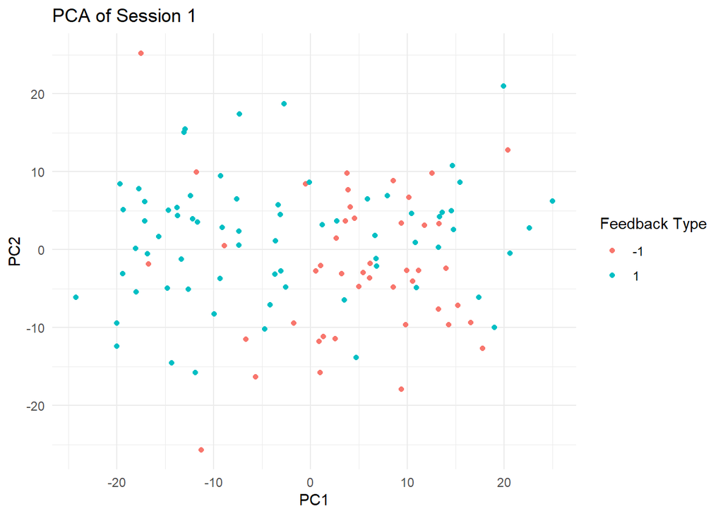

```r
# Visualizing the first two principal components
pca_df <- data.frame(PC1 = pca_result$x[,1], PC2 = pca_result$x[,2], feedback_type = processed_data$feedback_type)
ggplot(pca_df, aes(x = PC1, y = PC2, color = as.factor(feedback_type))) +
  geom_point() +
  labs(title = "PCA of Session 1", x = "PC1", y = "PC2", color = "Feedback Type") +
  theme_minimal()
```

```r
# Determine the number of PCs to explain at least 90% variance
cum_variance <- cumsum(pca_result$sdev^2) / sum(pca_result$sdev^2)
num_pcs <- which(cum_variance >= 0.90)[1]
cat("Number of PCs needed to explain 90% variance:", num_pcs, "\n")
```

```
## Number of PCs needed to explain 90% variance: 92
```

```r
# Extract the selected principal components
selected_pcs <- as.data.frame(pca_result$x[, 1:num_pcs])

# Combine the outcome variable with the selected PCs
pca_final_data <- cbind(feedback_type = processed_data$feedback_type, selected_pcs)

# Save the final PCA dataset
write.csv(pca_final_data, "pca_final_data_session1.csv", row.names = FALSE)

# Print dimensions of the new PCA dataset
print(dim(pca_final_data))
```

```
## [1] 114  93
```

```r
###########################################session2
# Load required libraries
library(ggplot2)

# Load the RDS file for session 2
data <- readRDS("C:/Users/ricky/Desktop/STA141AProject/data/session2.rds")

# Identify unique brain areas in session 2
unique_brain_areas <- unique(data$brain_area)
print(unique_brain_areas)
```

```
## [1] "CA1"   "VISl"  "root"  "VISpm" "POST"
```

```r
# Function to process session 2 with only its brain areas
process_session <- function(data, window_width = 0.1) {

  # Check if session contains relevant brain areas
  valid_neurons <- which(data$brain_area %in% unique_brain_areas)
  if (length(valid_neurons) == 0) return(NULL)  # Skip if no relevant neurons

  # Extract relevant spike data for valid neurons
  filtered_spikes <- lapply(data$spks, function(trial) trial[valid_neurons, ])

  # Function to compute time-resolved firing rates for one trial
  compute_firing_rates_time_resolved <- function(spike_matrix, time_vector, window_width = 0.1) {
    start_time <- min(time_vector)
    end_time <- max(time_vector)
    bins <- seq(start_time, end_time, by = window_width)
    if (tail(bins, 1) < end_time) {
      bins <- c(bins, end_time)
    }
    firing_rates_windows <- sapply(1:(length(bins) - 1), function(i) {
      window_start <- bins[i]
      window_end <- bins[i+1]
      indices <- which(time_vector >= window_start & time_vector < window_end)
      if (length(indices) == 0) {
        return(rep(0, nrow(spike_matrix)))
      } else {
        return(rowSums(spike_matrix[, indices, drop = FALSE]) / (window_end - window_start))
      }
    })
    return(firing_rates_windows)
  }

  # Apply time-resolved firing rate computation to each trial
  time_resolved_rates <- lapply(1:length(filtered_spikes), function(i) {
    compute_firing_rates_time_resolved(filtered_spikes[[i]], data$time[[i]], window_width)
  })

  # Flatten each trial's matrix (neurons x windows) into a single feature vector
  flattened_rates <- lapply(time_resolved_rates, function(mat) {
    as.vector(mat)
  })

  # Create a data frame for all trials from this session
  trial_df <- do.call(rbind, flattened_rates)

  # Extract feedback_type and ensure it's numeric
  if (!"feedback_type" %in% names(data)) return(NULL)
  feedback <- as.numeric(as.character(data$feedback_type))
  df <- data.frame(feedback_type = feedback)

  # Convert trial data to a data frame and assign column names (e.g., "N1_W1", "N1_W2", ...)
  trial_df <- as.data.frame(trial_df)
  num_neurons <- length(valid_neurons)
  num_windows <- ncol(time_resolved_rates[[1]])  # Assumes all trials have same number of windows
  colnames(trial_df) <- paste0("N", rep(1:num_neurons, each = num_windows),
                               "_W", rep(1:num_windows, times = num_neurons))

  # Merge feedback_type with the time-resolved features
  df <- cbind(df, trial_df)
  return(df)
}

# Process only session 2
processed_data <- process_session(data)

# Remove constant (zero-variance) columns before PCA
remove_constant_columns <- function(df) {
  non_constant_cols <- sapply(df, function(col) length(unique(col)) > 1)
  return(df[, non_constant_cols])
}

processed_data <- remove_constant_columns(processed_data)

# Perform PCA on the dataset (excluding the feedback_type column)
pca_data <- processed_data[, -1]  # Exclude feedback_type
pca_result <- prcomp(pca_data, scale. = TRUE)

# Display PCA summary
summary(pca_result)
```

```
## Importance of components:
##                             PC1     PC2     PC3     PC4     PC5     PC6     PC7
## Standard deviation     10.88936 8.11408 6.80873 6.62542 6.52045 6.35175 6.06657
## Proportion of Variance  0.02865 0.01591 0.01120 0.01061 0.01027 0.00975 0.00889
## Cumulative Proportion   0.02865 0.04456 0.05576 0.06636 0.07663 0.08638 0.09527
##                            PC8     PC9    PC10   PC11    PC12    PC13    PC14
## Standard deviation     5.99628 5.79305 5.67767 5.6075 5.44758 5.40994 5.33562
## Proportion of Variance 0.00869 0.00811 0.00779 0.0076 0.00717 0.00707 0.00688
## Cumulative Proportion  0.10396 0.11207 0.11986 0.1275 0.13462 0.14169 0.14857
##                           PC15    PC16    PC17    PC18    PC19    PC20    PC21
## Standard deviation     5.31801 5.23971 5.20957 5.18940 5.15988 5.10074 5.09064
## Proportion of Variance 0.00683 0.00663 0.00656 0.00651 0.00643 0.00629 0.00626
## Cumulative Proportion  0.15541 0.16204 0.16860 0.17510 0.18153 0.18782 0.19408
##                           PC22   PC23    PC24    PC25    PC26   PC27    PC28
## Standard deviation     5.03216 5.0252 5.00439 4.97891 4.91510 4.8992 4.89239
## Proportion of Variance 0.00612 0.0061 0.00605 0.00599 0.00584 0.0058 0.00578
## Cumulative Proportion  0.20020 0.2063 0.21235 0.21834 0.22418 0.2300 0.23576
##                           PC29    PC30    PC31    PC32    PC33    PC34    PC35
## Standard deviation     4.86914 4.84835 4.83197 4.80493 4.80012 4.77886 4.74632
## Proportion of Variance 0.00573 0.00568 0.00564 0.00558 0.00557 0.00552 0.00544
## Cumulative Proportion  0.24149 0.24717 0.25281 0.25839 0.26395 0.26947 0.27491
##                           PC36    PC37    PC38    PC39    PC40    PC41    PC42
## Standard deviation     4.72384 4.71083 4.70367 4.69616 4.68059 4.64884 4.63596
## Proportion of Variance 0.00539 0.00536 0.00535 0.00533 0.00529 0.00522 0.00519
## Cumulative Proportion  0.28030 0.28567 0.29101 0.29634 0.30163 0.30685 0.31205
##                           PC43    PC44    PC45    PC46    PC47    PC48   PC49
## Standard deviation     4.62227 4.61226 4.59776 4.58889 4.56947 4.56178 4.5473
## Proportion of Variance 0.00516 0.00514 0.00511 0.00509 0.00504 0.00503 0.0050
## Cumulative Proportion  0.31721 0.32235 0.32746 0.33254 0.33759 0.34262 0.3476
##                           PC50    PC51   PC52    PC53    PC54    PC55    PC56
## Standard deviation     4.52739 4.51072 4.5048 4.49551 4.46512 4.45990 4.43323
## Proportion of Variance 0.00495 0.00492 0.0049 0.00488 0.00482 0.00481 0.00475
## Cumulative Proportion  0.35256 0.35748 0.3624 0.36727 0.37208 0.37689 0.38164
##                           PC57    PC58    PC59    PC60    PC61    PC62    PC63
## Standard deviation     4.42444 4.41359 4.40762 4.39775 4.39209 4.37962 4.37023
## Proportion of Variance 0.00473 0.00471 0.00469 0.00467 0.00466 0.00463 0.00461
## Cumulative Proportion  0.38637 0.39107 0.39577 0.40044 0.40510 0.40973 0.41435
##                          PC64    PC65    PC66    PC67   PC68    PC69    PC70
## Standard deviation     4.3641 4.35362 4.33688 4.32405 4.3168 4.30721 4.30658
## Proportion of Variance 0.0046 0.00458 0.00454 0.00452 0.0045 0.00448 0.00448
```

[output cut: 90 more lines]

```
## Standard deviation     3.04729 3.03622 3.02431 3.0195 3.01390 2.98761 2.98088
## Proportion of Variance 0.00224 0.00223 0.00221 0.0022 0.00219 0.00216 0.00215
## Cumulative Proportion  0.94925 0.95148 0.95369 0.9559 0.95809 0.96024 0.96239
##                          PC232   PC233  PC234   PC235   PC236   PC237   PC238
## Standard deviation     2.97623 2.96194 2.9482 2.94281 2.92538 2.91865 2.89885
## Proportion of Variance 0.00214 0.00212 0.0021 0.00209 0.00207 0.00206 0.00203
## Cumulative Proportion  0.96453 0.96665 0.9688 0.97084 0.97291 0.97497 0.97700
##                          PC239   PC240 PC241   PC242   PC243   PC244   PC245
## Standard deviation     2.88863 2.88346 2.878 2.86725 2.84279 2.83326 2.82076
## Proportion of Variance 0.00202 0.00201 0.002 0.00199 0.00195 0.00194 0.00192
## Cumulative Proportion  0.97901 0.98102 0.983 0.98501 0.98696 0.98890 0.99083
##                         PC246   PC247   PC248   PC249   PC250     PC251
## Standard deviation     2.8052 2.78000 2.76395 2.71927 2.70971 2.796e-14
## Proportion of Variance 0.0019 0.00187 0.00185 0.00179 0.00177 0.000e+00
## Cumulative Proportion  0.9927 0.99459 0.99644 0.99823 1.00000 1.000e+00
```

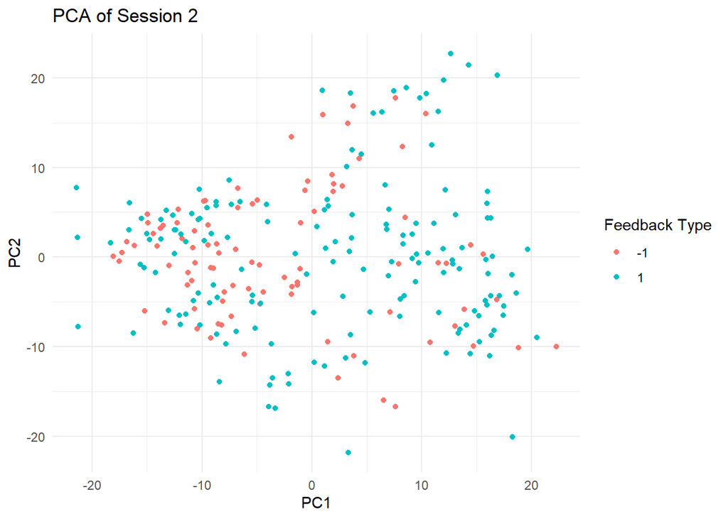

```r
# Visualizing the first two principal components
pca_df <- data.frame(PC1 = pca_result$x[,1], PC2 = pca_result$x[,2], feedback_type = processed_data$feedback_type)
ggplot(pca_df, aes(x = PC1, y = PC2, color = as.factor(feedback_type))) +
  geom_point() +
  labs(title = "PCA of Session 2", x = "PC1", y = "PC2", color = "Feedback Type") +
  theme_minimal()
```

```r
# Determine the number of PCs to explain at least 90% variance
cum_variance <- cumsum(pca_result$sdev^2) / sum(pca_result$sdev^2)
num_pcs <- which(cum_variance >= 0.90)[1]
cat("Number of PCs needed to explain 90% variance:", num_pcs, "\n")
```

```
## Number of PCs needed to explain 90% variance: 205
```

```r
# Extract the selected principal components
selected_pcs <- as.data.frame(pca_result$x[, 1:num_pcs])

# Combine the outcome variable with the selected PCs
pca_final_data <- cbind(feedback_type = processed_data$feedback_type, selected_pcs)

# Save the final PCA dataset
write.csv(pca_final_data, "pca_final_data_session2.csv", row.names = FALSE)

# Print dimensions of the new PCA dataset
print(dim(pca_final_data))
```

```
## [1] 251 206
```

```r
#####################################session 3
# Load required libraries
library(ggplot2)

# Load the RDS file for session 3
data <- readRDS("C:/Users/ricky/Desktop/STA141AProject/data/session3.rds")

# Identify unique brain areas in session 2
unique_brain_areas <- unique(data$brain_area)
print(unique_brain_areas)
```

```
##  [1] "DG"    "VISam" "MG"    "CA1"   "SPF"   "root"  "LP"    "MRN"   "POST"
## [10] "NB"    "VISp"
```

```r
# Function to process session 2 with only its brain areas
process_session <- function(data, window_width = 0.1) {

  # Check if session contains relevant brain areas
  valid_neurons <- which(data$brain_area %in% unique_brain_areas)
  if (length(valid_neurons) == 0) return(NULL)  # Skip if no relevant neurons

  # Extract relevant spike data for valid neurons
  filtered_spikes <- lapply(data$spks, function(trial) trial[valid_neurons, ])

  # Function to compute time-resolved firing rates for one trial
  compute_firing_rates_time_resolved <- function(spike_matrix, time_vector, window_width = 0.1) {
    start_time <- min(time_vector)
    end_time <- max(time_vector)
    bins <- seq(start_time, end_time, by = window_width)
    if (tail(bins, 1) < end_time) {
      bins <- c(bins, end_time)
    }
    firing_rates_windows <- sapply(1:(length(bins) - 1), function(i) {
      window_start <- bins[i]
      window_end <- bins[i+1]
      indices <- which(time_vector >= window_start & time_vector < window_end)
      if (length(indices) == 0) {
        return(rep(0, nrow(spike_matrix)))
      } else {
        return(rowSums(spike_matrix[, indices, drop = FALSE]) / (window_end - window_start))
      }
    })
    return(firing_rates_windows)
  }

  # Apply time-resolved firing rate computation to each trial
  time_resolved_rates <- lapply(1:length(filtered_spikes), function(i) {
    compute_firing_rates_time_resolved(filtered_spikes[[i]], data$time[[i]], window_width)
  })

  # Flatten each trial's matrix (neurons x windows) into a single feature vector
  flattened_rates <- lapply(time_resolved_rates, function(mat) {
    as.vector(mat)
  })

  # Create a data frame for all trials from this session
  trial_df <- do.call(rbind, flattened_rates)

  # Extract feedback_type and ensure it's numeric
  if (!"feedback_type" %in% names(data)) return(NULL)
  feedback <- as.numeric(as.character(data$feedback_type))
  df <- data.frame(feedback_type = feedback)

  # Convert trial data to a data frame and assign column names (e.g., "N1_W1", "N1_W2", ...)
  trial_df <- as.data.frame(trial_df)
  num_neurons <- length(valid_neurons)
  num_windows <- ncol(time_resolved_rates[[1]])  # Assumes all trials have same number of windows
  colnames(trial_df) <- paste0("N", rep(1:num_neurons, each = num_windows),
                               "_W", rep(1:num_windows, times = num_neurons))

  # Merge feedback_type with the time-resolved features
  df <- cbind(df, trial_df)
  return(df)
}

# Process only session 2
processed_data <- process_session(data)

# Remove constant (zero-variance) columns before PCA
remove_constant_columns <- function(df) {
  non_constant_cols <- sapply(df, function(col) length(unique(col)) > 1)
  return(df[, non_constant_cols])
}

processed_data <- remove_constant_columns(processed_data)

# Perform PCA on the dataset (excluding the feedback_type column)
pca_data <- processed_data[, -1]  # Exclude feedback_type
pca_result <- prcomp(pca_data, scale. = TRUE)

# Display PCA summary
summary(pca_result)
```

```
## Importance of components:
##                            PC1     PC2     PC3     PC4     PC5     PC6     PC7
## Standard deviation     8.58984 6.22823 5.72587 5.35711 4.87532 4.82318 4.61327
## Proportion of Variance 0.03324 0.01747 0.01477 0.01293 0.01071 0.01048 0.00959
## Cumulative Proportion  0.03324 0.05071 0.06548 0.07841 0.08911 0.09959 0.10918
##                            PC8     PC9    PC10    PC11    PC12    PC13    PC14
## Standard deviation     4.49179 4.48893 4.35404 4.30112 4.27528 4.23552 4.17254
## Proportion of Variance 0.00909 0.00908 0.00854 0.00833 0.00823 0.00808 0.00784
## Cumulative Proportion  0.11827 0.12734 0.13588 0.14422 0.15245 0.16053 0.16837
##                           PC15    PC16    PC17    PC18    PC19    PC20    PC21
## Standard deviation     4.12404 4.09385 4.06882 4.04200 4.02266 4.00203 3.95552
## Proportion of Variance 0.00766 0.00755 0.00746 0.00736 0.00729 0.00721 0.00705
## Cumulative Proportion  0.17603 0.18358 0.19104 0.19840 0.20569 0.21290 0.21995
##                           PC22    PC23    PC24    PC25    PC26    PC27    PC28
## Standard deviation     3.93145 3.90653 3.88820 3.87144 3.84868 3.83341 3.81873
## Proportion of Variance 0.00696 0.00687 0.00681 0.00675 0.00667 0.00662 0.00657
## Cumulative Proportion  0.22691 0.23379 0.24060 0.24735 0.25402 0.26064 0.26721
##                           PC29    PC30    PC31    PC32    PC33    PC34    PC35
## Standard deviation     3.80083 3.77492 3.75806 3.74801 3.72961 3.70632 3.70190
## Proportion of Variance 0.00651 0.00642 0.00636 0.00633 0.00627 0.00619 0.00617
## Cumulative Proportion  0.27372 0.28014 0.28650 0.29282 0.29909 0.30528 0.31145
##                           PC36    PC37    PC38    PC39    PC40    PC41    PC42
## Standard deviation     3.68992 3.67468 3.65464 3.64365 3.63057 3.62307 3.60532
## Proportion of Variance 0.00613 0.00608 0.00602 0.00598 0.00594 0.00591 0.00586
## Cumulative Proportion  0.31758 0.32367 0.32968 0.33566 0.34160 0.34751 0.35337
##                           PC43    PC44    PC45    PC46    PC47    PC48    PC49
## Standard deviation     3.57935 3.57206 3.56953 3.55973 3.54825 3.52772 3.52095
## Proportion of Variance 0.00577 0.00575 0.00574 0.00571 0.00567 0.00561 0.00558
## Cumulative Proportion  0.35914 0.36489 0.37063 0.37634 0.38201 0.38761 0.39320
##                           PC50    PC51    PC52    PC53   PC54    PC55    PC56
## Standard deviation     3.50859 3.48910 3.48264 3.47489 3.4613 3.44501 3.43312
## Proportion of Variance 0.00555 0.00548 0.00546 0.00544 0.0054 0.00535 0.00531
## Cumulative Proportion  0.39874 0.40423 0.40969 0.41513 0.4205 0.42587 0.43118
##                           PC57    PC58    PC59   PC60    PC61    PC62    PC63
## Standard deviation     3.42307 3.41608 3.40131 3.3992 3.38236 3.37092 3.36270
## Proportion of Variance 0.00528 0.00526 0.00521 0.0052 0.00515 0.00512 0.00509
## Cumulative Proportion  0.43646 0.44171 0.44693 0.4521 0.45728 0.46240 0.46750
##                           PC64    PC65    PC66    PC67    PC68    PC69   PC70
## Standard deviation     3.35366 3.33881 3.32630 3.31558 3.31210 3.30214 3.2966
## Proportion of Variance 0.00507 0.00502 0.00498 0.00495 0.00494 0.00491 0.0049
```

[output cut: 78 more lines]

```
## Standard deviation     2.18050 2.17212 2.16392 2.14873 2.14378 2.13143 2.12604
## Proportion of Variance 0.00214 0.00213 0.00211 0.00208 0.00207 0.00205 0.00204
## Cumulative Proportion  0.95652 0.95865 0.96076 0.96284 0.96491 0.96695 0.96899
##                        PC211   PC212   PC213   PC214   PC215   PC216   PC217
## Standard deviation     2.108 2.09262 2.08803 2.08099 2.06593 2.04537 2.04278
## Proportion of Variance 0.002 0.00197 0.00196 0.00195 0.00192 0.00188 0.00188
## Cumulative Proportion  0.971 0.97297 0.97493 0.97688 0.97880 0.98069 0.98257
##                          PC218   PC219   PC220  PC221   PC222   PC223   PC224
## Standard deviation     2.02793 2.01537 2.00427 1.9979 1.98230 1.95962 1.95317
## Proportion of Variance 0.00185 0.00183 0.00181 0.0018 0.00177 0.00173 0.00172
## Cumulative Proportion  0.98442 0.98625 0.98806 0.9899 0.99163 0.99336 0.99507
##                          PC225   PC226   PC227     PC228
## Standard deviation     1.93907 1.90758 1.88030 1.194e-14
## Proportion of Variance 0.00169 0.00164 0.00159 0.000e+00
## Cumulative Proportion  0.99677 0.99841 1.00000 1.000e+00
```

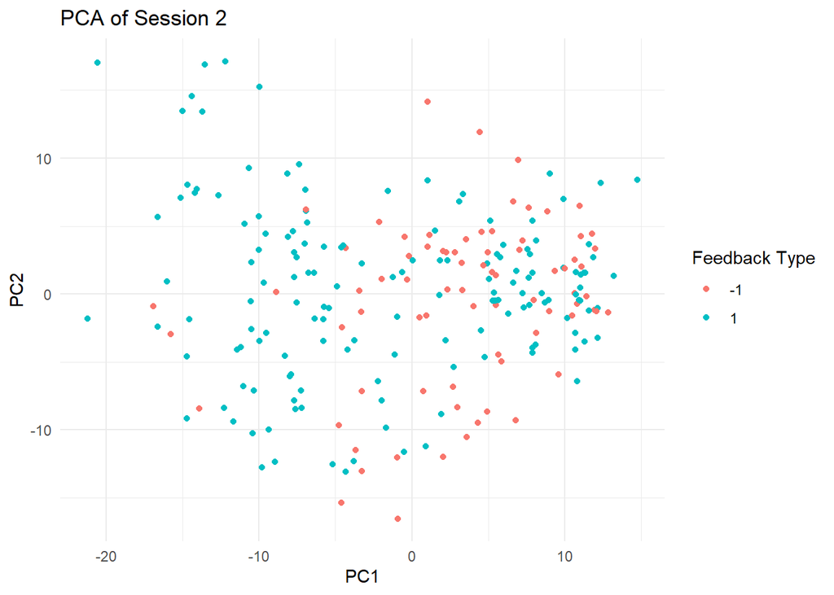

```r
# Visualizing the first two principal components
pca_df <- data.frame(PC1 = pca_result$x[,1], PC2 = pca_result$x[,2], feedback_type = processed_data$feedback_type)
ggplot(pca_df, aes(x = PC1, y = PC2, color = as.factor(feedback_type))) +
  geom_point() +
  labs(title = "PCA of Session 2", x = "PC1", y = "PC2", color = "Feedback Type") +
  theme_minimal()
```

```r
# Determine the number of PCs to explain at least 90% variance
cum_variance <- cumsum(pca_result$sdev^2) / sum(pca_result$sdev^2)
num_pcs <- which(cum_variance >= 0.90)[1]
cat("Number of PCs needed to explain 90% variance:", num_pcs, "\n")
```

```
## Number of PCs needed to explain 90% variance: 180
```

```r
# Extract the selected principal components
selected_pcs <- as.data.frame(pca_result$x[, 1:num_pcs])

# Combine the outcome variable with the selected PCs
pca_final_data <- cbind(feedback_type = processed_data$feedback_type, selected_pcs)

# Save the final PCA dataset
write.csv(pca_final_data, "pca_final_data_session3.csv", row.names = FALSE)

# Print dimensions of the new PCA dataset
print(dim(pca_final_data))
```

```
## [1] 228 181
```

```r
############################################session 4
# Load required libraries
library(ggplot2)

# Load the RDS file for session 4
data <- readRDS("C:/Users/ricky/Desktop/STA141AProject/data/session4.rds")

# Identify unique brain areas in session 4
unique_brain_areas <- unique(data$brain_area)
print(unique_brain_areas)
```

```
##  [1] "LGd"  "DG"   "TH"   "SUB"  "VPL"  "VISp" "CA1"  "VISa" "LSr"  "ACA"
## [11] "MOs"
```

```r
# Function to process session 4 with only its brain areas
process_session <- function(data, window_width = 0.1) {

  # Check if session contains relevant brain areas
  valid_neurons <- which(data$brain_area %in% unique_brain_areas)
  if (length(valid_neurons) == 0) return(NULL)  # Skip if no relevant neurons

  # Extract relevant spike data for valid neurons
  filtered_spikes <- lapply(data$spks, function(trial) trial[valid_neurons, ])

  # Function to compute time-resolved firing rates for one trial
  compute_firing_rates_time_resolved <- function(spike_matrix, time_vector, window_width = 0.1) {
    start_time <- min(time_vector)
    end_time <- max(time_vector)
    bins <- seq(start_time, end_time, by = window_width)
    if (tail(bins, 1) < end_time) {
      bins <- c(bins, end_time)
    }
    firing_rates_windows <- sapply(1:(length(bins) - 1), function(i) {
      window_start <- bins[i]
      window_end <- bins[i+1]
      indices <- which(time_vector >= window_start & time_vector < window_end)
      if (length(indices) == 0) {
        return(rep(0, nrow(spike_matrix)))
      } else {
        return(rowSums(spike_matrix[, indices, drop = FALSE]) / (window_end - window_start))
      }
    })
    return(firing_rates_windows)
  }

  # Apply time-resolved firing rate computation to each trial
  time_resolved_rates <- lapply(1:length(filtered_spikes), function(i) {
    compute_firing_rates_time_resolved(filtered_spikes[[i]], data$time[[i]], window_width)
  })

  # Flatten each trial's matrix (neurons x windows) into a single feature vector
  flattened_rates <- lapply(time_resolved_rates, function(mat) {
    as.vector(mat)
  })

  # Create a data frame for all trials from this session
  trial_df <- do.call(rbind, flattened_rates)

  # Extract feedback_type and ensure it's numeric
  if (!"feedback_type" %in% names(data)) return(NULL)
  feedback <- as.numeric(as.character(data$feedback_type))
  df <- data.frame(feedback_type = feedback)

  # Convert trial data to a data frame and assign column names (e.g., "N1_W1", "N1_W2", ...)
  trial_df <- as.data.frame(trial_df)
  num_neurons <- length(valid_neurons)
  num_windows <- ncol(time_resolved_rates[[1]])  # Assumes all trials have same number of windows
  colnames(trial_df) <- paste0("N", rep(1:num_neurons, each = num_windows),
                               "_W", rep(1:num_windows, times = num_neurons))

  # Merge feedback_type with the time-resolved features
  df <- cbind(df, trial_df)
  return(df)
}

# Process only session 2
processed_data <- process_session(data)

# Remove constant (zero-variance) columns before PCA
remove_constant_columns <- function(df) {
  non_constant_cols <- sapply(df, function(col) length(unique(col)) > 1)
  return(df[, non_constant_cols])
}

processed_data <- remove_constant_columns(processed_data)

# Perform PCA on the dataset (excluding the feedback_type column)
pca_data <- processed_data[, -1]  # Exclude feedback_type
pca_result <- prcomp(pca_data, scale. = TRUE)

# Display PCA summary
summary(pca_result)
```

```
## Importance of components:
##                             PC1      PC2     PC3     PC4     PC5     PC6
## Standard deviation     13.17220 12.85495 9.99287 9.12737 8.66023 8.25188
## Proportion of Variance  0.02633  0.02508 0.01516 0.01264 0.01138 0.01033
## Cumulative Proportion   0.02633  0.05141 0.06657 0.07921 0.09059 0.10093
##                            PC7    PC8     PC9    PC10    PC11    PC12    PC13
## Standard deviation     8.10973 7.8684 7.69535 7.56514 7.38581 7.22836 7.19019
## Proportion of Variance 0.00998 0.0094 0.00899 0.00869 0.00828 0.00793 0.00785
## Cumulative Proportion  0.11091 0.1203 0.12929 0.13798 0.14626 0.15419 0.16203
##                          PC14    PC15    PC16    PC17   PC18    PC19   PC20
## Standard deviation     7.0748 6.92439 6.88251 6.75570 6.6463 6.57752 6.4940
## Proportion of Variance 0.0076 0.00728 0.00719 0.00693 0.0067 0.00657 0.0064
## Cumulative Proportion  0.1696 0.17691 0.18410 0.19102 0.1977 0.20429 0.2107
##                           PC21    PC22    PC23    PC24    PC25    PC26   PC27
## Standard deviation     6.47106 6.35680 6.33645 6.24568 6.21090 6.17873 6.1287
## Proportion of Variance 0.00636 0.00613 0.00609 0.00592 0.00585 0.00579 0.0057
## Cumulative Proportion  0.21705 0.22318 0.22928 0.23520 0.24105 0.24684 0.2525
##                           PC28    PC29    PC30   PC31    PC32    PC33    PC34
## Standard deviation     6.07148 6.06467 6.03957 6.0188 5.99714 5.98422 5.92394
## Proportion of Variance 0.00559 0.00558 0.00554 0.0055 0.00546 0.00543 0.00533
## Cumulative Proportion  0.25814 0.26372 0.26926 0.2748 0.28021 0.28565 0.29097
##                          PC35    PC36    PC37    PC38   PC39    PC40    PC41
## Standard deviation     5.9091 5.87432 5.85627 5.81493 5.7964 5.77481 5.75731
## Proportion of Variance 0.0053 0.00524 0.00521 0.00513 0.0051 0.00506 0.00503
## Cumulative Proportion  0.2963 0.30151 0.30672 0.31185 0.3170 0.32201 0.32704
##                           PC42    PC43    PC44    PC45    PC46    PC47    PC48
## Standard deviation     5.74546 5.73116 5.71490 5.71086 5.70042 5.67618 5.65188
## Proportion of Variance 0.00501 0.00499 0.00496 0.00495 0.00493 0.00489 0.00485
## Cumulative Proportion  0.33205 0.33703 0.34199 0.34694 0.35187 0.35676 0.36161
##                           PC49    PC50    PC51    PC52    PC53    PC54    PC55
## Standard deviation     5.64367 5.63109 5.60508 5.58722 5.56960 5.55595 5.53598
## Proportion of Variance 0.00483 0.00481 0.00477 0.00474 0.00471 0.00468 0.00465
## Cumulative Proportion  0.36644 0.37126 0.37602 0.38076 0.38547 0.39015 0.39481
##                           PC56    PC57    PC58    PC59    PC60    PC61    PC62
## Standard deviation     5.53023 5.51201 5.50935 5.47279 5.46465 5.43705 5.42168
## Proportion of Variance 0.00464 0.00461 0.00461 0.00455 0.00453 0.00449 0.00446
## Cumulative Proportion  0.39945 0.40406 0.40867 0.41321 0.41774 0.42223 0.42669
##                           PC63    PC64   PC65    PC66    PC67    PC68    PC69
## Standard deviation     5.40611 5.40217 5.3832 5.37824 5.35994 5.34936 5.34203
## Proportion of Variance 0.00444 0.00443 0.0044 0.00439 0.00436 0.00434 0.00433
```

[output cut: 90 more lines]

```
## Standard deviation     3.82348 3.81246 3.8070 3.79748 3.78464 3.76663 3.75748
## Proportion of Variance 0.00222 0.00221 0.0022 0.00219 0.00217 0.00215 0.00214
## Cumulative Proportion  0.95166 0.95387 0.9561 0.95826 0.96043 0.96258 0.96473
##                          PC231  PC232   PC233   PC234   PC235   PC236  PC237
## Standard deviation     3.73918 3.7210 3.71321 3.70410 3.69864 3.66487 3.6330
## Proportion of Variance 0.00212 0.0021 0.00209 0.00208 0.00208 0.00204 0.0020
## Cumulative Proportion  0.96685 0.9689 0.97104 0.97312 0.97520 0.97724 0.9792
##                          PC238   PC239   PC240   PC241   PC242  PC243   PC244
## Standard deviation     3.62525 3.61713 3.58967 3.55382 3.54560 3.5379 3.50551
## Proportion of Variance 0.00199 0.00199 0.00196 0.00192 0.00191 0.0019 0.00187
## Cumulative Proportion  0.98124 0.98322 0.98518 0.98709 0.98900 0.9909 0.99277
##                          PC245   PC246   PC247   PC248     PC249
## Standard deviation     3.49792 3.46427 3.42811 3.41612 4.801e-14
## Proportion of Variance 0.00186 0.00182 0.00178 0.00177 0.000e+00
## Cumulative Proportion  0.99462 0.99645 0.99823 1.00000 1.000e+00
```

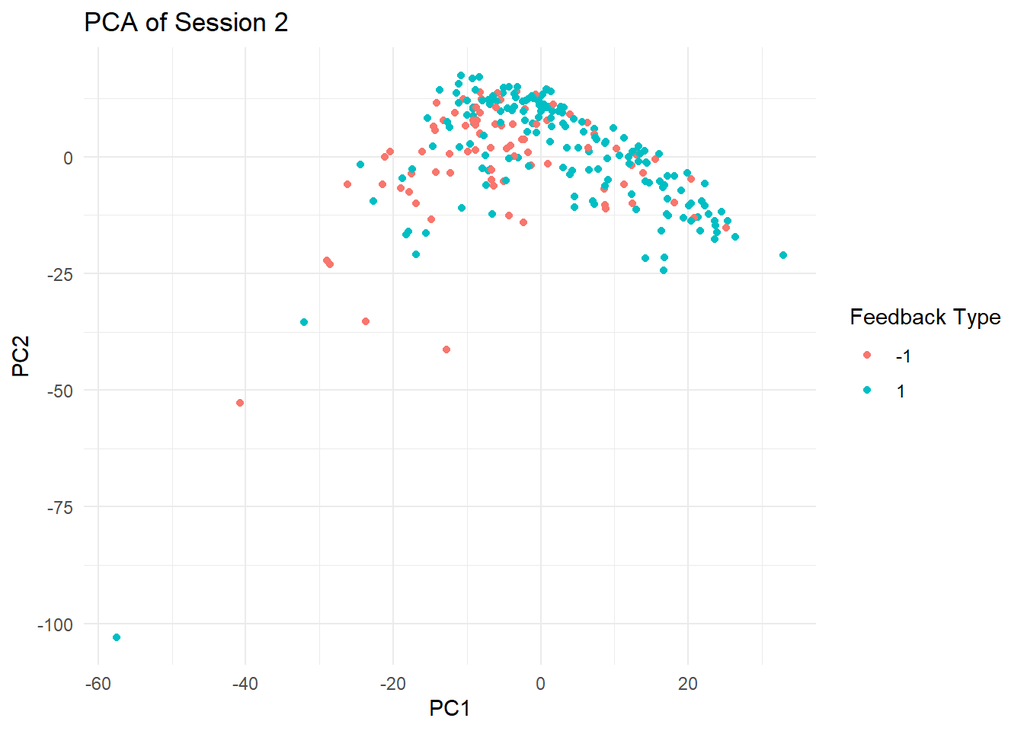

```r
# Visualizing the first two principal components
pca_df <- data.frame(PC1 = pca_result$x[,1], PC2 = pca_result$x[,2], feedback_type = processed_data$feedback_type)
ggplot(pca_df, aes(x = PC1, y = PC2, color = as.factor(feedback_type))) +
  geom_point() +
  labs(title = "PCA of Session 2", x = "PC1", y = "PC2", color = "Feedback Type") +
  theme_minimal()
```

```r
# Determine the number of PCs to explain at least 90% variance
cum_variance <- cumsum(pca_result$sdev^2) / sum(pca_result$sdev^2)
num_pcs <- which(cum_variance >= 0.90)[1]
cat("Number of PCs needed to explain 90% variance:", num_pcs, "\n")
```

```
## Number of PCs needed to explain 90% variance: 203
```

```r
# Extract the selected principal components
selected_pcs <- as.data.frame(pca_result$x[, 1:num_pcs])

# Combine the outcome variable with the selected PCs
pca_final_data <- cbind(feedback_type = processed_data$feedback_type, selected_pcs)

# Save the final PCA dataset
write.csv(pca_final_data, "pca_final_data_session4.csv", row.names = FALSE)

# Print dimensions of the new PCA dataset
print(dim(pca_final_data))
```

```
## [1] 249 204
```

```r
##################################################session 5
# Load required libraries
library(ggplot2)

# Load the RDS file for session 5
data <- readRDS("C:/Users/ricky/Desktop/STA141AProject/data/session5.rds")

# Identify unique brain areas in session 5
unique_brain_areas <- unique(data$brain_area)
print(unique_brain_areas)
```

```
##  [1] "VISa" "root" "CA1"  "SUB"  "DG"   "OLF"  "ORB"  "ACA"  "PL"   "MOs"
```

```r
# Function to process session 5 with only its brain areas
process_session <- function(data, window_width = 0.1) {

  # Check if session contains relevant brain areas
  valid_neurons <- which(data$brain_area %in% unique_brain_areas)
  if (length(valid_neurons) == 0) return(NULL)  # Skip if no relevant neurons

  # Extract relevant spike data for valid neurons
  filtered_spikes <- lapply(data$spks, function(trial) trial[valid_neurons, ])

  # Function to compute time-resolved firing rates for one trial
  compute_firing_rates_time_resolved <- function(spike_matrix, time_vector, window_width = 0.1) {
    start_time <- min(time_vector)
    end_time <- max(time_vector)
    bins <- seq(start_time, end_time, by = window_width)
    if (tail(bins, 1) < end_time) {
      bins <- c(bins, end_time)
    }
    firing_rates_windows <- sapply(1:(length(bins) - 1), function(i) {
      window_start <- bins[i]
      window_end <- bins[i+1]
      indices <- which(time_vector >= window_start & time_vector < window_end)
      if (length(indices) == 0) {
        return(rep(0, nrow(spike_matrix)))
      } else {
        return(rowSums(spike_matrix[, indices, drop = FALSE]) / (window_end - window_start))
      }
    })
    return(firing_rates_windows)
  }

  # Apply time-resolved firing rate computation to each trial
  time_resolved_rates <- lapply(1:length(filtered_spikes), function(i) {
    compute_firing_rates_time_resolved(filtered_spikes[[i]], data$time[[i]], window_width)
  })

  # Flatten each trial's matrix (neurons x windows) into a single feature vector
  flattened_rates <- lapply(time_resolved_rates, function(mat) {
    as.vector(mat)
  })

  # Create a data frame for all trials from this session
  trial_df <- do.call(rbind, flattened_rates)

  # Extract feedback_type and ensure it's numeric
  if (!"feedback_type" %in% names(data)) return(NULL)
  feedback <- as.numeric(as.character(data$feedback_type))
  df <- data.frame(feedback_type = feedback)

  # Convert trial data to a data frame and assign column names (e.g., "N1_W1", "N1_W2", ...)
  trial_df <- as.data.frame(trial_df)
  num_neurons <- length(valid_neurons)
  num_windows <- ncol(time_resolved_rates[[1]])  # Assumes all trials have same number of windows
  colnames(trial_df) <- paste0("N", rep(1:num_neurons, each = num_windows),
                               "_W", rep(1:num_windows, times = num_neurons))

  # Merge feedback_type with the time-resolved features
  df <- cbind(df, trial_df)
  return(df)
}

# Process only session 2
processed_data <- process_session(data)

# Remove constant (zero-variance) columns before PCA
remove_constant_columns <- function(df) {
  non_constant_cols <- sapply(df, function(col) length(unique(col)) > 1)
  return(df[, non_constant_cols])
}

processed_data <- remove_constant_columns(processed_data)

# Perform PCA on the dataset (excluding the feedback_type column)
pca_data <- processed_data[, -1]  # Exclude feedback_type
pca_result <- prcomp(pca_data, scale. = TRUE)

# Display PCA summary
summary(pca_result)
```

```
## Importance of components:
##                             PC1     PC2     PC3     PC4     PC5     PC6     PC7
## Standard deviation     10.81157 7.79630 7.38772 6.25660 6.02953 5.79306 5.74931
## Proportion of Variance  0.02854 0.01484 0.01333 0.00956 0.00888 0.00820 0.00807
## Cumulative Proportion   0.02854 0.04339 0.05672 0.06627 0.07515 0.08335 0.09142
##                            PC8     PC9    PC10    PC11    PC12    PC13    PC14
## Standard deviation     5.68273 5.60453 5.51286 5.42039 5.37087 5.31831 5.29419
## Proportion of Variance 0.00789 0.00767 0.00742 0.00717 0.00704 0.00691 0.00684
## Cumulative Proportion  0.09931 0.10698 0.11440 0.12157 0.12862 0.13552 0.14237
##                           PC15    PC16    PC17    PC18   PC19   PC20    PC21
## Standard deviation     5.27890 5.21168 5.18987 5.15165 5.1196 5.0798 5.05650
## Proportion of Variance 0.00681 0.00663 0.00658 0.00648 0.0064 0.0063 0.00624
## Cumulative Proportion  0.14917 0.15581 0.16238 0.16887 0.1753 0.1816 0.18781
##                           PC22    PC23    PC24    PC25    PC26    PC27    PC28
## Standard deviation     5.03571 5.02622 4.97383 4.96135 4.95208 4.93686 4.91904
## Proportion of Variance 0.00619 0.00617 0.00604 0.00601 0.00599 0.00595 0.00591
## Cumulative Proportion  0.19400 0.20017 0.20621 0.21223 0.21821 0.22417 0.23007
##                           PC29   PC30    PC31    PC32    PC33    PC34    PC35
## Standard deviation     4.88937 4.8735 4.85079 4.84779 4.81112 4.80574 4.77806
## Proportion of Variance 0.00584 0.0058 0.00575 0.00574 0.00565 0.00564 0.00558
## Cumulative Proportion  0.23591 0.2417 0.24746 0.25320 0.25885 0.26449 0.27006
##                           PC36    PC37   PC38    PC39   PC40   PC41    PC42
## Standard deviation     4.77708 4.76204 4.7456 4.73060 4.7029 4.7007 4.67873
## Proportion of Variance 0.00557 0.00554 0.0055 0.00546 0.0054 0.0054 0.00535
## Cumulative Proportion  0.27564 0.28118 0.2867 0.29214 0.2975 0.3029 0.30828
##                           PC43    PC44    PC45    PC46    PC47   PC48    PC49
## Standard deviation     4.66351 4.65299 4.65238 4.63052 4.62138 4.6144 4.59469
## Proportion of Variance 0.00531 0.00529 0.00529 0.00524 0.00522 0.0052 0.00516
## Cumulative Proportion  0.31359 0.31888 0.32417 0.32940 0.33462 0.3398 0.34497
##                           PC50    PC51    PC52    PC53   PC54    PC55    PC56
## Standard deviation     4.58279 4.57742 4.56072 4.53900 4.5267 4.51082 4.49644
## Proportion of Variance 0.00513 0.00512 0.00508 0.00503 0.0050 0.00497 0.00494
## Cumulative Proportion  0.35010 0.35522 0.36030 0.36533 0.3703 0.37530 0.38024
##                           PC57   PC58    PC59    PC60    PC61   PC62    PC63
## Standard deviation     4.49150 4.4778 4.46782 4.45630 4.44057 4.4348 4.41594
## Proportion of Variance 0.00493 0.0049 0.00487 0.00485 0.00482 0.0048 0.00476
## Cumulative Proportion  0.38516 0.3901 0.39494 0.39978 0.40460 0.4094 0.41416
##                           PC64   PC65   PC66    PC67    PC68    PC69   PC70
## Standard deviation     4.39863 4.3878 4.3850 4.36959 4.36712 4.35423 4.3423
## Proportion of Variance 0.00472 0.0047 0.0047 0.00466 0.00466 0.00463 0.0046
```

[output cut: 94 more lines]

```
## Standard deviation     2.84816 2.83695 2.82893 2.82304 2.81275 2.7922 2.7868
## Proportion of Variance 0.00198 0.00197 0.00195 0.00195 0.00193 0.0019 0.0019
## Cumulative Proportion  0.96320 0.96517 0.96712 0.96907 0.97100 0.9729 0.9748
##                          PC239   PC240   PC241   PC242   PC243   PC244   PC245
## Standard deviation     2.77272 2.75295 2.74495 2.73629 2.69369 2.67619 2.67567
## Proportion of Variance 0.00188 0.00185 0.00184 0.00183 0.00177 0.00175 0.00175
## Cumulative Proportion  0.97668 0.97853 0.98037 0.98220 0.98397 0.98572 0.98747
##                          PC246   PC247   PC248   PC249   PC250   PC251   PC252
## Standard deviation     2.65949 2.62470 2.61218 2.55184 2.54225 2.53102 2.44342
## Proportion of Variance 0.00173 0.00168 0.00167 0.00159 0.00158 0.00156 0.00146
## Cumulative Proportion  0.98919 0.99088 0.99254 0.99413 0.99571 0.99728 0.99873
##                          PC253     PC254
## Standard deviation     2.27711 2.675e-14
## Proportion of Variance 0.00127 0.000e+00
## Cumulative Proportion  1.00000 1.000e+00
```

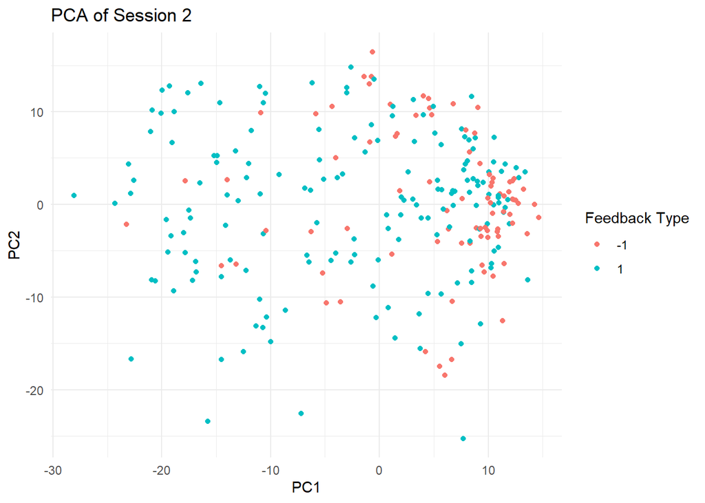

```r
# Visualizing the first two principal components
pca_df <- data.frame(PC1 = pca_result$x[,1], PC2 = pca_result$x[,2], feedback_type = processed_data$feedback_type)
ggplot(pca_df, aes(x = PC1, y = PC2, color = as.factor(feedback_type))) +
  geom_point() +
  labs(title = "PCA of Session 2", x = "PC1", y = "PC2", color = "Feedback Type") +
  theme_minimal()
```

```r
# Determine the number of PCs to explain at least 90% variance
cum_variance <- cumsum(pca_result$sdev^2) / sum(pca_result$sdev^2)
num_pcs <- which(cum_variance >= 0.90)[1]
cat("Number of PCs needed to explain 90% variance:", num_pcs, "\n")
```

```
## Number of PCs needed to explain 90% variance: 204
```

```r
# Extract the selected principal components
selected_pcs <- as.data.frame(pca_result$x[, 1:num_pcs])

# Combine the outcome variable with the selected PCs
pca_final_data <- cbind(feedback_type = processed_data$feedback_type, selected_pcs)

# Save the final PCA dataset
write.csv(pca_final_data, "pca_final_data_session5.csv", row.names = FALSE)

# Print dimensions of the new PCA dataset
print(dim(pca_final_data))
```

```
## [1] 254 205
```

```r
#########################################session 6
# Load required libraries
library(ggplot2)

# Load the RDS file for session 6
data <- readRDS("C:/Users/ricky/Desktop/STA141AProject/data/session6.rds")

# Identify unique brain areas in session 6
unique_brain_areas <- unique(data$brain_area)
print(unique_brain_areas)
```

```
## [1] "AUD"  "root" "SSp"  "CA1"  "TH"
```

```r
# Function to process session 6 with only its brain areas
process_session <- function(data, window_width = 0.1) {

  # Check if session contains relevant brain areas
  valid_neurons <- which(data$brain_area %in% unique_brain_areas)
  if (length(valid_neurons) == 0) return(NULL)  # Skip if no relevant neurons

  # Extract relevant spike data for valid neurons
  filtered_spikes <- lapply(data$spks, function(trial) trial[valid_neurons, ])

  # Function to compute time-resolved firing rates for one trial
  compute_firing_rates_time_resolved <- function(spike_matrix, time_vector, window_width = 0.1) {
    start_time <- min(time_vector)
    end_time <- max(time_vector)
    bins <- seq(start_time, end_time, by = window_width)
    if (tail(bins, 1) < end_time) {
      bins <- c(bins, end_time)
    }
    firing_rates_windows <- sapply(1:(length(bins) - 1), function(i) {
      window_start <- bins[i]
      window_end <- bins[i+1]
      indices <- which(time_vector >= window_start & time_vector < window_end)
      if (length(indices) == 0) {
        return(rep(0, nrow(spike_matrix)))
      } else {
        return(rowSums(spike_matrix[, indices, drop = FALSE]) / (window_end - window_start))
      }
    })
    return(firing_rates_windows)
  }

  # Apply time-resolved firing rate computation to each trial
  time_resolved_rates <- lapply(1:length(filtered_spikes), function(i) {
    compute_firing_rates_time_resolved(filtered_spikes[[i]], data$time[[i]], window_width)
  })

  # Flatten each trial's matrix (neurons x windows) into a single feature vector
  flattened_rates <- lapply(time_resolved_rates, function(mat) {
    as.vector(mat)
  })

  # Create a data frame for all trials from this session
  trial_df <- do.call(rbind, flattened_rates)

  # Extract feedback_type and ensure it's numeric
  if (!"feedback_type" %in% names(data)) return(NULL)
  feedback <- as.numeric(as.character(data$feedback_type))
  df <- data.frame(feedback_type = feedback)

  # Convert trial data to a data frame and assign column names (e.g., "N1_W1", "N1_W2", ...)
  trial_df <- as.data.frame(trial_df)
  num_neurons <- length(valid_neurons)
  num_windows <- ncol(time_resolved_rates[[1]])  # Assumes all trials have same number of windows
  colnames(trial_df) <- paste0("N", rep(1:num_neurons, each = num_windows),
                               "_W", rep(1:num_windows, times = num_neurons))

  # Merge feedback_type with the time-resolved features
  df <- cbind(df, trial_df)
  return(df)
}

# Process only session 2
processed_data <- process_session(data)

# Remove constant (zero-variance) columns before PCA
remove_constant_columns <- function(df) {
  non_constant_cols <- sapply(df, function(col) length(unique(col)) > 1)
  return(df[, non_constant_cols])
}

processed_data <- remove_constant_columns(processed_data)

# Perform PCA on the dataset (excluding the feedback_type column)
pca_data <- processed_data[, -1]  # Exclude feedback_type
pca_result <- prcomp(pca_data, scale. = TRUE)

# Display PCA summary
summary(pca_result)
```

```
## Importance of components:
##                            PC1     PC2     PC3     PC4     PC5     PC6     PC7
## Standard deviation     9.70802 8.43172 8.16741 6.91654 6.62253 6.46292 6.33862
## Proportion of Variance 0.02117 0.01597 0.01498 0.01075 0.00985 0.00938 0.00902
## Cumulative Proportion  0.02117 0.03714 0.05212 0.06287 0.07272 0.08210 0.09113
##                            PC8     PC9    PC10   PC11    PC12    PC13    PC14
## Standard deviation     6.16962 5.86711 5.73273 5.6990 5.62891 5.52139 5.41031
## Proportion of Variance 0.00855 0.00773 0.00738 0.0073 0.00712 0.00685 0.00657
## Cumulative Proportion  0.09968 0.10741 0.11479 0.1221 0.12920 0.13605 0.14262
##                           PC15    PC16    PC17    PC18    PC19    PC20    PC21
## Standard deviation     5.35002 5.28638 5.26110 5.19257 5.16474 5.11119 5.08936
## Proportion of Variance 0.00643 0.00628 0.00622 0.00606 0.00599 0.00587 0.00582
## Cumulative Proportion  0.14905 0.15533 0.16155 0.16760 0.17360 0.17946 0.18528
##                          PC22    PC23    PC24   PC25    PC26    PC27    PC28
## Standard deviation     5.0822 5.01767 5.00339 4.9505 4.91701 4.88769 4.86344
## Proportion of Variance 0.0058 0.00566 0.00562 0.0055 0.00543 0.00537 0.00531
## Cumulative Proportion  0.1911 0.19674 0.20236 0.2079 0.21330 0.21866 0.22398
##                           PC29    PC30    PC31    PC32    PC33    PC34    PC35
## Standard deviation     4.84595 4.83608 4.82128 4.80813 4.74849 4.71246 4.71090
## Proportion of Variance 0.00527 0.00525 0.00522 0.00519 0.00506 0.00499 0.00498
## Cumulative Proportion  0.22925 0.23450 0.23972 0.24492 0.24998 0.25497 0.25996
##                           PC36    PC37    PC38    PC39    PC40    PC41    PC42
## Standard deviation     4.68383 4.66315 4.63121 4.61589 4.59639 4.57873 4.56903
## Proportion of Variance 0.00493 0.00488 0.00482 0.00479 0.00475 0.00471 0.00469
## Cumulative Proportion  0.26488 0.26977 0.27459 0.27937 0.28412 0.28883 0.29351
##                           PC43    PC44    PC45    PC46    PC47    PC48    PC49
## Standard deviation     4.56022 4.55157 4.54405 4.51817 4.50486 4.48234 4.46716
## Proportion of Variance 0.00467 0.00465 0.00464 0.00459 0.00456 0.00451 0.00448
## Cumulative Proportion  0.29819 0.30284 0.30748 0.31206 0.31662 0.32113 0.32562
##                           PC50    PC51    PC52   PC53    PC54    PC55    PC56
## Standard deviation     4.46553 4.45298 4.44445 4.4262 4.41929 4.41177 4.39371
## Proportion of Variance 0.00448 0.00445 0.00444 0.0044 0.00439 0.00437 0.00434
## Cumulative Proportion  0.33010 0.33455 0.33899 0.3434 0.34777 0.35215 0.35648
##                           PC57    PC58    PC59    PC60    PC61   PC62    PC63
## Standard deviation     4.37948 4.36328 4.35251 4.34810 4.33610 4.3258 4.31377
## Proportion of Variance 0.00431 0.00428 0.00426 0.00425 0.00422 0.0042 0.00418
## Cumulative Proportion  0.36079 0.36507 0.36932 0.37357 0.37779 0.3820 0.38617
##                           PC64    PC65   PC66    PC67    PC68    PC69    PC70
## Standard deviation     4.30217 4.28895 4.2717 4.26142 4.24941 4.23951 4.23027
## Proportion of Variance 0.00416 0.00413 0.0041 0.00408 0.00406 0.00404 0.00402
```

[output cut: 114 more lines]

```
## Standard deviation     2.77944 2.77379 2.76351 2.75941 2.7502 2.73661 2.71584
## Proportion of Variance 0.00174 0.00173 0.00172 0.00171 0.0017 0.00168 0.00166
## Cumulative Proportion  0.96530 0.96703 0.96874 0.97045 0.9721 0.97383 0.97549
##                          PC274   PC275   PC276   PC277  PC278   PC279   PC280
## Standard deviation     2.71459 2.69945 2.69005 2.68259 2.6684 2.65528 2.64439
## Proportion of Variance 0.00166 0.00164 0.00163 0.00162 0.0016 0.00158 0.00157
## Cumulative Proportion  0.97714 0.97878 0.98041 0.98202 0.9836 0.98521 0.98678
##                          PC281   PC282   PC283   PC284   PC285   PC286   PC287
## Standard deviation     2.63341 2.61934 2.60287 2.56680 2.54869 2.53610 2.52161
## Proportion of Variance 0.00156 0.00154 0.00152 0.00148 0.00146 0.00144 0.00143
## Cumulative Proportion  0.98833 0.98988 0.99140 0.99288 0.99434 0.99578 0.99721
##                         PC288   PC289     PC290
## Standard deviation     2.4981 2.48721 2.604e-14
## Proportion of Variance 0.0014 0.00139 0.000e+00
## Cumulative Proportion  0.9986 1.00000 1.000e+00
```

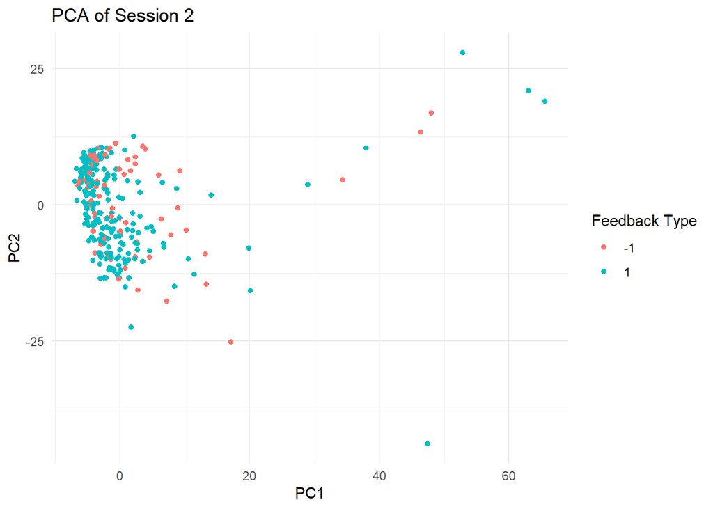

```r
# Visualizing the first two principal components
pca_df <- data.frame(PC1 = pca_result$x[,1], PC2 = pca_result$x[,2], feedback_type = processed_data$feedback_type)
ggplot(pca_df, aes(x = PC1, y = PC2, color = as.factor(feedback_type))) +
  geom_point() +
  labs(title = "PCA of Session 2", x = "PC1", y = "PC2", color = "Feedback Type") +
  theme_minimal()
```

```r
# Determine the number of PCs to explain at least 90% variance
cum_variance <- cumsum(pca_result$sdev^2) / sum(pca_result$sdev^2)
num_pcs <- which(cum_variance >= 0.90)[1]
cat("Number of PCs needed to explain 90% variance:", num_pcs, "\n")
```

```
## Number of PCs needed to explain 90% variance: 234
```

```r
# Extract the selected principal components
selected_pcs <- as.data.frame(pca_result$x[, 1:num_pcs])

# Combine the outcome variable with the selected PCs
pca_final_data <- cbind(feedback_type = processed_data$feedback_type, selected_pcs)

# Save the final PCA dataset
write.csv(pca_final_data, "pca_final_data_session6.csv", row.names = FALSE)

# Print dimensions of the new PCA dataset
print(dim(pca_final_data))
```

```
## [1] 290 235
```

```r
############################################7
# Load required libraries
library(ggplot2)

# Load the RDS file for session 7
data <- readRDS("C:/Users/ricky/Desktop/STA141AProject/data/session7.rds")

# Identify unique brain areas in session 7
unique_brain_areas <- unique(data$brain_area)
print(unique_brain_areas)
```

```
## [1] "VPL"  "root" "CA3"  "LD"   "CP"   "EPd"  "SSp"  "PIR"
```

```r
# Function to process session 7 with only its brain areas
process_session <- function(data, window_width = 0.1) {

  # Check if session contains relevant brain areas
  valid_neurons <- which(data$brain_area %in% unique_brain_areas)
  if (length(valid_neurons) == 0) return(NULL)  # Skip if no relevant neurons

  # Extract relevant spike data for valid neurons
  filtered_spikes <- lapply(data$spks, function(trial) trial[valid_neurons, ])

  # Function to compute time-resolved firing rates for one trial
  compute_firing_rates_time_resolved <- function(spike_matrix, time_vector, window_width = 0.1) {
    start_time <- min(time_vector)
    end_time <- max(time_vector)
    bins <- seq(start_time, end_time, by = window_width)
    if (tail(bins, 1) < end_time) {
      bins <- c(bins, end_time)
    }
    firing_rates_windows <- sapply(1:(length(bins) - 1), function(i) {
      window_start <- bins[i]
      window_end <- bins[i+1]
      indices <- which(time_vector >= window_start & time_vector < window_end)
      if (length(indices) == 0) {
        return(rep(0, nrow(spike_matrix)))
      } else {
        return(rowSums(spike_matrix[, indices, drop = FALSE]) / (window_end - window_start))
      }
    })
    return(firing_rates_windows)
  }

  # Apply time-resolved firing rate computation to each trial
  time_resolved_rates <- lapply(1:length(filtered_spikes), function(i) {
    compute_firing_rates_time_resolved(filtered_spikes[[i]], data$time[[i]], window_width)
  })

  # Flatten each trial's matrix (neurons x windows) into a single feature vector
  flattened_rates <- lapply(time_resolved_rates, function(mat) {
    as.vector(mat)
  })

  # Create a data frame for all trials from this session
  trial_df <- do.call(rbind, flattened_rates)

  # Extract feedback_type and ensure it's numeric
  if (!"feedback_type" %in% names(data)) return(NULL)
  feedback <- as.numeric(as.character(data$feedback_type))
  df <- data.frame(feedback_type = feedback)

  # Convert trial data to a data frame and assign column names (e.g., "N1_W1", "N1_W2", ...)
  trial_df <- as.data.frame(trial_df)
  num_neurons <- length(valid_neurons)
  num_windows <- ncol(time_resolved_rates[[1]])  # Assumes all trials have same number of windows
  colnames(trial_df) <- paste0("N", rep(1:num_neurons, each = num_windows),
                               "_W", rep(1:num_windows, times = num_neurons))

  # Merge feedback_type with the time-resolved features
  df <- cbind(df, trial_df)
  return(df)
}

# Process only session 7
processed_data <- process_session(data)

# Remove constant (zero-variance) columns before PCA
remove_constant_columns <- function(df) {
  non_constant_cols <- sapply(df, function(col) length(unique(col)) > 1)
  return(df[, non_constant_cols])
}

processed_data <- remove_constant_columns(processed_data)

# Perform PCA on the dataset (excluding the feedback_type column)
pca_data <- processed_data[, -1]  # Exclude feedback_type
pca_result <- prcomp(pca_data, scale. = TRUE)

# Display PCA summary
summary(pca_result)
```

```
## Importance of components:
##                            PC1     PC2     PC3     PC4     PC5     PC6     PC7
## Standard deviation     7.96509 6.40333 5.68072 4.98596 4.84286 4.67029 4.56426
## Proportion of Variance 0.02881 0.01862 0.01466 0.01129 0.01065 0.00991 0.00946
## Cumulative Proportion  0.02881 0.04743 0.06209 0.07338 0.08403 0.09393 0.10339
##                            PC8     PC9    PC10    PC11    PC12    PC13    PC14
## Standard deviation     4.36933 4.32116 4.31103 4.15807 4.14224 4.11381 4.06625
## Proportion of Variance 0.00867 0.00848 0.00844 0.00785 0.00779 0.00769 0.00751
## Cumulative Proportion  0.11206 0.12054 0.12898 0.13684 0.14463 0.15231 0.15982
##                           PC15    PC16    PC17    PC18    PC19    PC20    PC21
## Standard deviation     4.05883 4.02071 3.94522 3.90826 3.89950 3.86060 3.84586
## Proportion of Variance 0.00748 0.00734 0.00707 0.00694 0.00691 0.00677 0.00672
## Cumulative Proportion  0.16730 0.17464 0.18171 0.18865 0.19556 0.20232 0.20904
##                           PC22   PC23    PC24    PC25    PC26    PC27    PC28
## Standard deviation     3.82980 3.7832 3.75720 3.74959 3.74024 3.72721 3.69850
## Proportion of Variance 0.00666 0.0065 0.00641 0.00638 0.00635 0.00631 0.00621
## Cumulative Proportion  0.21570 0.2222 0.22861 0.23500 0.24135 0.24766 0.25387
##                           PC29    PC30    PC31    PC32    PC33    PC34    PC35
## Standard deviation     3.68627 3.68047 3.64858 3.63126 3.62389 3.61525 3.60276
## Proportion of Variance 0.00617 0.00615 0.00605 0.00599 0.00596 0.00594 0.00589
## Cumulative Proportion  0.26004 0.26619 0.27224 0.27823 0.28419 0.29013 0.29602
##                           PC36    PC37    PC38    PC39    PC40    PC41    PC42
## Standard deviation     3.58693 3.56149 3.55546 3.52076 3.51836 3.51349 3.49558
## Proportion of Variance 0.00584 0.00576 0.00574 0.00563 0.00562 0.00561 0.00555
## Cumulative Proportion  0.30186 0.30762 0.31337 0.31899 0.32462 0.33022 0.33577
##                           PC43    PC44    PC45    PC46    PC47    PC48    PC49
## Standard deviation     3.47504 3.47331 3.46460 3.45419 3.44013 3.42905 3.41369
## Proportion of Variance 0.00548 0.00548 0.00545 0.00542 0.00537 0.00534 0.00529
## Cumulative Proportion  0.34126 0.34673 0.35219 0.35760 0.36298 0.36832 0.37361
##                           PC50    PC51    PC52    PC53    PC54    PC55    PC56
## Standard deviation     3.40481 3.39165 3.36724 3.36243 3.35586 3.34689 3.32698
## Proportion of Variance 0.00526 0.00522 0.00515 0.00513 0.00511 0.00509 0.00503
## Cumulative Proportion  0.37887 0.38410 0.38925 0.39438 0.39950 0.40458 0.40961
##                           PC57    PC58    PC59    PC60    PC61    PC62    PC63
## Standard deviation     3.32095 3.31379 3.30196 3.29242 3.28173 3.27324 3.26275
## Proportion of Variance 0.00501 0.00499 0.00495 0.00492 0.00489 0.00487 0.00483
## Cumulative Proportion  0.41462 0.41961 0.42456 0.42948 0.43437 0.43924 0.44407
##                           PC64    PC65    PC66    PC67    PC68    PC69    PC70
## Standard deviation     3.24674 3.24250 3.23749 3.22462 3.22306 3.21229 3.19796
## Proportion of Variance 0.00479 0.00477 0.00476 0.00472 0.00472 0.00469 0.00464
```

[output cut: 90 more lines]

```
## Standard deviation     2.02483 2.01598 2.01055 2.00606 1.97755 1.97271 1.96864
## Proportion of Variance 0.00186 0.00185 0.00184 0.00183 0.00178 0.00177 0.00176
## Cumulative Proportion  0.95831 0.96016 0.96199 0.96382 0.96560 0.96736 0.96912
##                          PC232   PC233   PC234   PC235   PC236   PC237   PC238
## Standard deviation     1.95939 1.95279 1.94528 1.93058 1.92320 1.90861 1.90365
## Proportion of Variance 0.00174 0.00173 0.00172 0.00169 0.00168 0.00165 0.00165
## Cumulative Proportion  0.97087 0.97260 0.97432 0.97601 0.97769 0.97934 0.98099
##                          PC239   PC240   PC241   PC242   PC243  PC244   PC245
## Standard deviation     1.88746 1.88555 1.86592 1.85901 1.84011 1.8199 1.79500
## Proportion of Variance 0.00162 0.00161 0.00158 0.00157 0.00154 0.0015 0.00146
## Cumulative Proportion  0.98261 0.98422 0.98580 0.98737 0.98891 0.9904 0.99188
##                          PC246   PC247   PC248   PC249  PC250   PC251     PC252
## Standard deviation     1.77576 1.76363 1.75072 1.72915 1.6943 1.64217 1.034e-14
## Proportion of Variance 0.00143 0.00141 0.00139 0.00136 0.0013 0.00122 0.000e+00
## Cumulative Proportion  0.99331 0.99472 0.99611 0.99747 0.9988 1.00000 1.000e+00
```

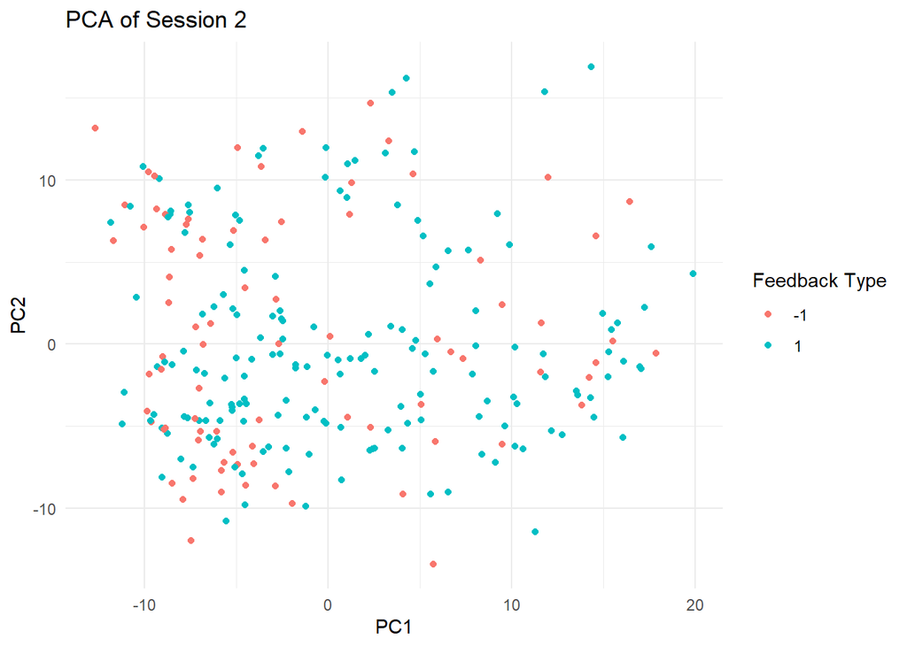

```r
# Visualizing the first two principal components
pca_df <- data.frame(PC1 = pca_result$x[,1], PC2 = pca_result$x[,2], feedback_type = processed_data$feedback_type)
ggplot(pca_df, aes(x = PC1, y = PC2, color = as.factor(feedback_type))) +
  geom_point() +
  labs(title = "PCA of Session 2", x = "PC1", y = "PC2", color = "Feedback Type") +
  theme_minimal()
```

```r
# Determine the number of PCs to explain at least 90% variance
cum_variance <- cumsum(pca_result$sdev^2) / sum(pca_result$sdev^2)
num_pcs <- which(cum_variance >= 0.90)[1]
cat("Number of PCs needed to explain 90% variance:", num_pcs, "\n")
```

```
## Number of PCs needed to explain 90% variance: 197
```

```r
# Extract the selected principal components
selected_pcs <- as.data.frame(pca_result$x[, 1:num_pcs])

# Combine the outcome variable with the selected PCs
pca_final_data <- cbind(feedback_type = processed_data$feedback_type, selected_pcs)

# Save the final PCA dataset
write.csv(pca_final_data, "pca_final_data_session7.csv", row.names = FALSE)

# Print dimensions of the new PCA dataset
print(dim(pca_final_data))
```

```
## [1] 252 198
```

```r
##################################session 8
# Load required libraries
library(ggplot2)

# Load the RDS file for session 8
data <- readRDS("C:/Users/ricky/Desktop/STA141AProject/data/session8.rds")

# Identify unique brain areas in session 8
unique_brain_areas <- unique(data$brain_area)
print(unique_brain_areas)
```

```
##  [1] "ILA"  "TT"   "MOs"  "PL"   "LSr"  "root" "LD"   "PO"   "CA3"  "VISa"
## [11] "CA1"  "LP"   "DG"   "VISp" "SUB"
```

```r
# Function to process session 8 with only its brain areas
process_session <- function(data, window_width = 0.1) {

  # Check if session contains relevant brain areas
  valid_neurons <- which(data$brain_area %in% unique_brain_areas)
  if (length(valid_neurons) == 0) return(NULL)  # Skip if no relevant neurons

  # Extract relevant spike data for valid neurons
  filtered_spikes <- lapply(data$spks, function(trial) trial[valid_neurons, ])

  # Function to compute time-resolved firing rates for one trial
  compute_firing_rates_time_resolved <- function(spike_matrix, time_vector, window_width = 0.1) {
    start_time <- min(time_vector)
    end_time <- max(time_vector)
    bins <- seq(start_time, end_time, by = window_width)
    if (tail(bins, 1) < end_time) {
      bins <- c(bins, end_time)
    }
    firing_rates_windows <- sapply(1:(length(bins) - 1), function(i) {
      window_start <- bins[i]
      window_end <- bins[i+1]
      indices <- which(time_vector >= window_start & time_vector < window_end)
      if (length(indices) == 0) {
        return(rep(0, nrow(spike_matrix)))
      } else {
        return(rowSums(spike_matrix[, indices, drop = FALSE]) / (window_end - window_start))
      }
    })
    return(firing_rates_windows)
  }

  # Apply time-resolved firing rate computation to each trial
  time_resolved_rates <- lapply(1:length(filtered_spikes), function(i) {
    compute_firing_rates_time_resolved(filtered_spikes[[i]], data$time[[i]], window_width)
  })

  # Flatten each trial's matrix (neurons x windows) into a single feature vector
  flattened_rates <- lapply(time_resolved_rates, function(mat) {
    as.vector(mat)
  })

  # Create a data frame for all trials from this session
  trial_df <- do.call(rbind, flattened_rates)

  # Extract feedback_type and ensure it's numeric
  if (!"feedback_type" %in% names(data)) return(NULL)
  feedback <- as.numeric(as.character(data$feedback_type))
  df <- data.frame(feedback_type = feedback)

  # Convert trial data to a data frame and assign column names (e.g., "N1_W1", "N1_W2", ...)
  trial_df <- as.data.frame(trial_df)
  num_neurons <- length(valid_neurons)
  num_windows <- ncol(time_resolved_rates[[1]])  # Assumes all trials have same number of windows
  colnames(trial_df) <- paste0("N", rep(1:num_neurons, each = num_windows),
                               "_W", rep(1:num_windows, times = num_neurons))

  # Merge feedback_type with the time-resolved features
  df <- cbind(df, trial_df)
  return(df)
}

# Process only session 2
processed_data <- process_session(data)

# Remove constant (zero-variance) columns before PCA
remove_constant_columns <- function(df) {
  non_constant_cols <- sapply(df, function(col) length(unique(col)) > 1)
  return(df[, non_constant_cols])
}

processed_data <- remove_constant_columns(processed_data)

# Perform PCA on the dataset (excluding the feedback_type column)
pca_data <- processed_data[, -1]  # Exclude feedback_type
pca_result <- prcomp(pca_data, scale. = TRUE)

# Display PCA summary
summary(pca_result)
```

```
## Importance of components:
##                             PC1     PC2     PC3     PC4     PC5     PC6     PC7
## Standard deviation     13.72664 8.71465 7.71894 7.48306 6.64080 6.49755 5.97401
## Proportion of Variance  0.04313 0.01738 0.01364 0.01282 0.01009 0.00966 0.00817
## Cumulative Proportion   0.04313 0.06051 0.07415 0.08696 0.09706 0.10672 0.11489
##                            PC8     PC9    PC10    PC11    PC12    PC13    PC14
## Standard deviation     5.86034 5.84008 5.69196 5.61910 5.59533 5.48759 5.47021
## Proportion of Variance 0.00786 0.00781 0.00742 0.00723 0.00717 0.00689 0.00685
## Cumulative Proportion  0.12275 0.13056 0.13797 0.14520 0.15236 0.15926 0.16611
##                           PC15    PC16    PC17    PC18    PC19    PC20    PC21
## Standard deviation     5.40458 5.35166 5.30155 5.18514 5.17547 5.11643 5.08970
## Proportion of Variance 0.00669 0.00656 0.00643 0.00615 0.00613 0.00599 0.00593
## Cumulative Proportion  0.17279 0.17935 0.18578 0.19193 0.19807 0.20406 0.20999
##                           PC22   PC23    PC24    PC25    PC26    PC27    PC28
## Standard deviation     5.05932 5.0346 5.02413 4.98423 4.96007 4.93271 4.92174
## Proportion of Variance 0.00586 0.0058 0.00578 0.00569 0.00563 0.00557 0.00554
## Cumulative Proportion  0.21584 0.2217 0.22742 0.23311 0.23874 0.24431 0.24985
##                           PC29    PC30    PC31    PC32    PC33    PC34    PC35
## Standard deviation     4.89005 4.87345 4.84896 4.84432 4.82427 4.81592 4.80420
## Proportion of Variance 0.00547 0.00544 0.00538 0.00537 0.00533 0.00531 0.00528
## Cumulative Proportion  0.25533 0.26076 0.26615 0.27152 0.27684 0.28215 0.28744
##                           PC36    PC37    PC38    PC39   PC40    PC41    PC42
## Standard deviation     4.77951 4.77300 4.76295 4.72827 4.7202 4.71228 4.68816
## Proportion of Variance 0.00523 0.00521 0.00519 0.00512 0.0051 0.00508 0.00503
## Cumulative Proportion  0.29266 0.29788 0.30307 0.30819 0.3133 0.31837 0.32340
##                          PC43    PC44    PC45    PC46    PC47    PC48    PC49
## Standard deviation     4.6756 4.65249 4.64815 4.64635 4.63981 4.63022 4.60743
## Proportion of Variance 0.0050 0.00495 0.00495 0.00494 0.00493 0.00491 0.00486
## Cumulative Proportion  0.3284 0.33336 0.33830 0.34324 0.34817 0.35308 0.35794
##                           PC50    PC51    PC52    PC53    PC54   PC55    PC56
## Standard deviation     4.59978 4.57379 4.56696 4.54729 4.54210 4.5325 4.50766
## Proportion of Variance 0.00484 0.00479 0.00477 0.00473 0.00472 0.0047 0.00465
## Cumulative Proportion  0.36278 0.36757 0.37234 0.37708 0.38180 0.3865 0.39115
##                           PC57   PC58    PC59    PC60    PC61    PC62    PC63
## Standard deviation     4.49613 4.4845 4.47920 4.46605 4.45178 4.44868 4.44437
## Proportion of Variance 0.00463 0.0046 0.00459 0.00457 0.00454 0.00453 0.00452
## Cumulative Proportion  0.39578 0.4004 0.40497 0.40954 0.41407 0.41860 0.42313
##                          PC64    PC65    PC66    PC67    PC68   PC69    PC70
## Standard deviation     4.4337 4.42639 4.41098 4.40433 4.39666 4.3824 4.37175
## Proportion of Variance 0.0045 0.00448 0.00445 0.00444 0.00442 0.0044 0.00437
```

[output cut: 90 more lines]

```
## Standard deviation     3.11922 3.10917 3.09342 3.08547 3.07875 3.06713 3.06222
## Proportion of Variance 0.00223 0.00221 0.00219 0.00218 0.00217 0.00215 0.00215
## Cumulative Proportion  0.95173 0.95395 0.95614 0.95832 0.96049 0.96264 0.96479
##                          PC232  PC233  PC234   PC235   PC236   PC237  PC238
## Standard deviation     3.04207 3.0314 3.0285 3.02317 3.00787 2.98287 2.9547
## Proportion of Variance 0.00212 0.0021 0.0021 0.00209 0.00207 0.00204 0.0020
## Cumulative Proportion  0.96690 0.9690 0.9711 0.97320 0.97527 0.97731 0.9793
##                          PC239   PC240   PC241   PC242   PC243  PC244   PC245
## Standard deviation     2.94894 2.94100 2.93779 2.90908 2.90344 2.8815 2.84996
## Proportion of Variance 0.00199 0.00198 0.00198 0.00194 0.00193 0.0019 0.00186
## Cumulative Proportion  0.98129 0.98327 0.98525 0.98719 0.98912 0.9910 0.99287
##                          PC246   PC247   PC248   PC249     PC250
## Standard deviation     2.83797 2.81028 2.77557 2.73381 2.649e-14
## Proportion of Variance 0.00184 0.00181 0.00176 0.00171 0.000e+00
## Cumulative Proportion  0.99472 0.99653 0.99829 1.00000 1.000e+00
```

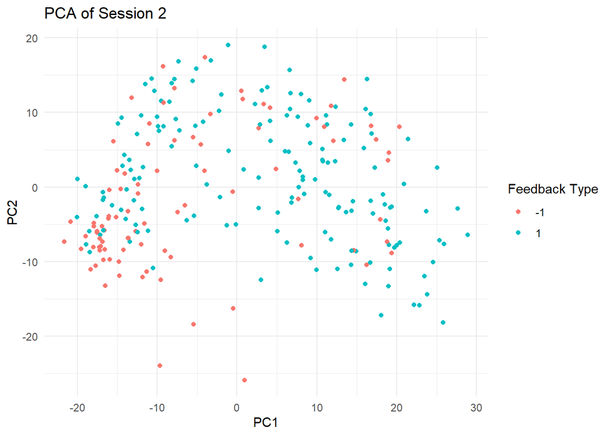

```r
# Visualizing the first two principal components
pca_df <- data.frame(PC1 = pca_result$x[,1], PC2 = pca_result$x[,2], feedback_type = processed_data$feedback_type)
ggplot(pca_df, aes(x = PC1, y = PC2, color = as.factor(feedback_type))) +
  geom_point() +
  labs(title = "PCA of Session 2", x = "PC1", y = "PC2", color = "Feedback Type") +
  theme_minimal()
```

```r
# Determine the number of PCs to explain at least 90% variance
cum_variance <- cumsum(pca_result$sdev^2) / sum(pca_result$sdev^2)
num_pcs <- which(cum_variance >= 0.90)[1]
cat("Number of PCs needed to explain 90% variance:", num_pcs, "\n")
```

```
## Number of PCs needed to explain 90% variance: 204
```

```r
# Extract the selected principal components
selected_pcs <- as.data.frame(pca_result$x[, 1:num_pcs])

# Combine the outcome variable with the selected PCs
pca_final_data <- cbind(feedback_type = processed_data$feedback_type, selected_pcs)

# Save the final PCA dataset
write.csv(pca_final_data, "pca_final_data_session8.csv", row.names = FALSE)

# Print dimensions of the new PCA dataset
print(dim(pca_final_data))
```

```
## [1] 250 205
```

```r
################################### session 9
# Load required libraries
library(ggplot2)

# Load the RDS file for session 9
data <- readRDS("C:/Users/ricky/Desktop/STA141AProject/data/session9.rds")

# Identify unique brain areas in session 9
unique_brain_areas <- unique(data$brain_area)
print(unique_brain_areas)
```

```
##  [1] "TT"    "ORBm"  "PL"    "LSr"   "root"  "CA3"   "VISl"  "CA1"   "TH"
## [10] "VISam" "VPL"   "LD"
```

```r
# Function to process session 9 with only its brain areas
process_session <- function(data, window_width = 0.1) {

  # Check if session contains relevant brain areas
  valid_neurons <- which(data$brain_area %in% unique_brain_areas)
  if (length(valid_neurons) == 0) return(NULL)  # Skip if no relevant neurons

  # Extract relevant spike data for valid neurons
  filtered_spikes <- lapply(data$spks, function(trial) trial[valid_neurons, ])

  # Function to compute time-resolved firing rates for one trial
  compute_firing_rates_time_resolved <- function(spike_matrix, time_vector, window_width = 0.1) {
    start_time <- min(time_vector)
    end_time <- max(time_vector)
    bins <- seq(start_time, end_time, by = window_width)
    if (tail(bins, 1) < end_time) {
      bins <- c(bins, end_time)
    }
    firing_rates_windows <- sapply(1:(length(bins) - 1), function(i) {
      window_start <- bins[i]
      window_end <- bins[i+1]
      indices <- which(time_vector >= window_start & time_vector < window_end)
      if (length(indices) == 0) {
        return(rep(0, nrow(spike_matrix)))
      } else {
        return(rowSums(spike_matrix[, indices, drop = FALSE]) / (window_end - window_start))
      }
    })
    return(firing_rates_windows)
  }

  # Apply time-resolved firing rate computation to each trial
  time_resolved_rates <- lapply(1:length(filtered_spikes), function(i) {
    compute_firing_rates_time_resolved(filtered_spikes[[i]], data$time[[i]], window_width)
  })

  # Flatten each trial's matrix (neurons x windows) into a single feature vector
  flattened_rates <- lapply(time_resolved_rates, function(mat) {
    as.vector(mat)
  })

  # Create a data frame for all trials from this session
  trial_df <- do.call(rbind, flattened_rates)

  # Extract feedback_type and ensure it's numeric
  if (!"feedback_type" %in% names(data)) return(NULL)
  feedback <- as.numeric(as.character(data$feedback_type))
  df <- data.frame(feedback_type = feedback)

  # Convert trial data to a data frame and assign column names (e.g., "N1_W1", "N1_W2", ...)
  trial_df <- as.data.frame(trial_df)
  num_neurons <- length(valid_neurons)
  num_windows <- ncol(time_resolved_rates[[1]])  # Assumes all trials have same number of windows
  colnames(trial_df) <- paste0("N", rep(1:num_neurons, each = num_windows),
                               "_W", rep(1:num_windows, times = num_neurons))

  # Merge feedback_type with the time-resolved features
  df <- cbind(df, trial_df)
  return(df)
}

# Process only session 2
processed_data <- process_session(data)

# Remove constant (zero-variance) columns before PCA
remove_constant_columns <- function(df) {
  non_constant_cols <- sapply(df, function(col) length(unique(col)) > 1)
  return(df[, non_constant_cols])
}

processed_data <- remove_constant_columns(processed_data)

# Perform PCA on the dataset (excluding the feedback_type column)
pca_data <- processed_data[, -1]  # Exclude feedback_type
pca_result <- prcomp(pca_data, scale. = TRUE)

# Display PCA summary
summary(pca_result)
```

```
## Importance of components:
##                            PC1     PC2     PC3     PC4     PC5     PC6     PC7
## Standard deviation     9.20161 6.64233 5.38953 5.11305 4.82193 4.69408 4.54965
## Proportion of Variance 0.02851 0.01486 0.00978 0.00880 0.00783 0.00742 0.00697
## Cumulative Proportion  0.02851 0.04336 0.05314 0.06195 0.06977 0.07719 0.08416
##                            PC8     PC9    PC10    PC11    PC12    PC13    PC14
## Standard deviation     4.30681 4.28349 4.20952 4.16317 4.14313 4.03778 4.01397
## Proportion of Variance 0.00625 0.00618 0.00597 0.00584 0.00578 0.00549 0.00542
## Cumulative Proportion  0.09041 0.09659 0.10255 0.10839 0.11417 0.11966 0.12508
##                          PC15    PC16    PC17    PC18    PC19    PC20    PC21
## Standard deviation     3.9660 3.95603 3.90064 3.87199 3.83869 3.83073 3.78169
## Proportion of Variance 0.0053 0.00527 0.00512 0.00505 0.00496 0.00494 0.00482
## Cumulative Proportion  0.1304 0.13565 0.14077 0.14582 0.15078 0.15572 0.16054
##                           PC22    PC23    PC24    PC25   PC26    PC27    PC28
## Standard deviation     3.76347 3.74312 3.73026 3.70563 3.6979 3.67312 3.66071
## Proportion of Variance 0.00477 0.00472 0.00469 0.00462 0.0046 0.00454 0.00451
## Cumulative Proportion  0.16531 0.17002 0.17471 0.17933 0.1839 0.18848 0.19299
##                          PC29    PC30    PC31   PC32    PC33    PC34    PC35
## Standard deviation     3.6546 3.63127 3.62220 3.6138 3.59733 3.59318 3.56245
## Proportion of Variance 0.0045 0.00444 0.00442 0.0044 0.00436 0.00435 0.00427
## Cumulative Proportion  0.1975 0.20193 0.20634 0.2107 0.21510 0.21945 0.22372
##                           PC36    PC37    PC38    PC39    PC40    PC41    PC42
## Standard deviation     3.54645 3.53921 3.52092 3.51264 3.50727 3.50023 3.48209
## Proportion of Variance 0.00423 0.00422 0.00417 0.00415 0.00414 0.00413 0.00408
## Cumulative Proportion  0.22795 0.23217 0.23635 0.24050 0.24464 0.24877 0.25285
##                           PC43    PC44    PC45    PC46    PC47    PC48    PC49
## Standard deviation     3.47423 3.46622 3.45330 3.44216 3.43127 3.43060 3.41642
## Proportion of Variance 0.00406 0.00405 0.00402 0.00399 0.00396 0.00396 0.00393
## Cumulative Proportion  0.25691 0.26096 0.26497 0.26896 0.27293 0.27689 0.28082
##                          PC50    PC51    PC52    PC53    PC54    PC55   PC56
## Standard deviation     3.4018 3.39282 3.39214 3.37876 3.37672 3.36727 3.3604
## Proportion of Variance 0.0039 0.00388 0.00387 0.00384 0.00384 0.00382 0.0038
## Cumulative Proportion  0.2847 0.28859 0.29247 0.29631 0.30015 0.30397 0.3078
##                           PC57    PC58    PC59    PC60   PC61    PC62    PC63
## Standard deviation     3.35482 3.33855 3.33717 3.33043 3.3149 3.30627 3.30129
## Proportion of Variance 0.00379 0.00375 0.00375 0.00373 0.0037 0.00368 0.00367
## Cumulative Proportion  0.31156 0.31531 0.31906 0.32280 0.3265 0.33018 0.33385
##                           PC64    PC65    PC66    PC67   PC68    PC69    PC70
## Standard deviation     3.29044 3.28140 3.27727 3.27378 3.2676 3.25380 3.25005
## Proportion of Variance 0.00365 0.00363 0.00362 0.00361 0.0036 0.00356 0.00356
```

[output cut: 162 more lines]

```
## Standard deviation     1.84192 1.83382 1.82952 1.82764 1.81816 1.8046 1.80044
## Proportion of Variance 0.00114 0.00113 0.00113 0.00112 0.00111 0.0011 0.00109
## Cumulative Proportion  0.97914 0.98027 0.98140 0.98252 0.98363 0.9847 0.98582
##                          PC358   PC359   PC360   PC361   PC362   PC363   PC364
## Standard deviation     1.79660 1.79504 1.77799 1.76738 1.76030 1.75457 1.74197
## Proportion of Variance 0.00109 0.00108 0.00106 0.00105 0.00104 0.00104 0.00102
## Cumulative Proportion  0.98691 0.98799 0.98906 0.99011 0.99115 0.99219 0.99321
##                          PC365  PC366   PC367   PC368   PC369   PC370   PC371
## Standard deviation     1.73085 1.7217 1.70981 1.69399 1.67850 1.67519 1.66815
## Proportion of Variance 0.00101 0.0010 0.00098 0.00097 0.00095 0.00094 0.00094
## Cumulative Proportion  0.99422 0.9952 0.99620 0.99717 0.99812 0.99906 1.00000
##                            PC372
## Standard deviation     1.447e-14
## Proportion of Variance 0.000e+00
## Cumulative Proportion  1.000e+00
```

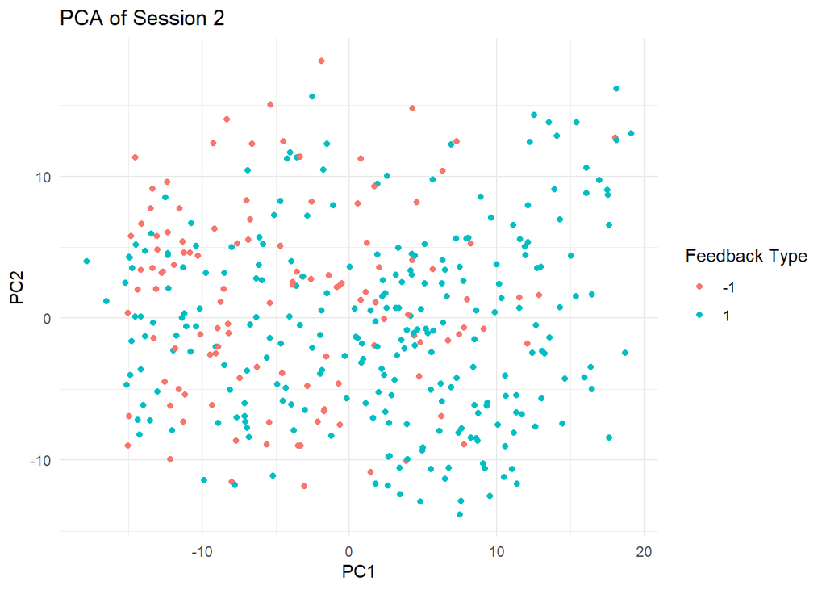

```r
# Visualizing the first two principal components
pca_df <- data.frame(PC1 = pca_result$x[,1], PC2 = pca_result$x[,2], feedback_type = processed_data$feedback_type)
ggplot(pca_df, aes(x = PC1, y = PC2, color = as.factor(feedback_type))) +
  geom_point() +
  labs(title = "PCA of Session 2", x = "PC1", y = "PC2", color = "Feedback Type") +
  theme_minimal()
```

```r
# Determine the number of PCs to explain at least 90% variance
cum_variance <- cumsum(pca_result$sdev^2) / sum(pca_result$sdev^2)
num_pcs <- which(cum_variance >= 0.90)[1]
cat("Number of PCs needed to explain 90% variance:", num_pcs, "\n")
```

```
## Number of PCs needed to explain 90% variance: 293
```

```r
# Extract the selected principal components
selected_pcs <- as.data.frame(pca_result$x[, 1:num_pcs])

# Combine the outcome variable with the selected PCs
pca_final_data <- cbind(feedback_type = processed_data$feedback_type, selected_pcs)

# Save the final PCA dataset
write.csv(pca_final_data, "pca_final_data_session9.csv", row.names = FALSE)

# Print dimensions of the new PCA dataset
print(dim(pca_final_data))
```

```
## [1] 372 294
```

```r
################################# session 10
# Load required libraries
library(ggplot2)

# Load the RDS file for session 10
data <- readRDS("C:/Users/ricky/Desktop/STA141AProject/data/session10.rds")

# Identify unique brain areas in session 10
unique_brain_areas <- unique(data$brain_area)
print(unique_brain_areas)
```

```
##  [1] "MB"    "VISp"  "SCm"   "SCsg"  "POST"  "DG"    "MRN"   "CA1"   "VISl"
## [10] "POL"   "root"  "GPe"   "VISrl"
```

```r
# Function to process session 10 with only its brain areas
process_session <- function(data, window_width = 0.1) {

  # Check if session contains relevant brain areas
  valid_neurons <- which(data$brain_area %in% unique_brain_areas)
  if (length(valid_neurons) == 0) return(NULL)  # Skip if no relevant neurons

  # Extract relevant spike data for valid neurons
  filtered_spikes <- lapply(data$spks, function(trial) trial[valid_neurons, ])

  # Function to compute time-resolved firing rates for one trial
  compute_firing_rates_time_resolved <- function(spike_matrix, time_vector, window_width = 0.1) {
    start_time <- min(time_vector)
    end_time <- max(time_vector)
    bins <- seq(start_time, end_time, by = window_width)
    if (tail(bins, 1) < end_time) {
      bins <- c(bins, end_time)
    }
    firing_rates_windows <- sapply(1:(length(bins) - 1), function(i) {
      window_start <- bins[i]
      window_end <- bins[i+1]
      indices <- which(time_vector >= window_start & time_vector < window_end)
      if (length(indices) == 0) {
        return(rep(0, nrow(spike_matrix)))
      } else {
        return(rowSums(spike_matrix[, indices, drop = FALSE]) / (window_end - window_start))
      }
    })
    return(firing_rates_windows)
  }

  # Apply time-resolved firing rate computation to each trial
  time_resolved_rates <- lapply(1:length(filtered_spikes), function(i) {
    compute_firing_rates_time_resolved(filtered_spikes[[i]], data$time[[i]], window_width)
  })

  # Flatten each trial's matrix (neurons x windows) into a single feature vector
  flattened_rates <- lapply(time_resolved_rates, function(mat) {
    as.vector(mat)
  })

  # Create a data frame for all trials from this session
  trial_df <- do.call(rbind, flattened_rates)

  # Extract feedback_type and ensure it's numeric
  if (!"feedback_type" %in% names(data)) return(NULL)
  feedback <- as.numeric(as.character(data$feedback_type))
  df <- data.frame(feedback_type = feedback)

  # Convert trial data to a data frame and assign column names (e.g., "N1_W1", "N1_W2", ...)
  trial_df <- as.data.frame(trial_df)
  num_neurons <- length(valid_neurons)
  num_windows <- ncol(time_resolved_rates[[1]])  # Assumes all trials have same number of windows
  colnames(trial_df) <- paste0("N", rep(1:num_neurons, each = num_windows),
                               "_W", rep(1:num_windows, times = num_neurons))

  # Merge feedback_type with the time-resolved features
  df <- cbind(df, trial_df)
  return(df)
}

# Process only session 2
processed_data <- process_session(data)

# Remove constant (zero-variance) columns before PCA
remove_constant_columns <- function(df) {
  non_constant_cols <- sapply(df, function(col) length(unique(col)) > 1)
  return(df[, non_constant_cols])
}

processed_data <- remove_constant_columns(processed_data)

# Perform PCA on the dataset (excluding the feedback_type column)
pca_data <- processed_data[, -1]  # Exclude feedback_type
pca_result <- prcomp(pca_data, scale. = TRUE)

# Display PCA summary
summary(pca_result)
```

```
## Importance of components:
##                             PC1     PC2     PC3     PC4     PC5     PC6     PC7
## Standard deviation     11.07454 9.41750 7.64607 6.69396 6.24839 5.88247 5.74060
## Proportion of Variance  0.02759 0.01995 0.01315 0.01008 0.00878 0.00778 0.00741
## Cumulative Proportion   0.02759 0.04753 0.06068 0.07076 0.07954 0.08733 0.09474
##                            PC8     PC9   PC10    PC11    PC12    PC13    PC14
## Standard deviation     5.59213 5.49414 5.3758 5.29557 5.21074 5.13422 5.08893
## Proportion of Variance 0.00703 0.00679 0.0065 0.00631 0.00611 0.00593 0.00582
## Cumulative Proportion  0.10177 0.10856 0.1151 0.12137 0.12748 0.13341 0.13923
##                           PC15    PC16    PC17   PC18    PC19    PC20    PC21
## Standard deviation     4.99546 4.93044 4.82282 4.7633 4.68802 4.63985 4.57500
## Proportion of Variance 0.00561 0.00547 0.00523 0.0051 0.00494 0.00484 0.00471
## Cumulative Proportion  0.14484 0.15031 0.15554 0.1606 0.16559 0.17043 0.17514
##                           PC22    PC23    PC24    PC25   PC26   PC27    PC28
## Standard deviation     4.54185 4.49656 4.48384 4.44240 4.4251 4.3723 4.33550
## Proportion of Variance 0.00464 0.00455 0.00452 0.00444 0.0044 0.0043 0.00423
## Cumulative Proportion  0.17978 0.18433 0.18885 0.19329 0.1977 0.2020 0.20622
##                          PC29    PC30    PC31    PC32    PC33    PC34   PC35
## Standard deviation     4.3191 4.28439 4.27457 4.23712 4.20175 4.17671 4.1625
## Proportion of Variance 0.0042 0.00413 0.00411 0.00404 0.00397 0.00392 0.0039
## Cumulative Proportion  0.2104 0.21454 0.21865 0.22269 0.22666 0.23059 0.2345
##                           PC36    PC37    PC38    PC39    PC40    PC41   PC42
## Standard deviation     4.13943 4.13101 4.09962 4.07397 4.04874 4.02485 4.0001
## Proportion of Variance 0.00385 0.00384 0.00378 0.00373 0.00369 0.00364 0.0036
## Cumulative Proportion  0.23834 0.24217 0.24595 0.24969 0.25337 0.25702 0.2606
##                           PC43    PC44    PC45    PC46    PC47    PC48    PC49
## Standard deviation     3.98324 3.97176 3.96014 3.95159 3.94108 3.93510 3.92074
## Proportion of Variance 0.00357 0.00355 0.00353 0.00351 0.00349 0.00348 0.00346
## Cumulative Proportion  0.26419 0.26773 0.27126 0.27477 0.27827 0.28175 0.28521
##                           PC50   PC51    PC52    PC53    PC54    PC55    PC56
## Standard deviation     3.91382 3.8900 3.88313 3.87029 3.86269 3.85156 3.84010
## Proportion of Variance 0.00345 0.0034 0.00339 0.00337 0.00336 0.00334 0.00332
## Cumulative Proportion  0.28865 0.2921 0.29545 0.29882 0.30217 0.30551 0.30883
##                          PC57    PC58    PC59    PC60    PC61    PC62    PC63
## Standard deviation     3.8302 3.81809 3.81567 3.79849 3.78777 3.77849 3.77715
## Proportion of Variance 0.0033 0.00328 0.00327 0.00325 0.00323 0.00321 0.00321
## Cumulative Proportion  0.3121 0.31541 0.31868 0.32192 0.32515 0.32836 0.33157
##                           PC64    PC65    PC66    PC67    PC68    PC69   PC70
## Standard deviation     3.76640 3.75809 3.75123 3.73704 3.72422 3.71979 3.7140
## Proportion of Variance 0.00319 0.00318 0.00317 0.00314 0.00312 0.00311 0.0031
```

[output cut: 202 more lines]

```
## Standard deviation     1.96138 1.95922 1.95452 1.93943 1.93633 1.93332 1.91646
## Proportion of Variance 0.00087 0.00086 0.00086 0.00085 0.00084 0.00084 0.00083
## Cumulative Proportion  0.98095 0.98182 0.98268 0.98352 0.98436 0.98521 0.98603
##                          PC428   PC429  PC430  PC431   PC432   PC433   PC434
## Standard deviation     1.91096 1.90108 1.8870 1.8846 1.87580 1.86923 1.85016
## Proportion of Variance 0.00082 0.00081 0.0008 0.0008 0.00079 0.00079 0.00077
## Cumulative Proportion  0.98685 0.98767 0.9885 0.9893 0.99006 0.99084 0.99161
##                          PC435   PC436   PC437   PC438   PC439   PC440   PC441
## Standard deviation     1.84626 1.83004 1.81888 1.81384 1.79256 1.79146 1.78082
## Proportion of Variance 0.00077 0.00075 0.00074 0.00074 0.00072 0.00072 0.00071
## Cumulative Proportion  0.99238 0.99313 0.99388 0.99462 0.99534 0.99606 0.99677
##                         PC442   PC443   PC444   PC445   PC446     PC447
## Standard deviation     1.7609 1.75040 1.70756 1.64408 1.59932 3.162e-14
## Proportion of Variance 0.0007 0.00069 0.00066 0.00061 0.00058 0.000e+00
## Cumulative Proportion  0.9975 0.99816 0.99882 0.99942 1.00000 1.000e+00
```

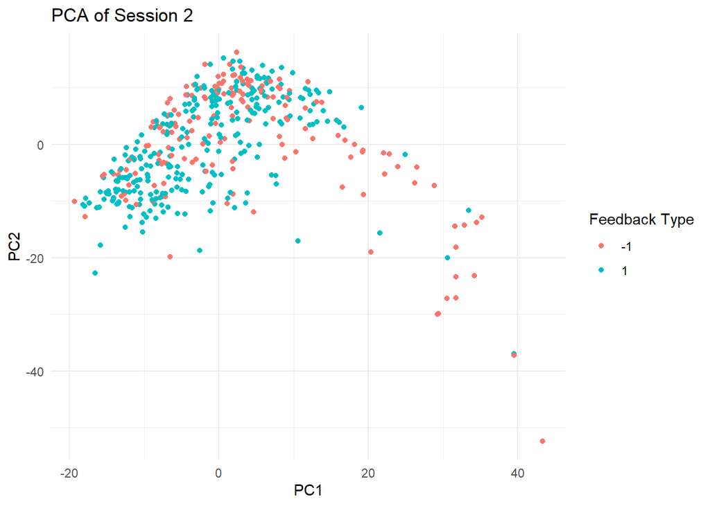

```r
# Visualizing the first two principal components
pca_df <- data.frame(PC1 = pca_result$x[,1], PC2 = pca_result$x[,2], feedback_type = processed_data$feedback_type)
ggplot(pca_df, aes(x = PC1, y = PC2, color = as.factor(feedback_type))) +
  geom_point() +
  labs(title = "PCA of Session 2", x = "PC1", y = "PC2", color = "Feedback Type") +
  theme_minimal()
```

```r
# Determine the number of PCs to explain at least 90% variance
cum_variance <- cumsum(pca_result$sdev^2) / sum(pca_result$sdev^2)
num_pcs <- which(cum_variance >= 0.90)[1]
cat("Number of PCs needed to explain 90% variance:", num_pcs, "\n")
```

```
## Number of PCs needed to explain 90% variance: 345
```

```r
# Extract the selected principal components
selected_pcs <- as.data.frame(pca_result$x[, 1:num_pcs])

# Combine the outcome variable with the selected PCs
pca_final_data <- cbind(feedback_type = processed_data$feedback_type, selected_pcs)

# Save the final PCA dataset
write.csv(pca_final_data, "pca_final_data_session10.csv", row.names = FALSE)

# Print dimensions of the new PCA dataset
print(dim(pca_final_data))
```

```
## [1] 447 346
```

```r
##################################session 11
# Load required libraries
library(ggplot2)

# Load the RDS file for session 11
data <- readRDS("C:/Users/ricky/Desktop/STA141AProject/data/session11.rds")

# Identify unique brain areas in session 11
unique_brain_areas <- unique(data$brain_area)
print(unique_brain_areas)
```

```
## [1] "MOp"  "LSc"  "root" "PT"   "CP"   "LSr"
```

```r
# Function to process session 11 with only its brain areas
process_session <- function(data, window_width = 0.1) {

  # Check if session contains relevant brain areas
  valid_neurons <- which(data$brain_area %in% unique_brain_areas)
  if (length(valid_neurons) == 0) return(NULL)  # Skip if no relevant neurons

  # Extract relevant spike data for valid neurons
  filtered_spikes <- lapply(data$spks, function(trial) trial[valid_neurons, ])

  # Function to compute time-resolved firing rates for one trial
  compute_firing_rates_time_resolved <- function(spike_matrix, time_vector, window_width = 0.1) {
    start_time <- min(time_vector)
    end_time <- max(time_vector)
    bins <- seq(start_time, end_time, by = window_width)
    if (tail(bins, 1) < end_time) {
      bins <- c(bins, end_time)
    }
    firing_rates_windows <- sapply(1:(length(bins) - 1), function(i) {
      window_start <- bins[i]
      window_end <- bins[i+1]
      indices <- which(time_vector >= window_start & time_vector < window_end)
      if (length(indices) == 0) {
        return(rep(0, nrow(spike_matrix)))
      } else {
        return(rowSums(spike_matrix[, indices, drop = FALSE]) / (window_end - window_start))
      }
    })
    return(firing_rates_windows)
  }

  # Apply time-resolved firing rate computation to each trial
  time_resolved_rates <- lapply(1:length(filtered_spikes), function(i) {
    compute_firing_rates_time_resolved(filtered_spikes[[i]], data$time[[i]], window_width)
  })

  # Flatten each trial's matrix (neurons x windows) into a single feature vector
  flattened_rates <- lapply(time_resolved_rates, function(mat) {
    as.vector(mat)
  })

  # Create a data frame for all trials from this session
  trial_df <- do.call(rbind, flattened_rates)

  # Extract feedback_type and ensure it's numeric
  if (!"feedback_type" %in% names(data)) return(NULL)
  feedback <- as.numeric(as.character(data$feedback_type))
  df <- data.frame(feedback_type = feedback)

  # Convert trial data to a data frame and assign column names (e.g., "N1_W1", "N1_W2", ...)
  trial_df <- as.data.frame(trial_df)
  num_neurons <- length(valid_neurons)
  num_windows <- ncol(time_resolved_rates[[1]])  # Assumes all trials have same number of windows
  colnames(trial_df) <- paste0("N", rep(1:num_neurons, each = num_windows),
                               "_W", rep(1:num_windows, times = num_neurons))

  # Merge feedback_type with the time-resolved features
  df <- cbind(df, trial_df)
  return(df)
}

# Process only session 2
processed_data <- process_session(data)

# Remove constant (zero-variance) columns before PCA
remove_constant_columns <- function(df) {
  non_constant_cols <- sapply(df, function(col) length(unique(col)) > 1)
  return(df[, non_constant_cols])
}

processed_data <- remove_constant_columns(processed_data)

# Perform PCA on the dataset (excluding the feedback_type column)
pca_data <- processed_data[, -1]  # Exclude feedback_type
pca_result <- prcomp(pca_data, scale. = TRUE)

# Display PCA summary
summary(pca_result)
```

```
## Importance of components:
##                             PC1     PC2     PC3    PC4     PC5     PC6     PC7
## Standard deviation     12.35409 7.27365 6.87036 6.6561 5.68989 5.33270 5.06813
## Proportion of Variance  0.04892 0.01696 0.01513 0.0142 0.01038 0.00911 0.00823
## Cumulative Proportion   0.04892 0.06587 0.08100 0.0952 0.10558 0.11469 0.12293
##                            PC8    PC9    PC10   PC11    PC12    PC13    PC14
## Standard deviation     4.96701 4.8694 4.75396 4.6734 4.57567 4.55978 4.51788
## Proportion of Variance 0.00791 0.0076 0.00724 0.0070 0.00671 0.00666 0.00654
## Cumulative Proportion  0.13083 0.1384 0.14568 0.1527 0.15939 0.16605 0.17259
##                           PC15    PC16   PC17    PC18    PC19    PC20    PC21
## Standard deviation     4.45984 4.41564 4.3966 4.38552 4.30296 4.29603 4.26457
## Proportion of Variance 0.00638 0.00625 0.0062 0.00616 0.00593 0.00592 0.00583
## Cumulative Proportion  0.17897 0.18522 0.1914 0.19758 0.20351 0.20943 0.21526
##                           PC22    PC23    PC24    PC25    PC26    PC27    PC28
## Standard deviation     4.20808 4.20334 4.16926 4.16235 4.10999 4.10085 4.08810
## Proportion of Variance 0.00568 0.00566 0.00557 0.00555 0.00541 0.00539 0.00536
## Cumulative Proportion  0.22093 0.22660 0.23217 0.23772 0.24313 0.24852 0.25388
##                           PC29   PC30    PC31    PC32    PC33    PC34    PC35
## Standard deviation     4.05339 4.0275 4.02080 3.97474 3.93682 3.92332 3.90435
## Proportion of Variance 0.00527 0.0052 0.00518 0.00506 0.00497 0.00493 0.00489
## Cumulative Proportion  0.25915 0.2643 0.26953 0.27459 0.27956 0.28449 0.28938
##                           PC36   PC37    PC38    PC39    PC40    PC41   PC42
## Standard deviation     3.88653 3.8713 3.85627 3.82564 3.82257 3.80760 3.7903
## Proportion of Variance 0.00484 0.0048 0.00477 0.00469 0.00468 0.00465 0.0046
## Cumulative Proportion  0.29422 0.2990 0.30379 0.30848 0.31316 0.31781 0.3224
##                           PC43    PC44    PC45    PC46    PC47    PC48    PC49
## Standard deviation     3.78611 3.76365 3.75729 3.74310 3.71708 3.70081 3.67989
## Proportion of Variance 0.00459 0.00454 0.00452 0.00449 0.00443 0.00439 0.00434
## Cumulative Proportion  0.32701 0.33155 0.33607 0.34057 0.34499 0.34938 0.35372
##                           PC50    PC51    PC52    PC53    PC54    PC55    PC56
## Standard deviation     3.67351 3.64332 3.64068 3.62319 3.61684 3.60793 3.60332
## Proportion of Variance 0.00433 0.00425 0.00425 0.00421 0.00419 0.00417 0.00416
## Cumulative Proportion  0.35805 0.36230 0.36655 0.37076 0.37495 0.37912 0.38329
##                           PC57    PC58    PC59    PC60    PC61   PC62    PC63
## Standard deviation     3.57928 3.57085 3.56335 3.55243 3.53610 3.5316 3.51517
## Proportion of Variance 0.00411 0.00409 0.00407 0.00404 0.00401 0.0040 0.00396
## Cumulative Proportion  0.38739 0.39148 0.39555 0.39959 0.40360 0.4076 0.41156
##                           PC64   PC65    PC66    PC67    PC68    PC69    PC70
## Standard deviation     3.50848 3.4897 3.48336 3.47845 3.46927 3.46058 3.44869
## Proportion of Variance 0.00395 0.0039 0.00389 0.00388 0.00386 0.00384 0.00381
```

[output cut: 142 more lines]

```
## Standard deviation     1.75711 1.75306 1.74056 1.73574 1.73192 1.72697 1.72074
## Proportion of Variance 0.00099 0.00099 0.00097 0.00097 0.00096 0.00096 0.00095
## Cumulative Proportion  0.97901 0.97999 0.98096 0.98193 0.98289 0.98384 0.98479
##                          PC323   PC324   PC325  PC326   PC327   PC328   PC329
## Standard deviation     1.69824 1.69019 1.68386 1.6713 1.65357 1.64939 1.63295
## Proportion of Variance 0.00092 0.00092 0.00091 0.0009 0.00088 0.00087 0.00085
## Cumulative Proportion  0.98572 0.98663 0.98754 0.9884 0.98931 0.99019 0.99104
##                          PC330   PC331   PC332   PC333   PC334   PC335   PC336
## Standard deviation     1.62274 1.59751 1.56638 1.56230 1.55098 1.53000 1.52088
## Proportion of Variance 0.00084 0.00082 0.00079 0.00078 0.00077 0.00075 0.00074
## Cumulative Proportion  0.99188 0.99270 0.99349 0.99427 0.99504 0.99579 0.99653
##                          PC337   PC338   PC339   PC340   PC341     PC342
## Standard deviation     1.50760 1.49166 1.47251 1.45503 1.42467 1.704e-14
## Proportion of Variance 0.00073 0.00071 0.00069 0.00068 0.00065 0.000e+00
## Cumulative Proportion  0.99726 0.99798 0.99867 0.99935 1.00000 1.000e+00
```

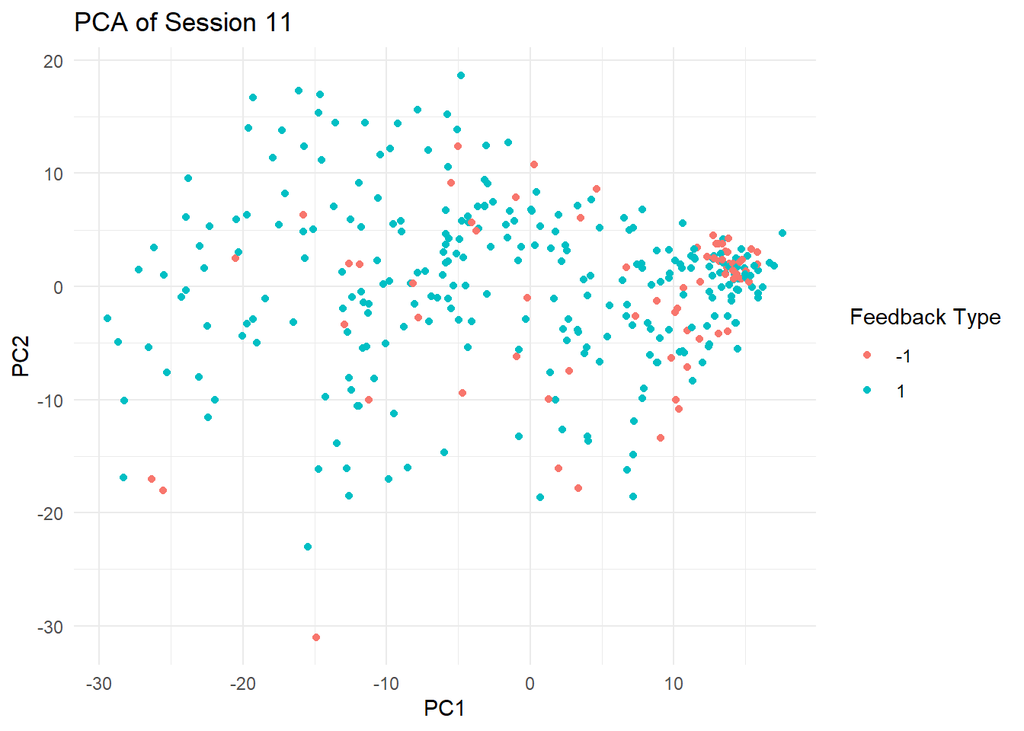

```r
# Visualizing the first two principal components
pca_df <- data.frame(PC1 = pca_result$x[,1], PC2 = pca_result$x[,2], feedback_type = processed_data$feedback_type)
ggplot(pca_df, aes(x = PC1, y = PC2, color = as.factor(feedback_type))) +
  geom_point() +
  labs(title = "PCA of Session 11", x = "PC1", y = "PC2", color = "Feedback Type") +
  theme_minimal()
```

```r
# Determine the number of PCs to explain at least 90% variance
cum_variance <- cumsum(pca_result$sdev^2) / sum(pca_result$sdev^2)
num_pcs <- which(cum_variance >= 0.90)[1]
cat("Number of PCs needed to explain 90% variance:", num_pcs, "\n")
```

```
## Number of PCs needed to explain 90% variance: 255
```

```r
# Extract the selected principal components
selected_pcs <- as.data.frame(pca_result$x[, 1:num_pcs])

# Combine the outcome variable with the selected PCs
pca_final_data <- cbind(feedback_type = processed_data$feedback_type, selected_pcs)

# Save the final PCA dataset
write.csv(pca_final_data, "pca_final_data_session11.csv", row.names = FALSE)

# Print dimensions of the new PCA dataset
print(dim(pca_final_data))
```

```
## [1] 342 256
```

```r
################################## session 12
# Load required libraries
library(ggplot2)

# Load the RDS file for session 12
data <- readRDS("C:/Users/ricky/Desktop/STA141AProject/data/session12.rds")

# Identify unique brain areas in session 12
unique_brain_areas <- unique(data$brain_area)
print(unique_brain_areas)
```

```
##  [1] "VISp"  "DG"    "SUB"   "LGd"   "PL"    "root"  "MOs"   "ACA"   "CA1"
## [10] "VISam" "MD"    "LH"
```

```r
# Function to process session 12 with only its brain areas
process_session <- function(data, window_width = 0.1) {

  # Check if session contains relevant brain areas
  valid_neurons <- which(data$brain_area %in% unique_brain_areas)
  if (length(valid_neurons) == 0) return(NULL)  # Skip if no relevant neurons

  # Extract relevant spike data for valid neurons
  filtered_spikes <- lapply(data$spks, function(trial) trial[valid_neurons, ])

  # Function to compute time-resolved firing rates for one trial
  compute_firing_rates_time_resolved <- function(spike_matrix, time_vector, window_width = 0.1) {
    start_time <- min(time_vector)
    end_time <- max(time_vector)
    bins <- seq(start_time, end_time, by = window_width)
    if (tail(bins, 1) < end_time) {
      bins <- c(bins, end_time)
    }
    firing_rates_windows <- sapply(1:(length(bins) - 1), function(i) {
      window_start <- bins[i]
      window_end <- bins[i+1]
      indices <- which(time_vector >= window_start & time_vector < window_end)
      if (length(indices) == 0) {
        return(rep(0, nrow(spike_matrix)))
      } else {
        return(rowSums(spike_matrix[, indices, drop = FALSE]) / (window_end - window_start))
      }
    })
    return(firing_rates_windows)
  }

  # Apply time-resolved firing rate computation to each trial
  time_resolved_rates <- lapply(1:length(filtered_spikes), function(i) {
    compute_firing_rates_time_resolved(filtered_spikes[[i]], data$time[[i]], window_width)
  })

  # Flatten each trial's matrix (neurons x windows) into a single feature vector
  flattened_rates <- lapply(time_resolved_rates, function(mat) {
    as.vector(mat)
  })

  # Create a data frame for all trials from this session
  trial_df <- do.call(rbind, flattened_rates)

  # Extract feedback_type and ensure it's numeric
  if (!"feedback_type" %in% names(data)) return(NULL)
  feedback <- as.numeric(as.character(data$feedback_type))
  df <- data.frame(feedback_type = feedback)

  # Convert trial data to a data frame and assign column names (e.g., "N1_W1", "N1_W2", ...)
  trial_df <- as.data.frame(trial_df)
  num_neurons <- length(valid_neurons)
  num_windows <- ncol(time_resolved_rates[[1]])  # Assumes all trials have same number of windows
  colnames(trial_df) <- paste0("N", rep(1:num_neurons, each = num_windows),
                               "_W", rep(1:num_windows, times = num_neurons))

  # Merge feedback_type with the time-resolved features
  df <- cbind(df, trial_df)
  return(df)
}

# Process only session 2
processed_data <- process_session(data)

# Remove constant (zero-variance) columns before PCA
remove_constant_columns <- function(df) {
  non_constant_cols <- sapply(df, function(col) length(unique(col)) > 1)
  return(df[, non_constant_cols])
}

processed_data <- remove_constant_columns(processed_data)

# Perform PCA on the dataset (excluding the feedback_type column)
pca_data <- processed_data[, -1]  # Exclude feedback_type
pca_result <- prcomp(pca_data, scale. = TRUE)

# Display PCA summary
summary(pca_result)
```

```
## Importance of components:
##                            PC1     PC2     PC3     PC4     PC5     PC6     PC7
## Standard deviation     7.69057 7.02660 6.34727 5.21738 4.75279 4.68883 4.66334
## Proportion of Variance 0.02223 0.01855 0.01514 0.01023 0.00849 0.00826 0.00817
## Cumulative Proportion  0.02223 0.04078 0.05592 0.06615 0.07464 0.08290 0.09107
##                            PC8     PC9    PC10    PC11    PC12    PC13    PC14
## Standard deviation     4.44325 4.26426 4.18769 4.07220 4.02555 3.96993 3.95321
## Proportion of Variance 0.00742 0.00683 0.00659 0.00623 0.00609 0.00592 0.00587
## Cumulative Proportion  0.09849 0.10533 0.11192 0.11815 0.12424 0.13016 0.13603
##                           PC15    PC16    PC17    PC18    PC19   PC20   PC21
## Standard deviation     3.91110 3.87819 3.82743 3.81308 3.79784 3.7900 3.7572
## Proportion of Variance 0.00575 0.00565 0.00551 0.00546 0.00542 0.0054 0.0053
## Cumulative Proportion  0.14178 0.14743 0.15294 0.15840 0.16382 0.1692 0.1745
##                           PC22    PC23    PC24    PC25    PC26   PC27    PC28
## Standard deviation     3.74313 3.70356 3.69562 3.63951 3.63314 3.6111 3.58435
## Proportion of Variance 0.00527 0.00515 0.00513 0.00498 0.00496 0.0049 0.00483
## Cumulative Proportion  0.17979 0.18495 0.19008 0.19506 0.20002 0.2049 0.20975
##                           PC29    PC30    PC31    PC32    PC33    PC34    PC35
## Standard deviation     3.57986 3.56133 3.55656 3.53226 3.50975 3.50713 3.49427
## Proportion of Variance 0.00482 0.00477 0.00475 0.00469 0.00463 0.00462 0.00459
## Cumulative Proportion  0.21456 0.21933 0.22408 0.22877 0.23340 0.23802 0.24261
##                           PC36    PC37    PC38   PC39    PC40    PC41    PC42
## Standard deviation     3.48284 3.47779 3.47427 3.4602 3.44576 3.42832 3.41716
## Proportion of Variance 0.00456 0.00455 0.00454 0.0045 0.00446 0.00442 0.00439
## Cumulative Proportion  0.24717 0.25171 0.25625 0.2607 0.26521 0.26963 0.27402
##                           PC43    PC44    PC45   PC46    PC47    PC48    PC49
## Standard deviation     3.40706 3.40635 3.39393 3.3828 3.37431 3.35293 3.34755
## Proportion of Variance 0.00436 0.00436 0.00433 0.0043 0.00428 0.00422 0.00421
## Cumulative Proportion  0.27838 0.28274 0.28707 0.2914 0.29565 0.29987 0.30408
##                           PC50    PC51    PC52    PC53   PC54    PC55    PC56
## Standard deviation     3.33388 3.32434 3.31569 3.30997 3.3050 3.30069 3.29048
## Proportion of Variance 0.00418 0.00415 0.00413 0.00412 0.0041 0.00409 0.00407
## Cumulative Proportion  0.30826 0.31241 0.31655 0.32066 0.3248 0.32886 0.33293
##                           PC57    PC58  PC59    PC60    PC61    PC62    PC63
## Standard deviation     3.28509 3.27076 3.262 3.24973 3.24227 3.23254 3.23081
## Proportion of Variance 0.00406 0.00402 0.004 0.00397 0.00395 0.00393 0.00392
## Cumulative Proportion  0.33699 0.34101 0.345 0.34897 0.35293 0.35685 0.36077
##                          PC64    PC65    PC66    PC67    PC68    PC69    PC70
## Standard deviation     3.2227 3.21761 3.21383 3.20379 3.19686 3.19532 3.19085
## Proportion of Variance 0.0039 0.00389 0.00388 0.00386 0.00384 0.00384 0.00383
```

[output cut: 142 more lines]

```
## Standard deviation     1.83745 1.83069 1.82301 1.81517 1.80094 1.79928 1.79455
## Proportion of Variance 0.00127 0.00126 0.00125 0.00124 0.00122 0.00122 0.00121
## Cumulative Proportion  0.97382 0.97508 0.97633 0.97757 0.97879 0.98001 0.98122
##                         PC323   PC324   PC325   PC326   PC327   PC328   PC329
## Standard deviation     1.7898 1.78113 1.76851 1.76771 1.75084 1.74642 1.73431
## Proportion of Variance 0.0012 0.00119 0.00118 0.00117 0.00115 0.00115 0.00113
## Cumulative Proportion  0.9824 0.98361 0.98479 0.98596 0.98711 0.98826 0.98939
##                          PC330   PC331   PC332   PC333   PC334   PC335   PC336
## Standard deviation     1.72176 1.71723 1.70320 1.69156 1.68784 1.67595 1.66519
## Proportion of Variance 0.00111 0.00111 0.00109 0.00108 0.00107 0.00106 0.00104
## Cumulative Proportion  0.99050 0.99161 0.99270 0.99378 0.99485 0.99590 0.99695
##                          PC337   PC338   PC339     PC340
## Standard deviation     1.65863 1.65603 1.62336 1.935e-14
## Proportion of Variance 0.00103 0.00103 0.00099 0.000e+00
## Cumulative Proportion  0.99798 0.99901 1.00000 1.000e+00
```

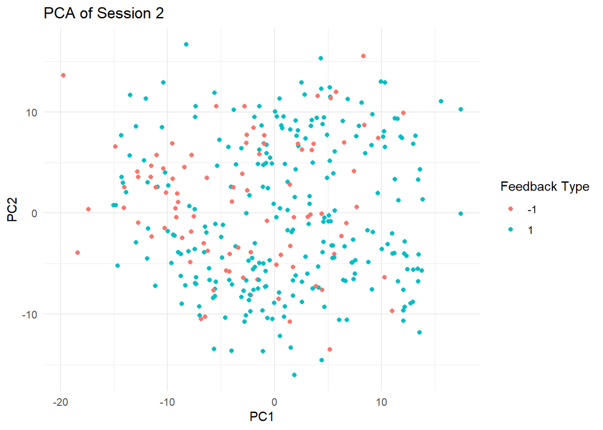

```r
# Visualizing the first two principal components
pca_df <- data.frame(PC1 = pca_result$x[,1], PC2 = pca_result$x[,2], feedback_type = processed_data$feedback_type)
ggplot(pca_df, aes(x = PC1, y = PC2, color = as.factor(feedback_type))) +
  geom_point() +
  labs(title = "PCA of Session 2", x = "PC1", y = "PC2", color = "Feedback Type") +
  theme_minimal()
```

```r
# Determine the number of PCs to explain at least 90% variance
cum_variance <- cumsum(pca_result$sdev^2) / sum(pca_result$sdev^2)
num_pcs <- which(cum_variance >= 0.90)[1]
cat("Number of PCs needed to explain 90% variance:", num_pcs, "\n")
```

```
## Number of PCs needed to explain 90% variance: 266
```

```r
# Extract the selected principal components
selected_pcs <- as.data.frame(pca_result$x[, 1:num_pcs])

# Combine the outcome variable with the selected PCs
pca_final_data <- cbind(feedback_type = processed_data$feedback_type, selected_pcs)

# Save the final PCA dataset
write.csv(pca_final_data, "pca_final_data_session12.csv", row.names = FALSE)

# Print dimensions of the new PCA dataset
print(dim(pca_final_data))
```

```
## [1] 340 267
```

```r
###################################### session 13
# Load required libraries
library(ggplot2)

# Load the RDS file for session 13
data <- readRDS("C:/Users/ricky/Desktop/STA141AProject/data/session13.rds")

# Identify unique brain areas in session 13
unique_brain_areas <- unique(data$brain_area)
print(unique_brain_areas)
```

```
##  [1] "VISam" "ZI"    "DG"    "CA1"   "LGd"   "MB"    "SCs"   "RN"    "MRN"
## [10] "SCm"   "ACA"   "PL"    "MS"    "root"  "MOs"
```

```r
# Function to process session 13 with only its brain areas
process_session <- function(data, window_width = 0.1) {

  # Check if session contains relevant brain areas
  valid_neurons <- which(data$brain_area %in% unique_brain_areas)
  if (length(valid_neurons) == 0) return(NULL)  # Skip if no relevant neurons

  # Extract relevant spike data for valid neurons
  filtered_spikes <- lapply(data$spks, function(trial) trial[valid_neurons, ])

  # Function to compute time-resolved firing rates for one trial
  compute_firing_rates_time_resolved <- function(spike_matrix, time_vector, window_width = 0.1) {
    start_time <- min(time_vector)
    end_time <- max(time_vector)
    bins <- seq(start_time, end_time, by = window_width)
    if (tail(bins, 1) < end_time) {
      bins <- c(bins, end_time)
    }
    firing_rates_windows <- sapply(1:(length(bins) - 1), function(i) {
      window_start <- bins[i]
      window_end <- bins[i+1]
      indices <- which(time_vector >= window_start & time_vector < window_end)
      if (length(indices) == 0) {
        return(rep(0, nrow(spike_matrix)))
      } else {
        return(rowSums(spike_matrix[, indices, drop = FALSE]) / (window_end - window_start))
      }
    })
    return(firing_rates_windows)
  }

  # Apply time-resolved firing rate computation to each trial
  time_resolved_rates <- lapply(1:length(filtered_spikes), function(i) {
    compute_firing_rates_time_resolved(filtered_spikes[[i]], data$time[[i]], window_width)
  })

  # Flatten each trial's matrix (neurons x windows) into a single feature vector
  flattened_rates <- lapply(time_resolved_rates, function(mat) {
    as.vector(mat)
  })

  # Create a data frame for all trials from this session
  trial_df <- do.call(rbind, flattened_rates)

  # Extract feedback_type and ensure it's numeric
  if (!"feedback_type" %in% names(data)) return(NULL)
  feedback <- as.numeric(as.character(data$feedback_type))
  df <- data.frame(feedback_type = feedback)

  # Convert trial data to a data frame and assign column names (e.g., "N1_W1", "N1_W2", ...)
  trial_df <- as.data.frame(trial_df)
  num_neurons <- length(valid_neurons)
  num_windows <- ncol(time_resolved_rates[[1]])  # Assumes all trials have same number of windows
  colnames(trial_df) <- paste0("N", rep(1:num_neurons, each = num_windows),
                               "_W", rep(1:num_windows, times = num_neurons))

  # Merge feedback_type with the time-resolved features
  df <- cbind(df, trial_df)
  return(df)
}

# Process only session 2
processed_data <- process_session(data)

# Remove constant (zero-variance) columns before PCA
remove_constant_columns <- function(df) {
  non_constant_cols <- sapply(df, function(col) length(unique(col)) > 1)
  return(df[, non_constant_cols])
}

processed_data <- remove_constant_columns(processed_data)

# Perform PCA on the dataset (excluding the feedback_type column)
pca_data <- processed_data[, -1]  # Exclude feedback_type
pca_result <- prcomp(pca_data, scale. = TRUE)

# Display PCA summary
summary(pca_result)
```

```
## Importance of components:
##                             PC1     PC2     PC3     PC4     PC5     PC6     PC7
## Standard deviation     11.04487 8.59190 8.45312 7.77048 7.30154 6.81980 6.14770
## Proportion of Variance  0.03215 0.01946 0.01883 0.01591 0.01405 0.01226 0.00996
## Cumulative Proportion   0.03215 0.05161 0.07044 0.08636 0.10041 0.11267 0.12263
##                           PC8     PC9    PC10    PC11   PC12    PC13    PC14
## Standard deviation     5.7778 5.63261 5.42134 5.23937 5.1896 5.14446 5.00077
## Proportion of Variance 0.0088 0.00836 0.00775 0.00724 0.0071 0.00698 0.00659
## Cumulative Proportion  0.1314 0.13979 0.14754 0.15477 0.1619 0.16885 0.17544
##                           PC15    PC16    PC17    PC18    PC19    PC20    PC21
## Standard deviation     4.90881 4.87848 4.86288 4.77326 4.72159 4.68879 4.63132
## Proportion of Variance 0.00635 0.00627 0.00623 0.00601 0.00588 0.00579 0.00565
## Cumulative Proportion  0.18179 0.18806 0.19430 0.20030 0.20618 0.21197 0.21763
##                           PC22    PC23    PC24    PC25    PC26    PC27    PC28
## Standard deviation     4.57139 4.53585 4.52286 4.50958 4.50245 4.47377 4.43796
## Proportion of Variance 0.00551 0.00542 0.00539 0.00536 0.00534 0.00528 0.00519
## Cumulative Proportion  0.22313 0.22856 0.23395 0.23931 0.24465 0.24993 0.25512
##                           PC29    PC30    PC31    PC32    PC33    PC34    PC35
## Standard deviation     4.40917 4.37603 4.34435 4.33592 4.30089 4.27939 4.26072
## Proportion of Variance 0.00512 0.00505 0.00497 0.00496 0.00488 0.00483 0.00478
## Cumulative Proportion  0.26024 0.26529 0.27026 0.27522 0.28010 0.28492 0.28971
##                           PC36    PC37    PC38    PC39    PC40    PC41    PC42
## Standard deviation     4.24519 4.22671 4.20103 4.18669 4.16643 4.15862 4.14750
## Proportion of Variance 0.00475 0.00471 0.00465 0.00462 0.00458 0.00456 0.00453
## Cumulative Proportion  0.29446 0.29917 0.30382 0.30844 0.31301 0.31757 0.32211
##                          PC43    PC44    PC45   PC46    PC47    PC48   PC49
## Standard deviation     4.1298 4.10835 4.09613 4.0877 4.06309 4.05304 4.0385
## Proportion of Variance 0.0045 0.00445 0.00442 0.0044 0.00435 0.00433 0.0043
## Cumulative Proportion  0.3266 0.33105 0.33547 0.3399 0.34423 0.34856 0.3529
##                           PC50    PC51    PC52    PC53   PC54    PC55    PC56
## Standard deviation     4.02981 4.02670 4.02370 4.00343 3.9905 3.98071 3.96290
## Proportion of Variance 0.00428 0.00427 0.00427 0.00422 0.0042 0.00418 0.00414
## Cumulative Proportion  0.35714 0.36141 0.36568 0.36990 0.3741 0.37827 0.38241
##                           PC57   PC58    PC59    PC60    PC61   PC62    PC63
## Standard deviation     3.95312 3.9418 3.92221 3.91288 3.90438 3.8961 3.87898
## Proportion of Variance 0.00412 0.0041 0.00405 0.00404 0.00402 0.0040 0.00397
## Cumulative Proportion  0.38653 0.3906 0.39468 0.39872 0.40274 0.4067 0.41070
##                           PC64    PC65    PC66    PC67    PC68    PC69    PC70
## Standard deviation     3.87708 3.85001 3.84137 3.83484 3.83044 3.82612 3.81249
## Proportion of Variance 0.00396 0.00391 0.00389 0.00388 0.00387 0.00386 0.00383
```

[output cut: 118 more lines]

```
## Standard deviation     2.45583 2.44646 2.44195 2.42715 2.41903 2.40645 2.40506
## Proportion of Variance 0.00159 0.00158 0.00157 0.00155 0.00154 0.00153 0.00152
## Cumulative Proportion  0.96407 0.96565 0.96722 0.96877 0.97031 0.97184 0.97337
##                          PC281   PC282  PC283   PC284   PC285   PC286   PC287
## Standard deviation     2.39604 2.39225 2.3852 2.36976 2.36166 2.35063 2.34907
## Proportion of Variance 0.00151 0.00151 0.0015 0.00148 0.00147 0.00146 0.00145
## Cumulative Proportion  0.97488 0.97639 0.9779 0.97937 0.98084 0.98229 0.98375
##                          PC288   PC289  PC290   PC291   PC292   PC293   PC294
## Standard deviation     2.32741 2.31286 2.3008 2.29956 2.29451 2.27910 2.27202
## Proportion of Variance 0.00143 0.00141 0.0014 0.00139 0.00139 0.00137 0.00136
## Cumulative Proportion  0.98518 0.98659 0.9880 0.98937 0.99076 0.99213 0.99349
##                          PC295   PC296   PC297   PC298   PC299     PC300
## Standard deviation     2.25884 2.24117 2.23036 2.19370 2.18654 1.441e-14
## Proportion of Variance 0.00134 0.00132 0.00131 0.00127 0.00126 0.000e+00
## Cumulative Proportion  0.99484 0.99616 0.99747 0.99874 1.00000 1.000e+00
```

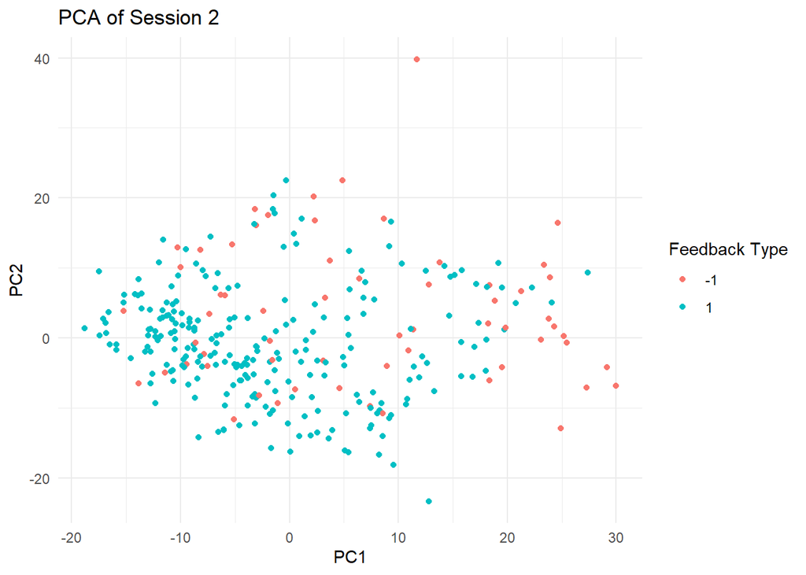

```r
# Visualizing the first two principal components
pca_df <- data.frame(PC1 = pca_result$x[,1], PC2 = pca_result$x[,2], feedback_type = processed_data$feedback_type)
ggplot(pca_df, aes(x = PC1, y = PC2, color = as.factor(feedback_type))) +
  geom_point() +
  labs(title = "PCA of Session 2", x = "PC1", y = "PC2", color = "Feedback Type") +
  theme_minimal()
```

```r
# Determine the number of PCs to explain at least 90% variance
cum_variance <- cumsum(pca_result$sdev^2) / sum(pca_result$sdev^2)
num_pcs <- which(cum_variance >= 0.90)[1]
cat("Number of PCs needed to explain 90% variance:", num_pcs, "\n")
```

```
## Number of PCs needed to explain 90% variance: 238
```

```r
# Extract the selected principal components
selected_pcs <- as.data.frame(pca_result$x[, 1:num_pcs])

# Combine the outcome variable with the selected PCs
pca_final_data <- cbind(feedback_type = processed_data$feedback_type, selected_pcs)

# Save the final PCA dataset
write.csv(pca_final_data, "pca_final_data_session13.csv", row.names = FALSE)

# Print dimensions of the new PCA dataset
print(dim(pca_final_data))
```

```
## [1] 300 239
```

```r
########################################### session 14
# Load required libraries
library(ggplot2)

# Load the RDS file for session 14
data <- readRDS("C:/Users/ricky/Desktop/STA141AProject/data/session14.rds")

# Identify unique brain areas in session 14
unique_brain_areas <- unique(data$brain_area)
print(unique_brain_areas)
```

```
##  [1] "ORB"  "MOs"  "root" "MRN"  "SCm"  "SCs"  "VISp" "RSP"  "CA1"  "PAG"
```

```r
# Function to process session 14 with only its brain areas
process_session <- function(data, window_width = 0.1) {

  # Check if session contains relevant brain areas
  valid_neurons <- which(data$brain_area %in% unique_brain_areas)
  if (length(valid_neurons) == 0) return(NULL)  # Skip if no relevant neurons

  # Extract relevant spike data for valid neurons
  filtered_spikes <- lapply(data$spks, function(trial) trial[valid_neurons, ])

  # Function to compute time-resolved firing rates for one trial
  compute_firing_rates_time_resolved <- function(spike_matrix, time_vector, window_width = 0.1) {
    start_time <- min(time_vector)
    end_time <- max(time_vector)
    bins <- seq(start_time, end_time, by = window_width)
    if (tail(bins, 1) < end_time) {
      bins <- c(bins, end_time)
    }
    firing_rates_windows <- sapply(1:(length(bins) - 1), function(i) {
      window_start <- bins[i]
      window_end <- bins[i+1]
      indices <- which(time_vector >= window_start & time_vector < window_end)
      if (length(indices) == 0) {
        return(rep(0, nrow(spike_matrix)))
      } else {
        return(rowSums(spike_matrix[, indices, drop = FALSE]) / (window_end - window_start))
      }
    })
    return(firing_rates_windows)
  }

  # Apply time-resolved firing rate computation to each trial
  time_resolved_rates <- lapply(1:length(filtered_spikes), function(i) {
    compute_firing_rates_time_resolved(filtered_spikes[[i]], data$time[[i]], window_width)
  })

  # Flatten each trial's matrix (neurons x windows) into a single feature vector
  flattened_rates <- lapply(time_resolved_rates, function(mat) {
    as.vector(mat)
  })

  # Create a data frame for all trials from this session
  trial_df <- do.call(rbind, flattened_rates)

  # Extract feedback_type and ensure it's numeric
  if (!"feedback_type" %in% names(data)) return(NULL)
  feedback <- as.numeric(as.character(data$feedback_type))
  df <- data.frame(feedback_type = feedback)

  # Convert trial data to a data frame and assign column names (e.g., "N1_W1", "N1_W2", ...)
  trial_df <- as.data.frame(trial_df)
  num_neurons <- length(valid_neurons)
  num_windows <- ncol(time_resolved_rates[[1]])  # Assumes all trials have same number of windows
  colnames(trial_df) <- paste0("N", rep(1:num_neurons, each = num_windows),
                               "_W", rep(1:num_windows, times = num_neurons))

  # Merge feedback_type with the time-resolved features
  df <- cbind(df, trial_df)
  return(df)
}

# Process only session 2
processed_data <- process_session(data)

# Remove constant (zero-variance) columns before PCA
remove_constant_columns <- function(df) {
  non_constant_cols <- sapply(df, function(col) length(unique(col)) > 1)
  return(df[, non_constant_cols])
}

processed_data <- remove_constant_columns(processed_data)

# Perform PCA on the dataset (excluding the feedback_type column)
pca_data <- processed_data[, -1]  # Exclude feedback_type
pca_result <- prcomp(pca_data, scale. = TRUE)

# Display PCA summary
summary(pca_result)
```

```
## Importance of components:
##                            PC1     PC2     PC3     PC4     PC5     PC6     PC7
## Standard deviation     8.05530 6.33662 6.18739 5.58596 5.35711 4.95959 4.78180
## Proportion of Variance 0.02447 0.01514 0.01444 0.01177 0.01082 0.00928 0.00862
## Cumulative Proportion  0.02447 0.03961 0.05404 0.06581 0.07663 0.08591 0.09453
##                            PC8     PC9    PC10    PC11    PC12    PC13    PC14
## Standard deviation     4.71051 4.53691 4.49702 4.44362 4.37372 4.28786 4.23486
## Proportion of Variance 0.00837 0.00776 0.00763 0.00745 0.00721 0.00693 0.00676
## Cumulative Proportion  0.10290 0.11066 0.11828 0.12573 0.13294 0.13987 0.14664
##                           PC15    PC16    PC17    PC18    PC19    PC20    PC21
## Standard deviation     4.19680 4.17127 4.13513 4.10748 4.06596 4.04946 4.04452
## Proportion of Variance 0.00664 0.00656 0.00645 0.00636 0.00623 0.00618 0.00617
## Cumulative Proportion  0.15328 0.15984 0.16629 0.17265 0.17888 0.18507 0.19123
##                          PC22    PC23    PC24    PC25    PC26    PC27    PC28
## Standard deviation     4.0229 3.98339 3.96748 3.95216 3.94628 3.91029 3.87976
## Proportion of Variance 0.0061 0.00598 0.00594 0.00589 0.00587 0.00577 0.00568
## Cumulative Proportion  0.1973 0.20332 0.20925 0.21514 0.22102 0.22678 0.23246
##                           PC29    PC30    PC31    PC32   PC33    PC34   PC35
## Standard deviation     3.87112 3.86119 3.84241 3.82568 3.8206 3.79977 3.7826
## Proportion of Variance 0.00565 0.00562 0.00557 0.00552 0.0055 0.00544 0.0054
## Cumulative Proportion  0.23811 0.24373 0.24930 0.25482 0.2603 0.26576 0.2712
##                           PC36   PC37    PC38    PC39   PC40    PC41    PC42
## Standard deviation     3.77360 3.7494 3.72639 3.71929 3.7125 3.70167 3.68803
## Proportion of Variance 0.00537 0.0053 0.00524 0.00522 0.0052 0.00517 0.00513
## Cumulative Proportion  0.27653 0.2818 0.28707 0.29228 0.2975 0.30265 0.30778
##                           PC43    PC44    PC45    PC46    PC47    PC48    PC49
## Standard deviation     3.66780 3.66427 3.65421 3.62610 3.61608 3.60784 3.60249
## Proportion of Variance 0.00507 0.00506 0.00504 0.00496 0.00493 0.00491 0.00489
## Cumulative Proportion  0.31285 0.31791 0.32295 0.32790 0.33283 0.33774 0.34264
##                           PC50    PC51    PC52    PC53   PC54    PC55    PC56
## Standard deviation     3.59641 3.58533 3.58517 3.58158 3.5664 3.54615 3.53782
## Proportion of Variance 0.00488 0.00485 0.00485 0.00484 0.0048 0.00474 0.00472
## Cumulative Proportion  0.34751 0.35236 0.35721 0.36204 0.3668 0.37158 0.37630
##                           PC57    PC58    PC59    PC60    PC61   PC62    PC63
## Standard deviation     3.53324 3.52313 3.51031 3.50530 3.49975 3.4942 3.46984
## Proportion of Variance 0.00471 0.00468 0.00465 0.00463 0.00462 0.0046 0.00454
## Cumulative Proportion  0.38101 0.38569 0.39034 0.39497 0.39959 0.4042 0.40873
##                           PC64    PC65    PC66    PC67    PC68   PC69    PC70
## Standard deviation     3.46583 3.44556 3.43610 3.42766 3.42472 3.4162 3.41135
## Proportion of Variance 0.00453 0.00448 0.00445 0.00443 0.00442 0.0044 0.00439
```

[output cut: 102 more lines]

```
## Standard deviation     2.18942 2.17638 2.16617 2.15872 2.14961 2.14294 2.13509
## Proportion of Variance 0.00181 0.00179 0.00177 0.00176 0.00174 0.00173 0.00172
## Cumulative Proportion  0.96601 0.96780 0.96956 0.97132 0.97306 0.97480 0.97651
##                         PC253  PC254   PC255   PC256   PC257   PC258   PC259
## Standard deviation     2.1250 2.1212 2.10228 2.09321 2.07071 2.06900 2.05357
## Proportion of Variance 0.0017 0.0017 0.00167 0.00165 0.00162 0.00161 0.00159
## Cumulative Proportion  0.9782 0.9799 0.98158 0.98323 0.98485 0.98646 0.98805
##                          PC260   PC261   PC262  PC263  PC264   PC265   PC266
## Standard deviation     2.04412 2.04121 2.01248 1.9969 1.9923 1.97619 1.95790
## Proportion of Variance 0.00158 0.00157 0.00153 0.0015 0.0015 0.00147 0.00145
## Cumulative Proportion  0.98963 0.99120 0.99273 0.9942 0.9957 0.99720 0.99865
##                          PC267    PC268
## Standard deviation     1.89482 1.84e-14
## Proportion of Variance 0.00135 0.00e+00
## Cumulative Proportion  1.00000 1.00e+00
```

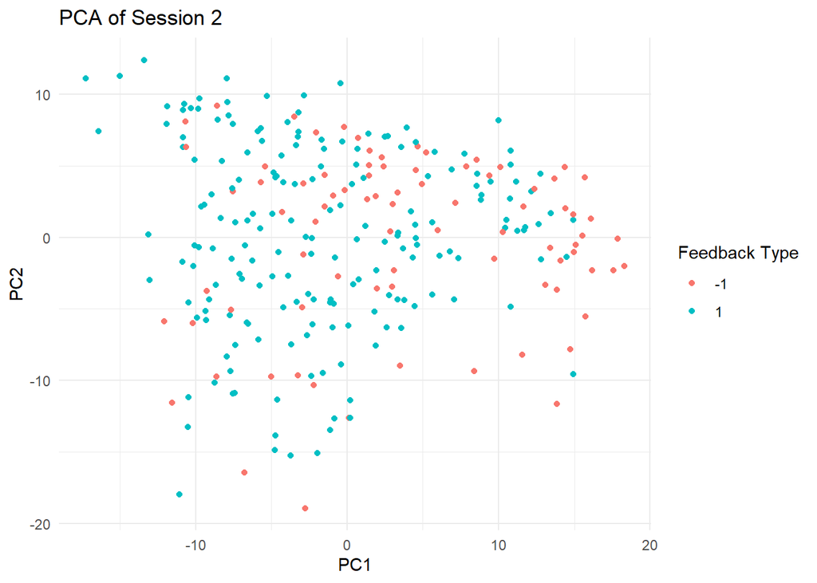

```r
# Visualizing the first two principal components
pca_df <- data.frame(PC1 = pca_result$x[,1], PC2 = pca_result$x[,2], feedback_type = processed_data$feedback_type)
ggplot(pca_df, aes(x = PC1, y = PC2, color = as.factor(feedback_type))) +
  geom_point() +
  labs(title = "PCA of Session 2", x = "PC1", y = "PC2", color = "Feedback Type") +
  theme_minimal()
```

```r
# Determine the number of PCs to explain at least 90% variance
cum_variance <- cumsum(pca_result$sdev^2) / sum(pca_result$sdev^2)
num_pcs <- which(cum_variance >= 0.90)[1]
cat("Number of PCs needed to explain 90% variance:", num_pcs, "\n")
```

```
## Number of PCs needed to explain 90% variance: 214
```

```r
# Extract the selected principal components
selected_pcs <- as.data.frame(pca_result$x[, 1:num_pcs])

# Combine the outcome variable with the selected PCs
pca_final_data <- cbind(feedback_type = processed_data$feedback_type, selected_pcs)

# Save the final PCA dataset
write.csv(pca_final_data, "pca_final_data_session14.csv", row.names = FALSE)

# Print dimensions of the new PCA dataset
print(dim(pca_final_data))
```

```
## [1] 268 215
```

```r
###################################session 15
# Load required libraries
library(ggplot2)

# Load the RDS file for session 15
data <- readRDS("C:/Users/ricky/Desktop/STA141AProject/data/session15.rds")

# Identify unique brain areas in session 15
unique_brain_areas <- unique(data$brain_area)
print(unique_brain_areas)
```

```
## [1] "BLA"  "GPe"  "root" "VPM"  "LGd"  "ZI"   "MB"   "CA3"
```

```r
# Function to process session 15 with only its brain areas
process_session <- function(data, window_width = 0.1) {

  # Check if session contains relevant brain areas
  valid_neurons <- which(data$brain_area %in% unique_brain_areas)
  if (length(valid_neurons) == 0) return(NULL)  # Skip if no relevant neurons

  # Extract relevant spike data for valid neurons
  filtered_spikes <- lapply(data$spks, function(trial) trial[valid_neurons, ])

  # Function to compute time-resolved firing rates for one trial
  compute_firing_rates_time_resolved <- function(spike_matrix, time_vector, window_width = 0.1) {
    start_time <- min(time_vector)
    end_time <- max(time_vector)
    bins <- seq(start_time, end_time, by = window_width)
    if (tail(bins, 1) < end_time) {
      bins <- c(bins, end_time)
    }
    firing_rates_windows <- sapply(1:(length(bins) - 1), function(i) {
      window_start <- bins[i]
      window_end <- bins[i+1]
      indices <- which(time_vector >= window_start & time_vector < window_end)
      if (length(indices) == 0) {
        return(rep(0, nrow(spike_matrix)))
      } else {
        return(rowSums(spike_matrix[, indices, drop = FALSE]) / (window_end - window_start))
      }
    })
    return(firing_rates_windows)
  }

  # Apply time-resolved firing rate computation to each trial
  time_resolved_rates <- lapply(1:length(filtered_spikes), function(i) {
    compute_firing_rates_time_resolved(filtered_spikes[[i]], data$time[[i]], window_width)
  })

  # Flatten each trial's matrix (neurons x windows) into a single feature vector
  flattened_rates <- lapply(time_resolved_rates, function(mat) {
    as.vector(mat)
  })

  # Create a data frame for all trials from this session
  trial_df <- do.call(rbind, flattened_rates)

  # Extract feedback_type and ensure it's numeric
  if (!"feedback_type" %in% names(data)) return(NULL)
  feedback <- as.numeric(as.character(data$feedback_type))
  df <- data.frame(feedback_type = feedback)

  # Convert trial data to a data frame and assign column names (e.g., "N1_W1", "N1_W2", ...)
  trial_df <- as.data.frame(trial_df)
  num_neurons <- length(valid_neurons)
  num_windows <- ncol(time_resolved_rates[[1]])  # Assumes all trials have same number of windows
  colnames(trial_df) <- paste0("N", rep(1:num_neurons, each = num_windows),
                               "_W", rep(1:num_windows, times = num_neurons))

  # Merge feedback_type with the time-resolved features
  df <- cbind(df, trial_df)
  return(df)
}

# Process only session 2
processed_data <- process_session(data)

# Remove constant (zero-variance) columns before PCA
remove_constant_columns <- function(df) {
  non_constant_cols <- sapply(df, function(col) length(unique(col)) > 1)
  return(df[, non_constant_cols])
}

processed_data <- remove_constant_columns(processed_data)

# Perform PCA on the dataset (excluding the feedback_type column)
pca_data <- processed_data[, -1]  # Exclude feedback_type
pca_result <- prcomp(pca_data, scale. = TRUE)

# Display PCA summary
summary(pca_result)
```

```
## Importance of components:
##                             PC1     PC2     PC3     PC4     PC5     PC6     PC7
## Standard deviation     10.50900 6.60735 5.97135 5.22680 4.89729 4.49897 4.18926
## Proportion of Variance  0.03857 0.01525 0.01245 0.00954 0.00838 0.00707 0.00613
## Cumulative Proportion   0.03857 0.05382 0.06628 0.07582 0.08420 0.09127 0.09740
##                            PC8     PC9    PC10    PC11    PC12   PC13    PC14
## Standard deviation     4.04174 3.96242 3.86509 3.81261 3.72977 3.7087 3.69828
## Proportion of Variance 0.00571 0.00548 0.00522 0.00508 0.00486 0.0048 0.00478
## Cumulative Proportion  0.10310 0.10859 0.11380 0.11888 0.12374 0.1285 0.13332
##                          PC15    PC16    PC17    PC18    PC19    PC20    PC21
## Standard deviation     3.6690 3.61472 3.60352 3.59548 3.58636 3.55764 3.54452
## Proportion of Variance 0.0047 0.00456 0.00454 0.00452 0.00449 0.00442 0.00439
## Cumulative Proportion  0.1380 0.14259 0.14712 0.15164 0.15613 0.16055 0.16494
##                           PC22    PC23    PC24    PC25    PC26    PC27    PC28
## Standard deviation     3.52240 3.51500 3.50621 3.50024 3.48961 3.48042 3.45724
## Proportion of Variance 0.00433 0.00432 0.00429 0.00428 0.00425 0.00423 0.00417
## Cumulative Proportion  0.16927 0.17359 0.17788 0.18216 0.18642 0.19065 0.19482
##                           PC29    PC30    PC31    PC32    PC33   PC34    PC35
## Standard deviation     3.43707 3.43443 3.41860 3.40986 3.40701 3.3848 3.36974
## Proportion of Variance 0.00413 0.00412 0.00408 0.00406 0.00405 0.0040 0.00397
## Cumulative Proportion  0.19895 0.20307 0.20715 0.21121 0.21527 0.2193 0.22323
##                           PC36    PC37    PC38   PC39    PC40    PC41    PC42
## Standard deviation     3.36439 3.36048 3.35157 3.3397 3.33461 3.32786 3.32208
## Proportion of Variance 0.00395 0.00394 0.00392 0.0039 0.00388 0.00387 0.00385
## Cumulative Proportion  0.22719 0.23113 0.23505 0.2389 0.24283 0.24670 0.25056
##                           PC43   PC44   PC45    PC46    PC47    PC48    PC49
## Standard deviation     3.30398 3.3002 3.2996 3.29013 3.27596 3.27287 3.25217
## Proportion of Variance 0.00381 0.0038 0.0038 0.00378 0.00375 0.00374 0.00369
## Cumulative Proportion  0.25437 0.2582 0.2620 0.26576 0.26951 0.27325 0.27694
##                           PC50    PC51    PC52    PC53    PC54    PC55   PC56
## Standard deviation     3.24952 3.24441 3.23716 3.23035 3.22785 3.21707 3.2123
## Proportion of Variance 0.00369 0.00368 0.00366 0.00364 0.00364 0.00361 0.0036
## Cumulative Proportion  0.28063 0.28431 0.28797 0.29161 0.29525 0.29887 0.3025
##                           PC57    PC58    PC59    PC60    PC61   PC62    PC63
## Standard deviation     3.20389 3.19070 3.18025 3.17675 3.17325 3.1670 3.15631
## Proportion of Variance 0.00359 0.00356 0.00353 0.00352 0.00352 0.0035 0.00348
## Cumulative Proportion  0.30606 0.30961 0.31314 0.31667 0.32019 0.3237 0.32717
##                           PC64    PC65    PC66    PC67    PC68   PC69    PC70
## Standard deviation     3.15508 3.14458 3.13551 3.13081 3.12858 3.1179 3.11730
## Proportion of Variance 0.00348 0.00345 0.00343 0.00342 0.00342 0.0034 0.00339
```

[output cut: 178 more lines]

```
## Standard deviation     1.68539 1.68191 1.67596 1.67038 1.66902 1.66340 1.65460
## Proportion of Variance 0.00099 0.00099 0.00098 0.00097 0.00097 0.00097 0.00096
## Cumulative Proportion  0.97828 0.97927 0.98025 0.98122 0.98219 0.98316 0.98412
##                          PC386   PC387   PC388   PC389   PC390   PC391   PC392
## Standard deviation     1.64850 1.64435 1.64012 1.63491 1.62636 1.62032 1.60970
## Proportion of Variance 0.00095 0.00094 0.00094 0.00093 0.00092 0.00092 0.00091
## Cumulative Proportion  0.98507 0.98601 0.98695 0.98788 0.98881 0.98972 0.99063
##                         PC393  PC394   PC395   PC396   PC397   PC398   PC399
## Standard deviation     1.6064 1.6021 1.59893 1.57572 1.56117 1.55822 1.55517
## Proportion of Variance 0.0009 0.0009 0.00089 0.00087 0.00085 0.00085 0.00084
## Cumulative Proportion  0.9915 0.9924 0.99332 0.99419 0.99504 0.99589 0.99673
##                          PC400   PC401   PC402  PC403     PC404
## Standard deviation     1.53961 1.53585 1.53012 1.5117 1.045e-14
## Proportion of Variance 0.00083 0.00082 0.00082 0.0008 0.000e+00
## Cumulative Proportion  0.99756 0.99838 0.99920 1.0000 1.000e+00
```

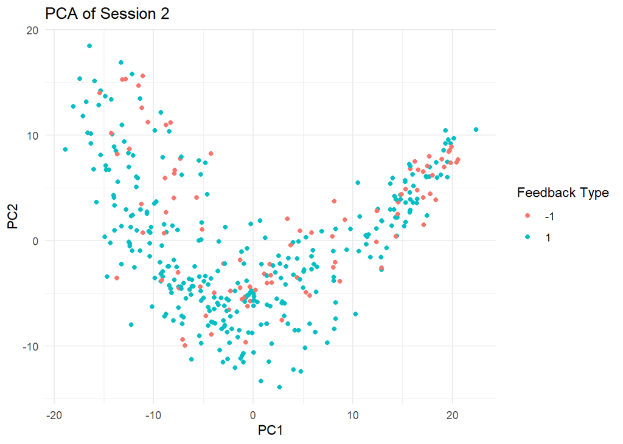

```r
# Visualizing the first two principal components
pca_df <- data.frame(PC1 = pca_result$x[,1], PC2 = pca_result$x[,2], feedback_type = processed_data$feedback_type)
ggplot(pca_df, aes(x = PC1, y = PC2, color = as.factor(feedback_type))) +
  geom_point() +
  labs(title = "PCA of Session 2", x = "PC1", y = "PC2", color = "Feedback Type") +
  theme_minimal()
```

```r
# Determine the number of PCs to explain at least 90% variance
cum_variance <- cumsum(pca_result$sdev^2) / sum(pca_result$sdev^2)
num_pcs <- which(cum_variance >= 0.90)[1]
cat("Number of PCs needed to explain 90% variance:", num_pcs, "\n")
```

```
## Number of PCs needed to explain 90% variance: 314
```

```r
# Extract the selected principal components
selected_pcs <- as.data.frame(pca_result$x[, 1:num_pcs])

# Combine the outcome variable with the selected PCs
pca_final_data <- cbind(feedback_type = processed_data$feedback_type, selected_pcs)

# Save the final PCA dataset
write.csv(pca_final_data, "pca_final_data_session15.csv", row.names = FALSE)

# Print dimensions of the new PCA dataset
print(dim(pca_final_data))
```

```
## [1] 404 315
```

```r
##################################session 16
# Load required libraries
library(ggplot2)

# Load the RDS file for session 16
data <- readRDS("C:/Users/ricky/Desktop/STA141AProject/data/session16.rds")

# Identify unique brain areas in session 16
unique_brain_areas <- unique(data$brain_area)
print(unique_brain_areas)
```

```
## [1] "SSs" "SSp" "MB"  "TH"  "LGd" "CA3"
```

```r
# Function to process session 16 with only its brain areas
process_session <- function(data, window_width = 0.1) {

  # Check if session contains relevant brain areas
  valid_neurons <- which(data$brain_area %in% unique_brain_areas)
  if (length(valid_neurons) == 0) return(NULL)  # Skip if no relevant neurons

  # Extract relevant spike data for valid neurons
  filtered_spikes <- lapply(data$spks, function(trial) trial[valid_neurons, ])

  # Function to compute time-resolved firing rates for one trial
  compute_firing_rates_time_resolved <- function(spike_matrix, time_vector, window_width = 0.1) {
    start_time <- min(time_vector)
    end_time <- max(time_vector)
    bins <- seq(start_time, end_time, by = window_width)
    if (tail(bins, 1) < end_time) {
      bins <- c(bins, end_time)
    }
    firing_rates_windows <- sapply(1:(length(bins) - 1), function(i) {
      window_start <- bins[i]
      window_end <- bins[i+1]
      indices <- which(time_vector >= window_start & time_vector < window_end)
      if (length(indices) == 0) {
        return(rep(0, nrow(spike_matrix)))
      } else {
        return(rowSums(spike_matrix[, indices, drop = FALSE]) / (window_end - window_start))
      }
    })
    return(firing_rates_windows)
  }

  # Apply time-resolved firing rate computation to each trial
  time_resolved_rates <- lapply(1:length(filtered_spikes), function(i) {
    compute_firing_rates_time_resolved(filtered_spikes[[i]], data$time[[i]], window_width)
  })

  # Flatten each trial's matrix (neurons x windows) into a single feature vector
  flattened_rates <- lapply(time_resolved_rates, function(mat) {
    as.vector(mat)
  })

  # Create a data frame for all trials from this session
  trial_df <- do.call(rbind, flattened_rates)

  # Extract feedback_type and ensure it's numeric
  if (!"feedback_type" %in% names(data)) return(NULL)
  feedback <- as.numeric(as.character(data$feedback_type))
  df <- data.frame(feedback_type = feedback)

  # Convert trial data to a data frame and assign column names (e.g., "N1_W1", "N1_W2", ...)
  trial_df <- as.data.frame(trial_df)
  num_neurons <- length(valid_neurons)
  num_windows <- ncol(time_resolved_rates[[1]])  # Assumes all trials have same number of windows
  colnames(trial_df) <- paste0("N", rep(1:num_neurons, each = num_windows),
                               "_W", rep(1:num_windows, times = num_neurons))

  # Merge feedback_type with the time-resolved features
  df <- cbind(df, trial_df)
  return(df)
}

# Process only session 2
processed_data <- process_session(data)

# Remove constant (zero-variance) columns before PCA
remove_constant_columns <- function(df) {
  non_constant_cols <- sapply(df, function(col) length(unique(col)) > 1)
  return(df[, non_constant_cols])
}

processed_data <- remove_constant_columns(processed_data)

# Perform PCA on the dataset (excluding the feedback_type column)
pca_data <- processed_data[, -1]  # Exclude feedback_type
pca_result <- prcomp(pca_data, scale. = TRUE)

# Display PCA summary
summary(pca_result)
```

```
## Importance of components:
##                            PC1     PC2     PC3     PC4     PC5     PC6     PC7
## Standard deviation     6.32287 5.99916 5.38787 4.68157 4.43239 4.22310 4.04317
## Proportion of Variance 0.02272 0.02045 0.01649 0.01245 0.01116 0.01013 0.00929
## Cumulative Proportion  0.02272 0.04316 0.05966 0.07211 0.08327 0.09341 0.10269
##                            PC8     PC9    PC10    PC11    PC12    PC13    PC14
## Standard deviation     3.77902 3.71506 3.66897 3.64307 3.53146 3.51623 3.48129
## Proportion of Variance 0.00811 0.00784 0.00765 0.00754 0.00709 0.00702 0.00689
## Cumulative Proportion  0.11081 0.11865 0.12630 0.13384 0.14093 0.14795 0.15484
##                           PC15   PC16    PC17    PC18    PC19    PC20    PC21
## Standard deviation     3.44158 3.4082 3.39665 3.35293 3.33279 3.32113 3.29829
## Proportion of Variance 0.00673 0.0066 0.00656 0.00639 0.00631 0.00627 0.00618
## Cumulative Proportion  0.16157 0.1682 0.17472 0.18111 0.18742 0.19369 0.19987
##                           PC22    PC23    PC24    PC25    PC26   PC27    PC28
## Standard deviation     3.28572 3.27017 3.26007 3.25615 3.24457 3.2226 3.20146
## Proportion of Variance 0.00613 0.00608 0.00604 0.00602 0.00598 0.0059 0.00582
## Cumulative Proportion  0.20600 0.21208 0.21812 0.22414 0.23012 0.2360 0.24185
##                           PC29    PC30    PC31    PC32    PC33    PC34    PC35
## Standard deviation     3.19235 3.18805 3.17801 3.15705 3.15649 3.12856 3.10672
## Proportion of Variance 0.00579 0.00577 0.00574 0.00566 0.00566 0.00556 0.00548
## Cumulative Proportion  0.24764 0.25341 0.25915 0.26481 0.27048 0.27604 0.28152
##                           PC36    PC37   PC38    PC39    PC40    PC41    PC42
## Standard deviation     3.09643 3.08954 3.0837 3.07912 3.05718 3.04895 3.04040
## Proportion of Variance 0.00545 0.00542 0.0054 0.00539 0.00531 0.00528 0.00525
## Cumulative Proportion  0.28697 0.29239 0.2978 0.30318 0.30849 0.31377 0.31903
##                           PC43   PC44    PC45    PC46    PC47    PC48    PC49
## Standard deviation     3.03358 3.0256 3.01148 3.01015 2.99806 2.97947 2.97247
## Proportion of Variance 0.00523 0.0052 0.00515 0.00515 0.00511 0.00504 0.00502
## Cumulative Proportion  0.32425 0.3295 0.33461 0.33976 0.34486 0.34991 0.35493
##                           PC50    PC51    PC52    PC53    PC54   PC55    PC56
## Standard deviation     2.95912 2.94984 2.93981 2.93460 2.92326 2.9076 2.90325
## Proportion of Variance 0.00498 0.00494 0.00491 0.00489 0.00486 0.0048 0.00479
## Cumulative Proportion  0.35990 0.36485 0.36976 0.37465 0.37951 0.3843 0.38910
##                           PC57    PC58    PC59    PC60    PC61    PC62    PC63
## Standard deviation     2.89975 2.88508 2.88047 2.87797 2.86697 2.86218 2.85257
## Proportion of Variance 0.00478 0.00473 0.00471 0.00471 0.00467 0.00465 0.00462
## Cumulative Proportion  0.39388 0.39861 0.40332 0.40803 0.41270 0.41735 0.42197
##                           PC64    PC65    PC66    PC67    PC68    PC69    PC70
## Standard deviation     2.84162 2.83635 2.83071 2.81870 2.81036 2.80022 2.78688
## Proportion of Variance 0.00459 0.00457 0.00455 0.00451 0.00449 0.00446 0.00441
```

[output cut: 110 more lines]

```
## Standard deviation     1.5699 1.55906 1.54553 1.53971 1.53077 1.51880 1.5128
## Proportion of Variance 0.0014 0.00138 0.00136 0.00135 0.00133 0.00131 0.0013
## Cumulative Proportion  0.9766 0.97799 0.97935 0.98069 0.98203 0.98334 0.9846
##                          PC267   PC268   PC269   PC270   PC271   PC272   PC273
## Standard deviation     1.50694 1.50353 1.48510 1.47876 1.47131 1.46356 1.45818
## Proportion of Variance 0.00129 0.00128 0.00125 0.00124 0.00123 0.00122 0.00121
## Cumulative Proportion  0.98593 0.98721 0.98846 0.98971 0.99094 0.99215 0.99336
##                          PC274   PC275   PC276   PC277   PC278   PC279
## Standard deviation     1.42938 1.41728 1.41145 1.40117 1.37611 1.33451
## Proportion of Variance 0.00116 0.00114 0.00113 0.00112 0.00108 0.00101
## Cumulative Proportion  0.99452 0.99566 0.99680 0.99791 0.99899 1.00000
##                            PC280
## Standard deviation     8.859e-15
## Proportion of Variance 0.000e+00
## Cumulative Proportion  1.000e+00
```

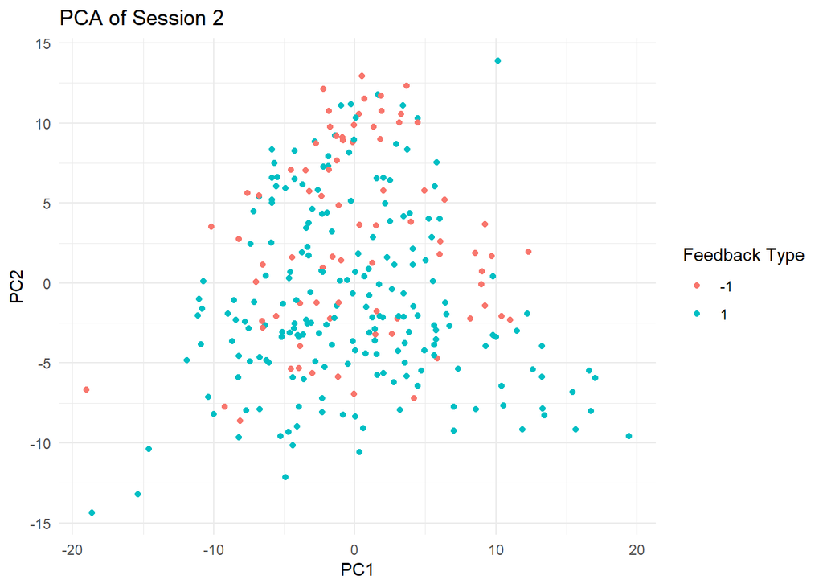

```r
# Visualizing the first two principal components
pca_df <- data.frame(PC1 = pca_result$x[,1], PC2 = pca_result$x[,2], feedback_type = processed_data$feedback_type)
ggplot(pca_df, aes(x = PC1, y = PC2, color = as.factor(feedback_type))) +
  geom_point() +
  labs(title = "PCA of Session 2", x = "PC1", y = "PC2", color = "Feedback Type") +
  theme_minimal()
```

```r
# Determine the number of PCs to explain at least 90% variance
cum_variance <- cumsum(pca_result$sdev^2) / sum(pca_result$sdev^2)
num_pcs <- which(cum_variance >= 0.90)[1]
cat("Number of PCs needed to explain 90% variance:", num_pcs, "\n")
```

```
## Number of PCs needed to explain 90% variance: 216
```

```r
# Extract the selected principal components
selected_pcs <- as.data.frame(pca_result$x[, 1:num_pcs])

# Combine the outcome variable with the selected PCs
pca_final_data <- cbind(feedback_type = processed_data$feedback_type, selected_pcs)

# Save the final PCA dataset
write.csv(pca_final_data, "pca_final_data_session16.csv", row.names = FALSE)

# Print dimensions of the new PCA dataset
print(dim(pca_final_data))
```

```
## [1] 280 217
```

```r
#####################################session 17
# Load required libraries
library(ggplot2)

# Load the RDS file for session 17
data <- readRDS("C:/Users/ricky/Desktop/STA141AProject/data/session9.rds")

# Identify unique brain areas in session 17
unique_brain_areas <- unique(data$brain_area)
print(unique_brain_areas)
```

```
##  [1] "TT"    "ORBm"  "PL"    "LSr"   "root"  "CA3"   "VISl"  "CA1"   "TH"
## [10] "VISam" "VPL"   "LD"
```

```r
# Function to process session 17 with only its brain areas
process_session <- function(data, window_width = 0.1) {

  # Check if session contains relevant brain areas
  valid_neurons <- which(data$brain_area %in% unique_brain_areas)
  if (length(valid_neurons) == 0) return(NULL)  # Skip if no relevant neurons

  # Extract relevant spike data for valid neurons
  filtered_spikes <- lapply(data$spks, function(trial) trial[valid_neurons, ])

  # Function to compute time-resolved firing rates for one trial
  compute_firing_rates_time_resolved <- function(spike_matrix, time_vector, window_width = 0.1) {
    start_time <- min(time_vector)
    end_time <- max(time_vector)
    bins <- seq(start_time, end_time, by = window_width)
    if (tail(bins, 1) < end_time) {
      bins <- c(bins, end_time)
    }
    firing_rates_windows <- sapply(1:(length(bins) - 1), function(i) {
      window_start <- bins[i]
      window_end <- bins[i+1]
      indices <- which(time_vector >= window_start & time_vector < window_end)
      if (length(indices) == 0) {
        return(rep(0, nrow(spike_matrix)))
      } else {
        return(rowSums(spike_matrix[, indices, drop = FALSE]) / (window_end - window_start))
      }
    })
    return(firing_rates_windows)
  }

  # Apply time-resolved firing rate computation to each trial
  time_resolved_rates <- lapply(1:length(filtered_spikes), function(i) {
    compute_firing_rates_time_resolved(filtered_spikes[[i]], data$time[[i]], window_width)
  })

  # Flatten each trial's matrix (neurons x windows) into a single feature vector
  flattened_rates <- lapply(time_resolved_rates, function(mat) {
    as.vector(mat)
  })

  # Create a data frame for all trials from this session
  trial_df <- do.call(rbind, flattened_rates)

  # Extract feedback_type and ensure it's numeric
  if (!"feedback_type" %in% names(data)) return(NULL)
  feedback <- as.numeric(as.character(data$feedback_type))
  df <- data.frame(feedback_type = feedback)

  # Convert trial data to a data frame and assign column names (e.g., "N1_W1", "N1_W2", ...)
  trial_df <- as.data.frame(trial_df)
  num_neurons <- length(valid_neurons)
  num_windows <- ncol(time_resolved_rates[[1]])  # Assumes all trials have same number of windows
  colnames(trial_df) <- paste0("N", rep(1:num_neurons, each = num_windows),
                               "_W", rep(1:num_windows, times = num_neurons))

  # Merge feedback_type with the time-resolved features
  df <- cbind(df, trial_df)
  return(df)
}

# Process only session 2
processed_data <- process_session(data)

# Remove constant (zero-variance) columns before PCA
remove_constant_columns <- function(df) {
  non_constant_cols <- sapply(df, function(col) length(unique(col)) > 1)
  return(df[, non_constant_cols])
}

processed_data <- remove_constant_columns(processed_data)

# Perform PCA on the dataset (excluding the feedback_type column)
pca_data <- processed_data[, -1]  # Exclude feedback_type
pca_result <- prcomp(pca_data, scale. = TRUE)

# Display PCA summary
summary(pca_result)
```

```
## Importance of components:
##                            PC1     PC2     PC3     PC4     PC5     PC6     PC7
## Standard deviation     9.20161 6.64233 5.38953 5.11305 4.82193 4.69408 4.54965
## Proportion of Variance 0.02851 0.01486 0.00978 0.00880 0.00783 0.00742 0.00697
## Cumulative Proportion  0.02851 0.04336 0.05314 0.06195 0.06977 0.07719 0.08416
##                            PC8     PC9    PC10    PC11    PC12    PC13    PC14
## Standard deviation     4.30681 4.28349 4.20952 4.16317 4.14313 4.03778 4.01397
## Proportion of Variance 0.00625 0.00618 0.00597 0.00584 0.00578 0.00549 0.00542
## Cumulative Proportion  0.09041 0.09659 0.10255 0.10839 0.11417 0.11966 0.12508
##                          PC15    PC16    PC17    PC18    PC19    PC20    PC21
## Standard deviation     3.9660 3.95603 3.90064 3.87199 3.83869 3.83073 3.78169
## Proportion of Variance 0.0053 0.00527 0.00512 0.00505 0.00496 0.00494 0.00482
## Cumulative Proportion  0.1304 0.13565 0.14077 0.14582 0.15078 0.15572 0.16054
##                           PC22    PC23    PC24    PC25   PC26    PC27    PC28
## Standard deviation     3.76347 3.74312 3.73026 3.70563 3.6979 3.67312 3.66071
## Proportion of Variance 0.00477 0.00472 0.00469 0.00462 0.0046 0.00454 0.00451
## Cumulative Proportion  0.16531 0.17002 0.17471 0.17933 0.1839 0.18848 0.19299
##                          PC29    PC30    PC31   PC32    PC33    PC34    PC35
## Standard deviation     3.6546 3.63127 3.62220 3.6138 3.59733 3.59318 3.56245
## Proportion of Variance 0.0045 0.00444 0.00442 0.0044 0.00436 0.00435 0.00427
## Cumulative Proportion  0.1975 0.20193 0.20634 0.2107 0.21510 0.21945 0.22372
##                           PC36    PC37    PC38    PC39    PC40    PC41    PC42
## Standard deviation     3.54645 3.53921 3.52092 3.51264 3.50727 3.50023 3.48209
## Proportion of Variance 0.00423 0.00422 0.00417 0.00415 0.00414 0.00413 0.00408
## Cumulative Proportion  0.22795 0.23217 0.23635 0.24050 0.24464 0.24877 0.25285
##                           PC43    PC44    PC45    PC46    PC47    PC48    PC49
## Standard deviation     3.47423 3.46622 3.45330 3.44216 3.43127 3.43060 3.41642
## Proportion of Variance 0.00406 0.00405 0.00402 0.00399 0.00396 0.00396 0.00393
## Cumulative Proportion  0.25691 0.26096 0.26497 0.26896 0.27293 0.27689 0.28082
##                          PC50    PC51    PC52    PC53    PC54    PC55   PC56
## Standard deviation     3.4018 3.39282 3.39214 3.37876 3.37672 3.36727 3.3604
## Proportion of Variance 0.0039 0.00388 0.00387 0.00384 0.00384 0.00382 0.0038
## Cumulative Proportion  0.2847 0.28859 0.29247 0.29631 0.30015 0.30397 0.3078
##                           PC57    PC58    PC59    PC60   PC61    PC62    PC63
## Standard deviation     3.35482 3.33855 3.33717 3.33043 3.3149 3.30627 3.30129
## Proportion of Variance 0.00379 0.00375 0.00375 0.00373 0.0037 0.00368 0.00367
## Cumulative Proportion  0.31156 0.31531 0.31906 0.32280 0.3265 0.33018 0.33385
##                           PC64    PC65    PC66    PC67   PC68    PC69    PC70
## Standard deviation     3.29044 3.28140 3.27727 3.27378 3.2676 3.25380 3.25005
## Proportion of Variance 0.00365 0.00363 0.00362 0.00361 0.0036 0.00356 0.00356
```

[output cut: 162 more lines]

```
## Standard deviation     1.84192 1.83382 1.82952 1.82764 1.81816 1.8046 1.80044
## Proportion of Variance 0.00114 0.00113 0.00113 0.00112 0.00111 0.0011 0.00109
## Cumulative Proportion  0.97914 0.98027 0.98140 0.98252 0.98363 0.9847 0.98582
##                          PC358   PC359   PC360   PC361   PC362   PC363   PC364
## Standard deviation     1.79660 1.79504 1.77799 1.76738 1.76030 1.75457 1.74197
## Proportion of Variance 0.00109 0.00108 0.00106 0.00105 0.00104 0.00104 0.00102
## Cumulative Proportion  0.98691 0.98799 0.98906 0.99011 0.99115 0.99219 0.99321
##                          PC365  PC366   PC367   PC368   PC369   PC370   PC371
## Standard deviation     1.73085 1.7217 1.70981 1.69399 1.67850 1.67519 1.66815
## Proportion of Variance 0.00101 0.0010 0.00098 0.00097 0.00095 0.00094 0.00094
## Cumulative Proportion  0.99422 0.9952 0.99620 0.99717 0.99812 0.99906 1.00000
##                            PC372
## Standard deviation     1.447e-14
## Proportion of Variance 0.000e+00
## Cumulative Proportion  1.000e+00
```

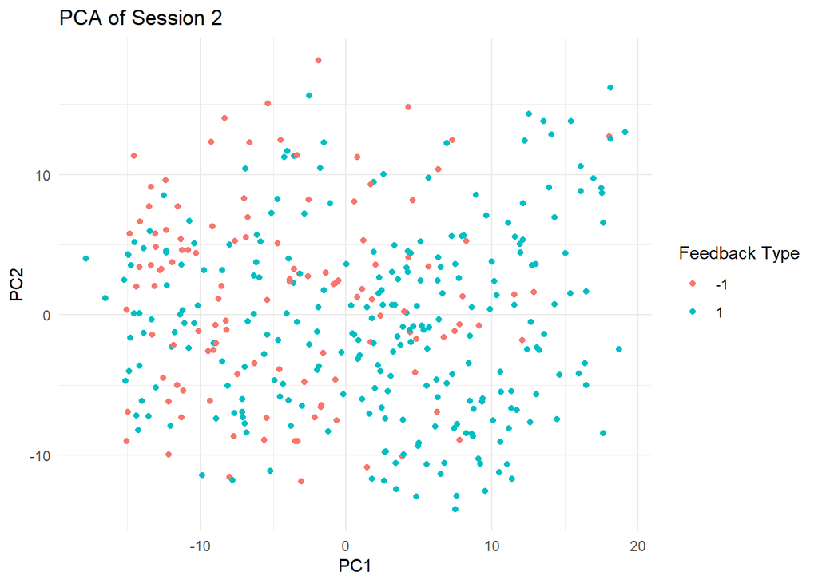

```r
# Visualizing the first two principal components
pca_df <- data.frame(PC1 = pca_result$x[,1], PC2 = pca_result$x[,2], feedback_type = processed_data$feedback_type)
ggplot(pca_df, aes(x = PC1, y = PC2, color = as.factor(feedback_type))) +
  geom_point() +
  labs(title = "PCA of Session 2", x = "PC1", y = "PC2", color = "Feedback Type") +
  theme_minimal()
```

```r
# Determine the number of PCs to explain at least 90% variance
cum_variance <- cumsum(pca_result$sdev^2) / sum(pca_result$sdev^2)
num_pcs <- which(cum_variance >= 0.90)[1]
cat("Number of PCs needed to explain 90% variance:", num_pcs, "\n")
```

```
## Number of PCs needed to explain 90% variance: 293
```

```r
# Extract the selected principal components
selected_pcs <- as.data.frame(pca_result$x[, 1:num_pcs])

# Combine the outcome variable with the selected PCs
pca_final_data <- cbind(feedback_type = processed_data$feedback_type, selected_pcs)

# Save the final PCA dataset
write.csv(pca_final_data, "pca_final_data_session17.csv", row.names = FALSE)

# Print dimensions of the new PCA dataset
print(dim(pca_final_data))
```

[output not shown]

```r
###################################session 18
# Load required libraries
library(ggplot2)

# Load the RDS file for session 18
data <- readRDS("C:/Users/ricky/Desktop/STA141AProject/data/session18.rds")

# Identify unique brain areas in session 18
unique_brain_areas <- unique(data$brain_area)
print(unique_brain_areas)
```

```
##  [1] "CP"   "ACB"  "OT"   "SI"   "SNr"  "LGd"  "ZI"   "CA3"  "root" "TH"
```

```r
# Function to process session 18 with only its brain areas
process_session <- function(data, window_width = 0.1) {

  # Check if session contains relevant brain areas
  valid_neurons <- which(data$brain_area %in% unique_brain_areas)
  if (length(valid_neurons) == 0) return(NULL)  # Skip if no relevant neurons

  # Extract relevant spike data for valid neurons
  filtered_spikes <- lapply(data$spks, function(trial) trial[valid_neurons, ])

  # Function to compute time-resolved firing rates for one trial
  compute_firing_rates_time_resolved <- function(spike_matrix, time_vector, window_width = 0.1) {
    start_time <- min(time_vector)
    end_time <- max(time_vector)
    bins <- seq(start_time, end_time, by = window_width)
    if (tail(bins, 1) < end_time) {
      bins <- c(bins, end_time)
    }
    firing_rates_windows <- sapply(1:(length(bins) - 1), function(i) {
      window_start <- bins[i]
      window_end <- bins[i+1]
      indices <- which(time_vector >= window_start & time_vector < window_end)
      if (length(indices) == 0) {
        return(rep(0, nrow(spike_matrix)))
      } else {
        return(rowSums(spike_matrix[, indices, drop = FALSE]) / (window_end - window_start))
      }
    })
    return(firing_rates_windows)
  }

  # Apply time-resolved firing rate computation to each trial
  time_resolved_rates <- lapply(1:length(filtered_spikes), function(i) {
    compute_firing_rates_time_resolved(filtered_spikes[[i]], data$time[[i]], window_width)
  })

  # Flatten each trial's matrix (neurons x windows) into a single feature vector
  flattened_rates <- lapply(time_resolved_rates, function(mat) {
    as.vector(mat)
  })

  # Create a data frame for all trials from this session
  trial_df <- do.call(rbind, flattened_rates)

  # Extract feedback_type and ensure it's numeric
  if (!"feedback_type" %in% names(data)) return(NULL)
  feedback <- as.numeric(as.character(data$feedback_type))
  df <- data.frame(feedback_type = feedback)

  # Convert trial data to a data frame and assign column names (e.g., "N1_W1", "N1_W2", ...)
  trial_df <- as.data.frame(trial_df)
  num_neurons <- length(valid_neurons)
  num_windows <- ncol(time_resolved_rates[[1]])  # Assumes all trials have same number of windows
  colnames(trial_df) <- paste0("N", rep(1:num_neurons, each = num_windows),
                               "_W", rep(1:num_windows, times = num_neurons))

  # Merge feedback_type with the time-resolved features
  df <- cbind(df, trial_df)
  return(df)
}

# Process only session 18
processed_data <- process_session(data)

# Remove constant (zero-variance) columns before PCA
remove_constant_columns <- function(df) {
  non_constant_cols <- sapply(df, function(col) length(unique(col)) > 1)
  return(df[, non_constant_cols])
}

processed_data <- remove_constant_columns(processed_data)

# Perform PCA on the dataset (excluding the feedback_type column)
pca_data <- processed_data[, -1]  # Exclude feedback_type
pca_result <- prcomp(pca_data, scale. = TRUE)

# Display PCA summary
summary(pca_result)
```

```
## Importance of components:
##                             PC1     PC2     PC3     PC4     PC5     PC6     PC7
## Standard deviation     10.63839 8.52588 8.13436 7.60810 7.46432 6.79414 6.78715
## Proportion of Variance  0.02887 0.01854 0.01688 0.01477 0.01421 0.01178 0.01175
## Cumulative Proportion   0.02887 0.04741 0.06429 0.07906 0.09327 0.10505 0.11680
##                            PC8     PC9    PC10    PC11    PC12    PC13    PC14
## Standard deviation     6.53415 6.37845 6.25727 6.14875 5.99377 5.94265 5.89711
## Proportion of Variance 0.01089 0.01038 0.00999 0.00964 0.00916 0.00901 0.00887
## Cumulative Proportion  0.12769 0.13807 0.14806 0.15770 0.16687 0.17588 0.18475
##                           PC15    PC16    PC17    PC18    PC19    PC20    PC21
## Standard deviation     5.81722 5.59429 5.53337 5.45450 5.36957 5.34021 5.29399
## Proportion of Variance 0.00863 0.00798 0.00781 0.00759 0.00736 0.00727 0.00715
## Cumulative Proportion  0.19338 0.20137 0.20918 0.21677 0.22412 0.23140 0.23855
##                           PC22    PC23    PC24    PC25    PC26    PC27    PC28
## Standard deviation     5.26948 5.25374 5.14922 5.14015 5.10522 5.05618 5.04277
## Proportion of Variance 0.00708 0.00704 0.00676 0.00674 0.00665 0.00652 0.00649
## Cumulative Proportion  0.24563 0.25267 0.25943 0.26617 0.27282 0.27934 0.28583
##                           PC29    PC30    PC31    PC32    PC33    PC34    PC35
## Standard deviation     4.99193 4.98720 4.93938 4.91960 4.90014 4.88783 4.87851
## Proportion of Variance 0.00636 0.00634 0.00622 0.00617 0.00613 0.00609 0.00607
## Cumulative Proportion  0.29219 0.29853 0.30476 0.31093 0.31706 0.32315 0.32922
##                           PC36    PC37    PC38   PC39    PC40    PC41    PC42
## Standard deviation     4.83971 4.81883 4.80047 4.7682 4.75708 4.73243 4.70034
## Proportion of Variance 0.00598 0.00592 0.00588 0.0058 0.00577 0.00571 0.00564
## Cumulative Proportion  0.33520 0.34112 0.34700 0.3528 0.35857 0.36429 0.36992
##                           PC43    PC44    PC45    PC46    PC47    PC48    PC49
## Standard deviation     4.68854 4.67876 4.65921 4.63858 4.62455 4.61340 4.58703
## Proportion of Variance 0.00561 0.00558 0.00554 0.00549 0.00546 0.00543 0.00537
## Cumulative Proportion  0.37553 0.38111 0.38665 0.39214 0.39760 0.40303 0.40839
##                           PC50    PC51    PC52    PC53    PC54    PC55   PC56
## Standard deviation     4.58384 4.57808 4.57088 4.54825 4.52139 4.51722 4.5141
## Proportion of Variance 0.00536 0.00535 0.00533 0.00528 0.00522 0.00521 0.0052
## Cumulative Proportion  0.41375 0.41910 0.42443 0.42971 0.43492 0.44013 0.4453
##                           PC57    PC58    PC59    PC60    PC61    PC62    PC63
## Standard deviation     4.49315 4.48659 4.45916 4.45325 4.43001 4.41800 4.40091
## Proportion of Variance 0.00515 0.00514 0.00507 0.00506 0.00501 0.00498 0.00494
## Cumulative Proportion  0.45048 0.45561 0.46068 0.46574 0.47075 0.47573 0.48067
##                           PC64   PC65    PC66    PC67    PC68    PC69    PC70
## Standard deviation     4.38874 4.3813 4.37397 4.37074 4.35341 4.34579 4.32623
## Proportion of Variance 0.00491 0.0049 0.00488 0.00487 0.00483 0.00482 0.00477
```

[output cut: 70 more lines]

```
## Standard deviation     3.16115 3.14947 3.14405 3.13667 3.11052 3.10611 3.09630
## Proportion of Variance 0.00255 0.00253 0.00252 0.00251 0.00247 0.00246 0.00245
## Cumulative Proportion  0.94409 0.94662 0.94914 0.95165 0.95412 0.95658 0.95902
##                          PC197  PC198   PC199   PC200   PC201   PC202   PC203
## Standard deviation     3.07242 3.0647 3.05381 3.05214 3.03292 3.01757 3.01139
## Proportion of Variance 0.00241 0.0024 0.00238 0.00238 0.00235 0.00232 0.00231
## Cumulative Proportion  0.96143 0.9638 0.96621 0.96858 0.97093 0.97325 0.97557
##                          PC204   PC205   PC206   PC207   PC208   PC209   PC210
## Standard deviation     3.00600 2.96752 2.95807 2.94424 2.92306 2.88295 2.85482
## Proportion of Variance 0.00231 0.00225 0.00223 0.00221 0.00218 0.00212 0.00208
## Cumulative Proportion  0.97787 0.98012 0.98235 0.98456 0.98674 0.98886 0.99094
##                          PC211 PC212   PC213   PC214   PC215     PC216
## Standard deviation     2.80467 2.800 2.62816 2.55876 2.52006 2.018e-14
## Proportion of Variance 0.00201 0.002 0.00176 0.00167 0.00162 0.000e+00
## Cumulative Proportion  0.99295 0.995 0.99671 0.99838 1.00000 1.000e+00
```

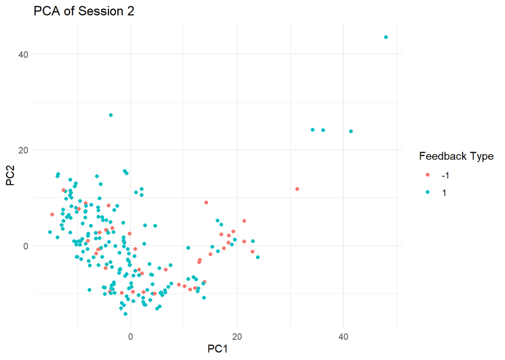

```r
# Visualizing the first two principal components
pca_df <- data.frame(PC1 = pca_result$x[,1], PC2 = pca_result$x[,2], feedback_type = processed_data$feedback_type)
ggplot(pca_df, aes(x = PC1, y = PC2, color = as.factor(feedback_type))) +
  geom_point() +
  labs(title = "PCA of Session 2", x = "PC1", y = "PC2", color = "Feedback Type") +
  theme_minimal()
```

```r
# Determine the number of PCs to explain at least 90% variance
cum_variance <- cumsum(pca_result$sdev^2) / sum(pca_result$sdev^2)
num_pcs <- which(cum_variance >= 0.90)[1]
cat("Number of PCs needed to explain 90% variance:", num_pcs, "\n")
```

```
## Number of PCs needed to explain 90% variance: 174
```

```r
# Extract the selected principal components
selected_pcs <- as.data.frame(pca_result$x[, 1:num_pcs])

# Combine the outcome variable with the selected PCs
pca_final_data <- cbind(feedback_type = processed_data$feedback_type, selected_pcs)

# Save the final PCA dataset
write.csv(pca_final_data, "pca_final_data_session18.csv", row.names = FALSE)

# Print dimensions of the new PCA dataset
print(dim(pca_final_data))
```

```
## [1] 216 175
```

[figure not shown]

```r
# Visualizing PCA components
library(ggplot2)
ggplot(pca_df, aes(x = PC1, y = PC2, color = as.factor(feedback_type))) +
  geom_point() +
  labs(title = "PCA of Session 1", x = "PC1", y = "PC2", color = "Feedback Type") +
  theme_minimal()
```

# **Exploratory Analysis 2**

**Introduction 2** In this section, we conduct further exploratory data analysis by processing **neural activity from each session, computing** time-resolved firing rates**, and applying** Principal Component Analysis (PCA)**. The goal is to transform high-dimensional neural spike data into a lower-dimensional space that captures the most relevant patterns while preserving key information.

**1 Processing Neural Spike Data** First, we load the **session 1 dataset** and extract: - **Unique brain areas** in the session. - **Spike activity from neurons** that belong to these brain areas. - **Time-resolved firing rates**, computed by binning spike activity into windows of **0.1 seconds**.

**Steps Taken** - Identified **valid neurons** belonging to recorded brain areas. - Extracted their **spiking activity across trials**. - Computed **firing rates per time window** for each neuron. - Flattened the **firing rates matrix** to create a feature set for each trial. - Extracted the **feedback_type** variable to use as the target variable.

**2 Principal Component Analysis (PCA)** After cleaning the data, we applied **PCA** to reduce the high-dimensional neural data while preserving variance. We took 90% of the variation of the PCA data from each session. Since we need a dataset with the same number of PCAs, we took the maximum amount of PCAs that could be extracted from the smallest session and we took 92PCAs from each session.

**Key PCA Steps** 1. Standardized the data for **mean = 0** and **unit variance**. 2. Computed **principal components**, which are linear combinations of the original features. 3. Examined **explained variance** to determine how many PCs capture most of the information. 4. Took 92 PCAs from session 1-18.

**3 Visualizing PCA Results** To understand the data in lower dimensions: - We plotted the **first two principal components (PC1 vs. PC2)**. - Points are colored based on **feedback type (rewarded vs. non-rewarded trials)**.

[output not shown]

```
##  num [1:114] 1 1 -1 -1 -1 1 1 1 1 1 ...
## [1] "Session 1 processed and saved as pca_final_data_session1.csv"
## [1] 114  93
##  num [1:251, 1] -1 1 -1 1 -1 1 1 1 -1 1 ...
## [1] "Session 2 processed and saved as pca_final_data_session2.csv"
## [1] 251  93
##  num [1:228, 1] 1 1 1 1 1 1 1 1 1 1 ...
## [1] "Session 3 processed and saved as pca_final_data_session3.csv"
## [1] 228  93
##  num [1:249, 1] 1 1 -1 1 1 -1 -1 1 1 1 ...
## [1] "Session 4 processed and saved as pca_final_data_session4.csv"
## [1] 249  93
##  num [1:254, 1] 1 1 -1 -1 1 1 1 1 1 1 ...
## [1] "Session 5 processed and saved as pca_final_data_session5.csv"
## [1] 254  93
##  num [1:290, 1] 1 1 1 1 -1 1 1 1 1 1 ...
## [1] "Session 6 processed and saved as pca_final_data_session6.csv"
## [1] 290  93
##  num [1:252, 1] 1 -1 -1 1 -1 1 -1 1 -1 1 ...
## [1] "Session 7 processed and saved as pca_final_data_session7.csv"
## [1] 252  93
##  num [1:250, 1] 1 -1 1 1 -1 1 1 1 -1 -1 ...
## [1] "Session 8 processed and saved as pca_final_data_session8.csv"
## [1] 250  93
##  num [1:372, 1] 1 1 1 1 1 1 1 1 -1 1 ...
## [1] "Session 9 processed and saved as pca_final_data_session9.csv"
## [1] 372  93
##  num [1:447, 1] -1 -1 -1 -1 -1 1 -1 -1 1 -1 ...
## [1] "Session 10 processed and saved as pca_final_data_session10.csv"
## [1] 447  93
##  num [1:342, 1] 1 -1 1 1 1 1 1 1 1 1 ...
## [1] "Session 11 processed and saved as pca_final_data_session11.csv"
## [1] 342  93
##  num [1:340, 1] 1 -1 1 1 1 1 1 1 1 1 ...
## [1] "Session 12 processed and saved as pca_final_data_session12.csv"
## [1] 340  93
##  num [1:300, 1] -1 1 1 1 1 1 1 1 1 1 ...
## [1] "Session 13 processed and saved as pca_final_data_session13.csv"
## [1] 300  93
##  num [1:268, 1] 1 1 1 -1 1 1 1 1 1 1 ...
## [1] "Session 14 processed and saved as pca_final_data_session14.csv"
## [1] 268  93
##  num [1:404, 1] 1 -1 1 -1 1 1 -1 1 1 1 ...
## [1] "Session 15 processed and saved as pca_final_data_session15.csv"
## [1] 404  93
##  num [1:280, 1] 1 1 -1 1 -1 1 1 1 1 -1 ...
## [1] "Session 16 processed and saved as pca_final_data_session16.csv"
## [1] 280  93
##  num [1:224, 1] -1 1 1 -1 1 1 1 1 1 1 ...
## [1] "Session 17 processed and saved as pca_final_data_session17.csv"
## [1] 224  93
##  num [1:216] 1 1 -1 -1 1 1 1 1 1 1 ...
## [1] "Session 18 processed and saved as pca_final_data_session18.csv"
## [1] 216  93
```

# **Exploratory Analysis 3: Process of combining the 18 sessions into one**

**Overview** This section details the process of **combining the 18 sessions into one**

**1 Neural Data Preprocessing** **Loading Data** - We load neural spike data recorded from different brain regions for each session. - **Brain region labels** for neurons. - **Spike train data** for trials. - **Behavioral feedback information (rewarded vs. non-rewarded trials).**

**Processing Sessions** - The function `process_session()` is used to process each session by: - Identifying **unique brain areas** in the session. - Filtering out neurons belonging to these brain areas. - Extracting **spiking activity** for the selected neurons. - Computing **time-resolved firing rates**, by binning spike activity into **0.1-second windows**.

**2️ Feature Engineering: Time-Resolved Firing Rates** **Steps Taken** - For each trial: - Neural spiking activity is converted into **firing rates** over **predefined time bins**. - These rates are computed for **all neurons across all trials**. - The **firing rate matrix** is then flattened into a single **feature vector** per trial.

**3 Applying PCA** - **Principal Component Analysis (PCA)** is used to **reduce dimensionality** while preserving important neural activity patterns. - **92 principal components (PCs)** are extracted per session.

**4️ Saving the Processed Data** - The processed PCA data, along with **feedback type**, is saved as: - `"pca_final_data_sessionX.csv"`, where **X** represents each session number.

##Data intergration method

Justification for using Time-Resolved Firing Rate

**Why We Used Time-Resolved Firing Rates Instead of Trial-Averaged Firing Rates**

** Problem with Trial-Averaged Firing Rates **In my previous coding, firing rates were computed for each neuron by: -** Summing all spikes over the entire trial**. -** Dividing by the total trial duration**.

**Issues with This Approach** - **Loses temporal information**: Decision-making and feedback processing occur at **specific time points**, not uniformly throughout the trial. - **Cannot capture dynamic neural patterns**: Some neurons **increase or decrease activity** at key moments, and trial-averaged rates ignore these fluctuations. - **Ignores sequence effects**: The **timing of neural spikes** matters, but trial-averaged rates do not capture the **order of neural events**.

### ** Why We Used Time-Resolved Firing Rates**

To **preserve temporal information**, we applied the following method: 1. **Divided each trial into predefined time bins** (e.g., 100ms windows). 2. **Computed the firing rate in each time bin** instead of averaging across the entire trial. 3. **Flattened the firing rate matrix** into a **single feature vector per trial**.

```r
knitr::opts_chunk$set(error = TRUE, warning = FALSE, message = FALSE)

############################################## combining all the 92 PCs

#checking my file path
file_path <- normalizePath("pca_final_data_session1.csv", mustWork = FALSE)

# Load required library
library(dplyr)

# Define the directory where PCA session files are stored
pca_data_dir <- "C:/Users/ricky/Documents/"

# Generate the list of PCA output files (sessions 1 to 18)
session_files <- paste0(pca_data_dir, "pca_final_data_session", 1:18, ".csv")

# Read all PCA datasets into a list
pca_datasets <- lapply(session_files, read.csv)

# Merge all PCA datasets
merged_pca_data <- bind_rows(pca_datasets)

# Save the merged dataset
write.csv(merged_pca_data, "pca_merged_data.csv", row.names = FALSE)
```

# **Data Intergration 1: Process of combining the 18 sessions into one**

This section merges **Principal Component Analysis (PCA) outputs** from all **18 experimental sessions** into a single dataset for predictive modeling.

**Create a list of PCA output file paths for sessions** 1 to 18**

**Read and Merge PCA Datasets:**

**Save the Final Dataset:**  
- Write the merged PCA data into `"pca_merged_data.csv"` for further analysis.

```r
knitr::opts_chunk$set(error = TRUE, warning = FALSE, message = FALSE)
# Load necessary library
library(dplyr)

# Read the dataset
pca_data <- read.csv("pca_merged_data.csv")

# Check the first few rows

summary(pca_data)
```

```
##  feedback_type          PC1               PC2                  PC3
##  Min.   :-1.0000   Min.   :-57.477   Min.   :-102.92209   Min.   :-110.29957
##  1st Qu.:-1.0000   1st Qu.: -7.195   1st Qu.:  -5.22550   1st Qu.:  -3.91500
##  Median : 1.0000   Median : -0.922   Median :   0.07373   Median :  -0.05047
##  Mean   : 0.4202   Mean   :  0.000   Mean   :   0.00000   Mean   :   0.00000
##  3rd Qu.: 1.0000   3rd Qu.:  6.726   3rd Qu.:   5.44044   3rd Qu.:   3.90625
##  Max.   : 1.0000   Max.   : 65.544   Max.   :  43.51705   Max.   :  97.04229
##       PC4                PC5                 PC6                 PC7
##  Min.   :-75.5556   Min.   :-41.23092   Min.   :-84.18018   Min.   :-78.80860
##  1st Qu.: -3.5165   1st Qu.: -3.05148   1st Qu.: -2.80368   1st Qu.: -2.46183
##  Median :  0.2623   Median :  0.08671   Median : -0.05301   Median : -0.02005
##  Mean   :  0.0000   Mean   :  0.00000   Mean   :  0.00000   Mean   :  0.00000
##  3rd Qu.:  3.5360   3rd Qu.:  3.10806   3rd Qu.:  2.57071   3rd Qu.:  2.46701
##  Max.   : 69.5995   Max.   : 76.95337   Max.   : 81.58691   Max.   : 57.04690
##       PC8                PC9                 PC10                PC11
##  Min.   :-71.5396   Min.   :-69.96503   Min.   :-64.34687   Min.   :-68.23973
##  1st Qu.: -2.4929   1st Qu.: -2.28542   1st Qu.: -2.18436   1st Qu.: -2.17631
##  Median : -0.1188   Median :  0.04868   Median :  0.00071   Median :  0.05556
##  Mean   :  0.0000   Mean   :  0.00000   Mean   :  0.00000   Mean   :  0.00000
##  3rd Qu.:  2.4484   3rd Qu.:  2.19263   3rd Qu.:  2.12756   3rd Qu.:  2.20813
##  Max.   : 88.1188   Max.   : 44.67569   Max.   : 65.10623   Max.   : 44.01444
##       PC12               PC13                PC14                PC15
##  Min.   :-56.5249   Min.   :-73.62208   Min.   :-79.61977   Min.   :-37.25519
##  1st Qu.: -1.9525   1st Qu.: -2.07863   1st Qu.: -2.01620   1st Qu.: -1.92359
##  Median : -0.0043   Median : -0.00328   Median : -0.01596   Median : -0.01748
##  Mean   :  0.0000   Mean   :  0.00000   Mean   :  0.00000   Mean   :  0.00000
##  3rd Qu.:  2.0633   3rd Qu.:  2.16165   3rd Qu.:  1.94955   3rd Qu.:  1.90550
##  Max.   : 51.1552   Max.   : 49.78411   Max.   : 52.99548   Max.   : 62.48637
##       PC16                PC17                PC18
##  Min.   :-69.94728   Min.   :-36.48077   Min.   :-44.37150
##  1st Qu.: -1.98758   1st Qu.: -2.12173   1st Qu.: -1.96248
##  Median :  0.06852   Median : -0.03983   Median : -0.05937
##  Mean   :  0.00000   Mean   :  0.00000   Mean   :  0.00000
##  3rd Qu.:  2.00020   3rd Qu.:  2.18662   3rd Qu.:  2.01373
##  Max.   : 43.64987   Max.   : 46.85471   Max.   : 49.92118
##       PC19                PC20                PC21
##  Min.   :-33.73369   Min.   :-42.31477   Min.   :-32.88978
##  1st Qu.: -2.05151   1st Qu.: -2.03532   1st Qu.: -2.04384
##  Median : -0.03694   Median :  0.01115   Median : -0.01965
##  Mean   :  0.00000   Mean   :  0.00000   Mean   :  0.00000
```

[output cut: 141 more lines]

```
##  Max.   : 19.12175   Max.   : 17.726856   Max.   : 23.88738
##       PC86                PC87               PC88                PC89
##  Min.   :-16.46976   Min.   :-17.2569   Min.   :-16.22285   Min.   :-14.97988
##  1st Qu.: -2.00108   1st Qu.: -2.0652   1st Qu.: -2.01868   1st Qu.: -2.13244
##  Median : -0.04228   Median : -0.0538   Median :  0.01923   Median : -0.03052
##  Mean   :  0.00000   Mean   :  0.0000   Mean   :  0.00000   Mean   :  0.00000
##  3rd Qu.:  2.04384   3rd Qu.:  2.0777   3rd Qu.:  2.08939   3rd Qu.:  2.07822
##  Max.   : 18.39882   Max.   : 24.0869   Max.   : 18.56195   Max.   : 17.27144
##       PC90                PC91                PC92
##  Min.   :-17.19740   Min.   :-19.80227   Min.   :-18.09667
##  1st Qu.: -2.01585   1st Qu.: -2.05097   1st Qu.: -2.04363
##  Median : -0.02341   Median : -0.01733   Median : -0.05522
##  Mean   :  0.00000   Mean   :  0.00000   Mean   :  0.00000
##  3rd Qu.:  2.07655   3rd Qu.:  2.05284   3rd Qu.:  1.97720
##  Max.   : 17.93140   Max.   : 19.54688   Max.   : 17.55252
```

```r
# Load a single session file (adjust the path)
data <- readRDS("C:/Users/ricky/Desktop/STA141AProject/data/session1.rds")

# Count occurrences of 0s and 1s
table(data$feedback_type)
```

```
##
## -1  1
## 45 69
```

```r
##############################################standardizing PC and taking 30 instead
# Load required library
library(dplyr)
library(caret)  # For standardization

# Load the merged PCA dataset
pca_data_path <- "C:/Users/ricky/Documents/pca_merged_data.csv"
pca_data <- read.csv(pca_data_path)

# Exclude feedback_type (Outcome Variable) and standardize only the PCs
pc_features <- pca_data[, -1]  # Remove feedback_type column

# Standardizing using caret's preProcess function
preProc <- preProcess(pc_features, method = c("center", "scale"))
standardized_pcs <- predict(preProc, pc_features)

# Re-attach feedback_type
standardized_pca_data <- cbind(feedback_type = pca_data$feedback_type, standardized_pcs)

# Save the standardized PCA dataset
write.csv(standardized_pca_data, "pca_standardized_data.csv", row.names = FALSE)

# Load standardized PCA data
pca_standardized <- read.csv("pca_standardized_data.csv")

# Select only the first 30 PCs (plus feedback_type)
top_30_pcs <- cbind(feedback_type = pca_standardized$feedback_type, pca_standardized[, 2:31])

# Save the dataset with only top 30 PCs
write.csv(top_30_pcs, "pca_top30_data.csv", row.names = FALSE)

# Print message
print("Top 30 PCA components saved as pca_top30_data.csv")
```

```
## [1] "Top 30 PCA components saved as pca_top30_data.csv"
```

```r
################################check if PCs are ok
# Load necessary library
library(readr)

# Read the dataset
pca_top30_data <- read_csv("pca_top30_data.csv")

summary(pca_top30_data)
```

```
##  feedback_type          PC1                PC2                  PC3
##  Min.   :-1.0000   Min.   :-5.62380   Min.   :-13.067783   Min.   :-15.795866
##  1st Qu.:-1.0000   1st Qu.:-0.70397   1st Qu.: -0.663470   1st Qu.: -0.560663
##  Median : 1.0000   Median :-0.09021   Median :  0.009361   Median : -0.007228
##  Mean   : 0.4202   Mean   : 0.00000   Mean   :  0.000000   Mean   :  0.000000
##  3rd Qu.: 1.0000   3rd Qu.: 0.65813   3rd Qu.:  0.690761   3rd Qu.:  0.559409
##  Max.   : 1.0000   Max.   : 6.41307   Max.   :  5.525260   Max.   : 13.897307
##       PC4                 PC5                PC6
##  Min.   :-11.93816   Min.   :-6.93746   Min.   :-14.844461
##  1st Qu.: -0.55562   1st Qu.:-0.51344   1st Qu.: -0.494406
##  Median :  0.04144   Median : 0.01459   Median : -0.009348
##  Mean   :  0.00000   Mean   : 0.00000   Mean   :  0.000000
##  3rd Qu.:  0.55870   3rd Qu.: 0.52296   3rd Qu.:  0.453323
##  Max.   : 10.99707   Max.   :12.94807   Max.   : 14.387160
##       PC7                  PC8                 PC9
##  Min.   :-14.425910   Min.   :-13.51264   Min.   :-13.519569
##  1st Qu.: -0.450639   1st Qu.: -0.47087   1st Qu.: -0.441619
##  Median : -0.003671   Median : -0.02245   Median :  0.009407
##  Mean   :  0.000000   Mean   :  0.00000   Mean   :  0.000000
##  3rd Qu.:  0.451586   3rd Qu.:  0.46246   3rd Qu.:  0.423690
##  Max.   : 10.442432   Max.   : 16.64417   Max.   :  8.632827
##       PC10                PC11                PC12
##  Min.   :-12.68693   Min.   :-13.69361   Min.   :-11.520228
##  1st Qu.: -0.43068   1st Qu.: -0.43672   1st Qu.: -0.397942
##  Median :  0.00014   Median :  0.01115   Median : -0.000877
##  Mean   :  0.00000   Mean   :  0.00000   Mean   :  0.000000
##  3rd Qu.:  0.41948   3rd Qu.:  0.44310   3rd Qu.:  0.420527
##  Max.   : 12.83665   Max.   :  8.83234   Max.   : 10.425835
##       PC13                 PC14                 PC15
##  Min.   :-15.178431   Min.   :-16.604915   Min.   :-7.86322
##  1st Qu.: -0.428545   1st Qu.: -0.420485   1st Qu.:-0.40600
##  Median : -0.000677   Median : -0.003328   Median :-0.00369
##  Mean   :  0.000000   Mean   :  0.000000   Mean   : 0.00000
##  3rd Qu.:  0.445660   3rd Qu.:  0.406584   3rd Qu.: 0.40218
##  Max.   : 10.263833   Max.   : 11.052349   Max.   :13.18860
##       PC16                PC17                PC18               PC19
##  Min.   :-14.94079   Min.   :-7.870384   Min.   :-9.67644   Min.   :-7.421361
##  1st Qu.: -0.42455   1st Qu.:-0.457743   1st Qu.:-0.42797   1st Qu.:-0.451328
##  Median :  0.01464   Median :-0.008593   Median :-0.01295   Median :-0.008126
##  Mean   :  0.00000   Mean   : 0.000000   Mean   : 0.00000   Mean   : 0.000000
```

[output cut: 8 more lines]

```
##  Max.   : 8.162867   Max.   : 8.555025   Max.   : 9.7402   Max.   : 9.132276
##       PC24                PC25              PC26               PC27
##  Min.   :-10.80105   Min.   :-8.1174   Min.   :-9.83306   Min.   :-8.7213
##  1st Qu.: -0.47058   1st Qu.:-0.4626   1st Qu.:-0.45674   1st Qu.:-0.4818
##  Median : -0.01552   Median : 0.0028   Median : 0.01416   Median : 0.0106
##  Mean   :  0.00000   Mean   : 0.0000   Mean   : 0.00000   Mean   : 0.0000
##  3rd Qu.:  0.45044   3rd Qu.: 0.4760   3rd Qu.: 0.47622   3rd Qu.: 0.4968
##  Max.   :  9.99290   Max.   :12.3964   Max.   : 7.74727   Max.   :10.4036
##       PC28                PC29               PC30
##  Min.   :-8.403746   Min.   :-8.47851   Min.   :-7.09227
##  1st Qu.:-0.469361   1st Qu.:-0.48124   1st Qu.:-0.48509
##  Median :-0.000029   Median : 0.01606   Median :-0.01716
##  Mean   : 0.000000   Mean   : 0.00000   Mean   : 0.00000
##  3rd Qu.: 0.468452   3rd Qu.: 0.48328   3rd Qu.: 0.47405
##  Max.   : 7.607615   Max.   : 7.05335   Max.   : 7.74631
```